# Cell cycle dynamics of synthetic mRNA-induced β-cell proliferation

- Show All Code
- Hide All Code
- View Source

Statistical report

**Authors and affiliations**

Katerina Bittenglova<sup>1,2</sup>, Klara Zacharovova<sup>3</sup>, Filip Tichanek<sup>4</sup>, Ivan Leontovyc<sup>3</sup>, Peter Girman<sup>1</sup>, Jan Kriz<sup>1,2</sup>, Frantisek Saudek<sup>1,2,3</sup>, and Tomas Koblas<sup>2,3,5,6,7,*</sup>

<sup>1</sup> Department of Diabetes, Institute for Clinical and Experimental Medicine, Prague, Czech Republic  
<sup>2</sup> First Faculty of Medicine, Charles University, Prague, Czech Republic  
<sup>3</sup> Laboratory of Pancreatic Islets, Center of Experimental Medicine, Institute for Clinical and Experimental Medicine, Prague, Czech Republic  
<sup>4</sup> Department of Data Science, Institute for Clinical and Experimental Medicine, Prague, Czech Republic  
<sup>5</sup> Department of Biochemistry, Faculty of Science, Charles University, Prague, Czech Republic  
<sup>6</sup> Lead contact  
<sup>7</sup> Senior author  
* Correspondence: tomas.koblas@ikem.cz

This is a statistical report, code and data for the manuscript titled *Cell cycle dynamics of synthetic mRNA-induced β-cell proliferation* (currently in preparation / under review).

When using this data, code or statistical report, please cite the manuscript and the archived Zenodo version of this repository (update once published):

Original [GitHub repository](https://github.com/filip-tichanek/beta_cells/): https://github.com/filip-tichanek/beta_cells

Statistical **report** can be found [here](https://filip-tichanek.github.io/beta_cells/)

**Archived version**

The manuscript-submission version of this repository is archived on [Zenodo](https://doi.org/10.5281/zenodo.22095339) (Concept DOI: https://doi.org/10.5281/zenodo.22095339)

**General analytical workflow**

For each analyzed beta cell population, the analysis follows this workflow:

1. **Exploratory data analysis:** First, the raw data are visualized across individual experiments to identify general temporal trends and visually assess variance stability (heteroscedasticity).
2. **Model selection:** Candidate models fitted via Maximum Likelihood (ML) are compared using AIC and BIC criteria. Simple linear models without random effects are included purely for baseline comparison; a mixed-effects framework with a random intercept for the experiment is required by design to account for within-experiment dependency.
3. **Diagnostics:** Simulated residuals (via the DHARMa package) are evaluated to check distributional assumptions. This step focuses specifically on comparing mixed-effects models with a global residual variance versus models allowing for group-specific residual variance.
4. **Final model fit:** Based on the information criteria and residual diagnostics, the final mixed-effects model is selected for statistical inference.
5. **Statistical inference:** Overall effects of experimental group (time point or untreated control, where applicable) were assessed using Wald chi-square omnibus tests (`car::Anova`). Pairwise comparisons of estimated marginal means were performed using the `emmeans` package. All pairwise P-values and confidence intervals were adjusted using the Bonferroni correction.
6. **Visualization:** The final results are plotted as means ± standard errors of the mean (SEM), with significance indicators for specified pairwise comparisons shown where applicable.
7. **Summary statistics:** Finally, a table with raw descriptive statistics (mean, median, SD, and SEM) is provided for each time point/control group.

*Note: You must click on **“Open code”** in the HTML report to expand the given code chunks and view the underlying R scripts.*

# 1 Initiation

Upload initiation file

**Open code**

```r
setwd(path)
source('r/initiation.R')
```

Graphical setting

**Open code**

```r
ax_text1 <- 13.4
tit_text1 <- 14.1
mar1 <- 0
mar1b <- -4.5
mar1b2 <- -0.5
mar1b3 <- -6.5
mar1c <- 10
mar1d <- 2

## text size plot type 2
ax_text2 <- 12.5
tit_text2 <- 14
mar2 <- 0

## text size plot type 3
ax_text3 <- 13.8
tit_text3 <- 14.3
mar3 <- 8

## text size plot type 4
ax_text4 <- 13.4
tit_text4 <- 14.1
mar4 <- 0
leg_text4 <- 13.8

## others
mar_add <- 13.4

figh1 <- 3.490; figw1 <- 3.550 # cell type 1 -- main plots
figh2 <- 4.492; figw2 <- 3.172 # cell type 2 -- occupation plot
figh3 <- 3.788; figw3 <- 5.189 # cell type 3 -- wide plots
figh4 <- 4.322; figw4 <- 3.372 # cell type 4 -- last and long (width) cell occupation plot
#figw4b <- 4.011 # cell type 4.5 -- long cell occupation plot
figh5 <- 3.896; figw5 <- 3.978 # cell type 5 --  RO plots
```

## 1.1 Explore data

**Open code**

```r
summary(data)
##      Time             expA_04_10      expB_03_27      expC_02_21
##  Length:204         Min.   : 0.00   Min.   : 0.00   Min.   : 0.00
##  Class :character   1st Qu.: 2.49   1st Qu.: 1.76   1st Qu.: 2.62
##  Mode  :character   Median :13.85   Median :11.82   Median :15.31
##                     Mean   :23.16   Mean   :23.81   Mean   :24.10
##                     3rd Qu.:35.22   3rd Qu.:35.02   3rd Qu.:33.38
##                     Max.   :98.96   Max.   :99.79   Max.   :99.75
##                     NA's   :19      NA's   :65      NA's   :80
##    expD_03_11      expE_06_18       expF_06_26      expG_10_25
##  Min.   : 0.00   Min.   : 0.000   Min.   : 0.00   Min.   : 0.00
##  1st Qu.: 4.57   1st Qu.: 1.885   1st Qu.: 2.34   1st Qu.: 1.89
##  Median :16.47   Median :15.840   Median :13.88   Median :13.25
##  Mean   :21.75   Mean   :23.222   Mean   :22.32   Mean   :22.86
##  3rd Qu.:30.78   3rd Qu.:34.002   3rd Qu.:36.99   3rd Qu.:32.61
##  Max.   :99.61   Max.   :99.330   Max.   :99.91   Max.   :98.67
##  NA's   :43      NA's   :4                        NA's   :31
##       expH          Graph              Graph2          Name.of.population
##  Min.   : 0.64   Length:204         Length:204         Length:204
##  1st Qu.: 4.49   Class :character   Class :character   Class :character
##  Median :21.02   Mode  :character   Mode  :character   Mode  :character
##  Mean   :20.51
##  3rd Qu.:32.67
##  Max.   :50.95
##  NA's   :188
summary(data_long)
##        Time        Graph              Graph2          Name.of.population
##  18 hours:136   Length:1632        Length:1632        Length:1632
##  20 hours:136   Class :character   Class :character   Class :character
##  12 hours:120   Mode  :character   Mode  :character   Mode  :character
##  14 hours: 96
##  24 hours: 80
##  26 hours: 72
##  (Other) :992
##       Experiment    Proportion
##  expA_04_10:204   Min.   : 0.00
##  expB_03_27:204   1st Qu.: 2.34
##  expC_02_21:204   Median :14.59
##  expD_03_11:204   Mean   :22.93
##  expE_06_18:204   3rd Qu.:33.28
##  expF_06_26:204   Max.   :99.91
##  (Other)   :408   NA's   :430
##                                                  Table
##  2ND_S_CYCLE_FC_X_Cell_cycle_occupation4_X_2ND S    :  96
##  DIVIDED_CYCLE_FC_X_Cell_cycle_occupation4_X_DIVIDED:  96
##  G0G1_CYCLE_FC_X_Cell_cycle_occupation4_X_G0G1 EdU- :  96
##  G2M_CYCLE_FC_X_Cell_cycle_occupation4_X_G2M EdU+   :  96
##  S_CYCLE_FC_X_Cell_cycle_occupation4_X_S EdU+       :  96
##  Cell_cycle_occupation _X_NA_X_G0 pRB               :  48
##  (Other)                                            :1104
```

# 2 Functions

## 2.1 Add stars as indicator of statisticla significance to the plot

**Open code**

```r
add_starm <- function(x1, x2, y, star, scal = 1) {
  base_height <- y - (1.5 / scal)
  base_stary <- y
  byh <- 2.5 / scal
  byh2 <- 1.5 / scal

  signif <- data.frame(
    x1 = c(
      x1, x1, mean(x2), min(x2)
    ),
    x2 = c(
      mean(x2), x1, mean(x2), max(x2)
    ),
    y1 = c(
      base_height, base_height, base_height, base_height - byh
    ),
    y2 = c(
      base_height, base_height - byh, base_height - byh, base_height - byh
    )
  )

  stars <- data.frame(
    sig = star,
    x = mean(c(x1, mean(x2))),
    y = base_stary
  )

  p <-  p +
    geom_segment(
      data = signif,
      aes(x = x1, xend = x2, y = y1, yend = y2),
      linewidth = 0.12
    ) +
    geom_text(
      data = dplyr::filter(stars, sig != "<sup>n.s.</sup>"),
      mapping = aes(x, y - byh2, label = sig),
      size = 7.7
    ) +
    ggtext::geom_richtext(
      data = dplyr::filter(stars, sig == "<sup>n.s.</sup>"),
      mapping = aes(x, y, label = sig),
      fill = NA,
      label.colour = NA,
      label.size = 0,
      size = 4.8
    )

  return(p)
}
```

## 2.2 Create a contrast table

**Open code**

```r
con_tab <- function(model, caption_text) {
  em <- emmeans::emmeans(
    model,
    ~ Time
  )

  contrast_raw <- pairs(
    em
  )

  contrast_ci <- summary(
    contrast_raw,
    adjust = "bonferroni",
    infer = c(TRUE, TRUE)
  )

  contrast <- contrast_ci %>%
    dplyr::as_tibble() %>%
    dplyr::mutate(
      CI = sprintf(
        "[%.2f, %.2f]",
        lower.CL,
        upper.CL
      ),
      stars = dplyr::case_when(
        p.value < 0.001 ~ "***",
        p.value < 0.01 ~ "**",
        p.value < 0.05 ~ "*",
        .default = "ns"
      )
    ) %>%
    dplyr::mutate(
      dplyr::across(
        c(estimate, SE, df, t.ratio),
        ~ round(.x, 2)
      )
    ) %>%
    dplyr::select(
      contrast,
      estimate,
      CI,
      SE,
      df,
      t.ratio,
      p.value,
      stars
    )
  return(contrast)
}
```

# 3 G1 phase FC

## 3.1 Show Data

**Open code**

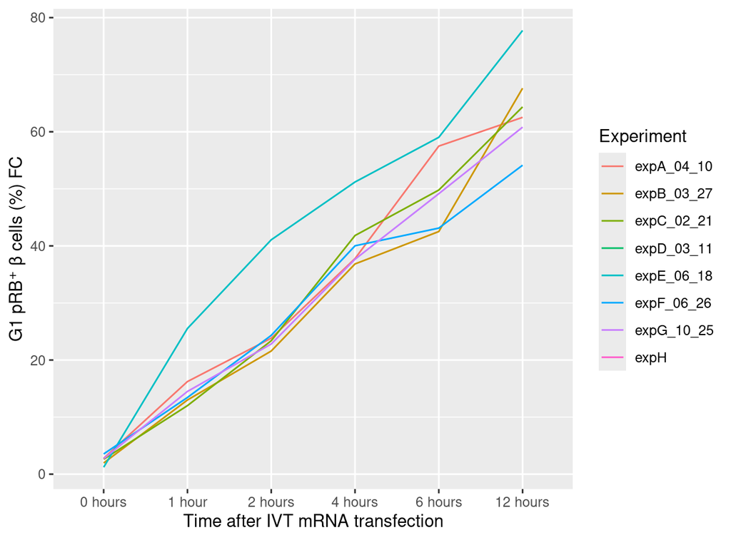

Mean proportion of G1-phase pRB⁺ β cells (% by flow cytometry) at different time points after IVT mRNA transfection and across individual experiment

```r
data_long %>% filter(grepl('G1_phase_FC', Table)) %>%
  ggplot(
    aes(x = Time, y = Proportion, group = Experiment, color = Experiment)
    ) +
  geom_line() +
  scale_y_continuous(
    name = "G1 pRB⁺ β cells (%) FC"
  ) +
  scale_x_discrete(name = "Time after IVT mRNA transfection")
## Warning: Removed 12 rows containing missing values or values outside the scale range
## (`geom_line()`).
```

## 3.2 Models

### 3.2.1 Choose model

Model comparison using AIC/BIC. Note that models without random effects are included purely for comparison. They are not meant to be used as final models, since we want to include a random effect by design to account for within-experiment dependency. The same applies to all other beta cell populations.

**Open code**

```r
model_NR <- glmmTMB::glmmTMB(
  Proportion ~ Time,
  data = data_long %>%
    filter(grepl('G1_phase_FC', Table)) %>%
    na.omit() %>%
    mutate(Time = factor(Time)),
  REML = FALSE
)

model_RI <- glmmTMB::glmmTMB(
  Proportion ~ Time + (1 | Experiment),
  data = data_long %>%
    filter(grepl('G1_phase_FC', Table)) %>%
    na.omit() %>%
    mutate(Time = factor(Time)),
  REML = FALSE
)

model_NR_difvar <- glmmTMB::glmmTMB(
  Proportion ~ Time,
  data = data_long %>%
    filter(grepl('G1_phase_FC', Table)) %>%
    na.omit() %>%
    mutate(Time = factor(Time)),
  REML = FALSE,
  dispformula = ~ 0 + Time
)

model_RI_difvar <- glmmTMB::glmmTMB(
  Proportion ~ Time + (1 | Experiment),
  data = data_long %>%
    filter(grepl('G1_phase_FC', Table)) %>%
    na.omit() %>%
    mutate(Time = factor(Time)),
  REML = FALSE,
  dispformula = ~  Time
)

kableExtra::kable(AIC(model_NR, model_RI, model_NR_difvar, model_RI_difvar))
```

|  | df | AIC |
| --- | --- | --- |
| model_NR | 7 | 239.0911 |
| model_RI | 8 | 225.8246 |
| model_NR_difvar | 12 | 228.2736 |
| model_RI_difvar | 13 | 230.2736 |

**Open code**

```r
kableExtra::kable(BIC(model_NR, model_RI, model_NR_difvar, model_RI_difvar))
```

|  | df | BIC |
| --- | --- | --- |
| model_NR | 7 | 250.1758 |
| model_RI | 8 | 238.4927 |
| model_NR_difvar | 12 | 247.2759 |
| model_RI_difvar | 13 | 250.8594 |

Diagnostics

**Open code**

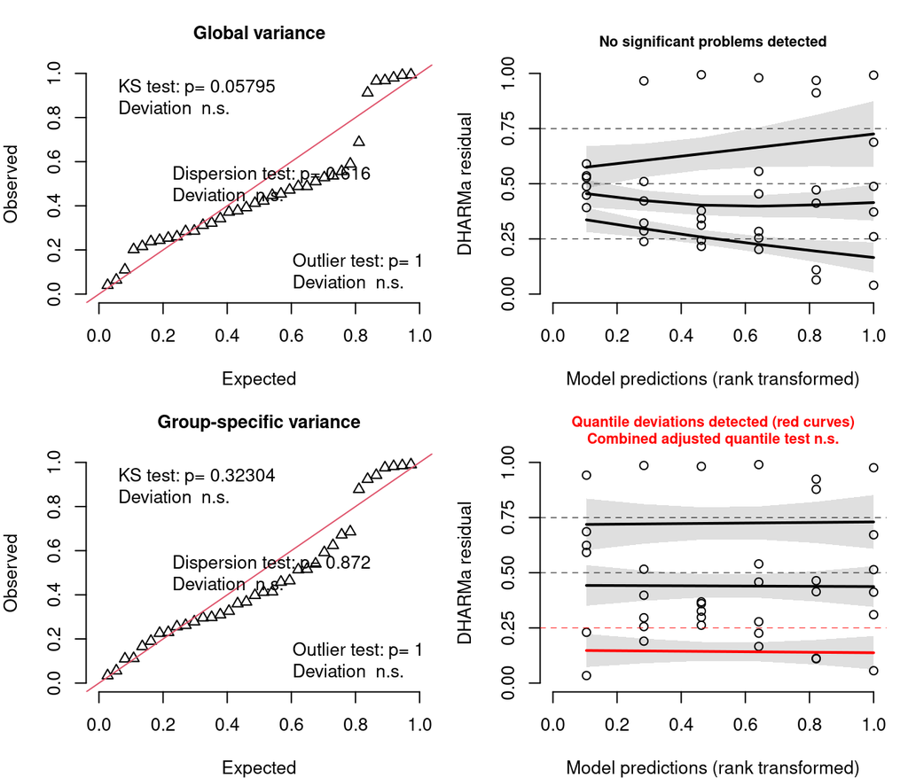

Diagnostic plots from DHARMa simulated residuals for models with and without group-specific residual variance. Top: random-intercept model with a single (global) residual variance. Bottom: random-intercept model allowing group-specific residual variance. Left: quantile–quantile plot comparing simulated residuals to the expected distribution. Right: residuals plotted against predicted values; black lines show the median (0.5) and lower/upper quartiles (0.25, 0.75) with shaded 95% simulation envelopes. Deviations from expected values suggest potential model misspecification

```r
set.seed(709)
res1 <- simulateResiduals(model_RI, n = 500)
res2 <- simulateResiduals(model_RI_difvar, n = 500)

op <- par(mfrow = c(2, 2), mar = c(4, 4, 3, 1))

plotQQunif(res1, main = "Global variance")
plotResiduals(res1, main = "")

plotQQunif(res2, main = "Group-specific variance")
plotResiduals(res2, main = "")
```

**Open code**

```r
par(op)
```

$\Rightarrow$ The random-intercept model without allowance group-specific variance provided the best fit according to both AIC and BIC and was therefore retained.

### 3.2.2 Fit final model

**Open code**

```r
model_final <- glmmTMB::glmmTMB(
  Proportion ~ Time + (1 | Experiment),
  data = data_long %>%
    filter(grepl("G1_phase_FC", Table)) %>%
    na.omit(),
  REML = TRUE
)
```

### 3.2.3 Results

**Open code**

```r
kableExtra::kable(car::Anova(model_final))
```

|  | Chisq | Df | Pr(>Chisq) |
| --- | --- | --- | --- |
| Time | 932.4451 | 5 | 0 |

**Open code**

```r
summary(model_final)
##  Family: gaussian  ( identity )
## Formula:          Proportion ~ Time + (1 | Experiment)
## Data: data_long %>% filter(grepl("G1_phase_FC", Table)) %>% na.omit()
##
##      AIC      BIC   logLik deviance df.resid
##    207.1    219.7    -95.5    191.1       34
##
## Random effects:
##
## Conditional model:
##  Groups     Name        Variance Std.Dev.
##  Experiment (Intercept) 19.59    4.426
##  Residual               16.90    4.111
## Number of obs: 36, groups:  Experiment, 6
##
## Dispersion estimate for gaussian family (sigma^2): 16.9
##
## Conditional model:
##              Estimate Std. Error z value Pr(>|z|)
## (Intercept)     2.473      2.466   1.003    0.316
## Time1 hour     13.312      2.373   5.609 2.04e-08 ***
## Time2 hours    23.692      2.373   9.982  < 2e-16 ***
## Time4 hours    38.413      2.373  16.185  < 2e-16 ***
## Time6 hours    47.710      2.373  20.102  < 2e-16 ***
## Time12 hours   62.063      2.373  26.149  < 2e-16 ***
## ---
## Signif. codes:  0 '***' 0.001 '**' 0.01 '*' 0.05 '.' 0.1 ' ' 1

contrast <- con_tab(model_final)

kableExtra::kable(
  contrast,
  caption = "Estimated pairwise differences in the proportion of G1-phase pRB⁺ β cells (%; flow cytometry), obtained from a linear mixed-effects model with experiment as a random intercept and time as a categorical predictor. Columns: `contrast` (time points compared), `estimate` (mean difference in %), `CI` (Bonferroni-adjusted 95% confidence interval [lower, upper]), `SE` (standard error), `df` (degrees of freedom), `t.ratio` (test statistic), `p.value` (Bonferroni-adjusted p-value), and `stars` (significance code)."
)
```

Estimated pairwise differences in the proportion of G1-phase pRB⁺ β cells (%; flow cytometry), obtained from a linear mixed-effects model with experiment as a random intercept and time as a categorical predictor. Columns: `contrast` (time points compared), `estimate` (mean difference in %), `CI` (Bonferroni-adjusted 95% confidence interval [lower, upper]), `SE` (standard error), `df` (degrees of freedom), `t.ratio` (test statistic), `p.value` (Bonferroni-adjusted p-value), and `stars` (significance code).

| contrast | estimate | CI | SE | df | t.ratio | p.value | stars |
| --- | --- | --- | --- | --- | --- | --- | --- |
| 0 hours - 1 hour | -13.31 | [-20.80, -5.82] | 2.37 | 34 | -5.61 | 0.0000417 | *** |
| 0 hours - 2 hours | -23.69 | [-31.18, -16.20] | 2.37 | 34 | -9.98 | 0.0000000 | *** |
| 0 hours - 4 hours | -38.41 | [-45.91, -30.92] | 2.37 | 34 | -16.18 | 0.0000000 | *** |
| 0 hours - 6 hours | -47.71 | [-55.20, -40.22] | 2.37 | 34 | -20.10 | 0.0000000 | *** |
| 0 hours - 12 hours | -62.06 | [-69.56, -54.57] | 2.37 | 34 | -26.15 | 0.0000000 | *** |
| 1 hour - 2 hours | -10.38 | [-17.87, -2.89] | 2.37 | 34 | -4.37 | 0.0016457 | ** |
| 1 hour - 4 hours | -25.10 | [-32.59, -17.61] | 2.37 | 34 | -10.58 | 0.0000000 | *** |
| 1 hour - 6 hours | -34.40 | [-41.89, -26.91] | 2.37 | 34 | -14.49 | 0.0000000 | *** |
| 1 hour - 12 hours | -48.75 | [-56.24, -41.26] | 2.37 | 34 | -20.54 | 0.0000000 | *** |
| 2 hours - 4 hours | -14.72 | [-22.21, -7.23] | 2.37 | 34 | -6.20 | 0.0000071 | *** |
| 2 hours - 6 hours | -24.02 | [-31.51, -16.53] | 2.37 | 34 | -10.12 | 0.0000000 | *** |
| 2 hours - 12 hours | -38.37 | [-45.86, -30.88] | 2.37 | 34 | -16.17 | 0.0000000 | *** |
| 4 hours - 6 hours | -9.30 | [-16.79, -1.80] | 2.37 | 34 | -3.92 | 0.0061581 | ** |
| 4 hours - 12 hours | -23.65 | [-31.14, -16.16] | 2.37 | 34 | -9.96 | 0.0000000 | *** |
| 6 hours - 12 hours | -14.35 | [-21.85, -6.86] | 2.37 | 34 | -6.05 | 0.0000112 | *** |

### 3.2.4 Visualisation

**Open code**

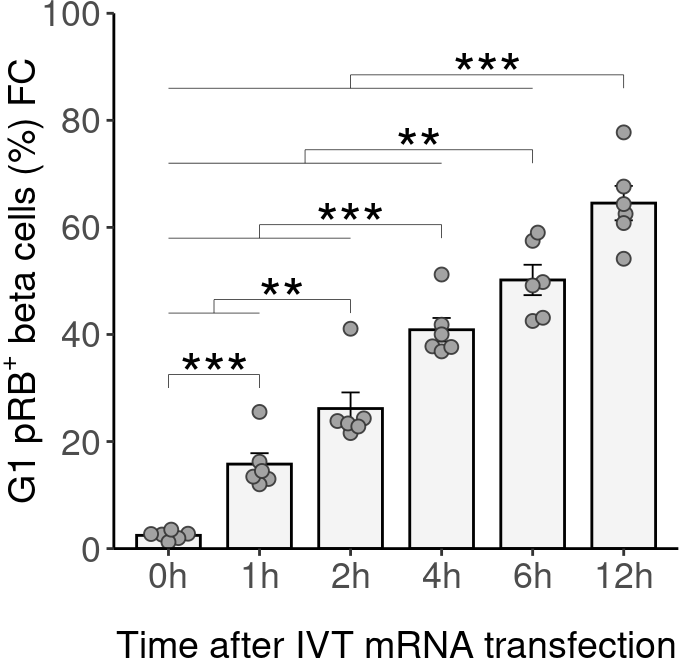

Proportion of G1-phase pRB⁺ beta cells (% by flow cytometry) at different time points after IVT mRNA transfection. Bars show means ± SEM. ***, P < 0.001; **, P < 0.01; *, P < 0.05(adjusted P-values by Bonferroni correction). Statistical significance was assessed with linear mixed-effects model, including experiment as a random effect and time as a categorical predictor

```r
p <- data_long %>%
  filter(grepl("G1_phase_FC", Table)) %>%
  na.omit() %>%
  mutate(
    Time = factor(Time,
                  levels = unique(Time),
                  labels = gsub(" hour[s]?", "h", gsub("Control", "Ctrl", unique(Time)))
                  )
    ) %>%
  ggplot(
    aes(x = Time, y = Proportion)
  ) +
  stat_summary(
    fun = "mean",
    geom = "col",
    fill = 'grey80', color = 'black',
    width = 0.7,
    alpha = 0.2
  ) +
  stat_summary(fun.data = mean_se, geom = "errorbar",
               width = 0.2, linewidth = 0.324) +
  scale_y_continuous(
    breaks = seq(0, 100, 20),
    name = expression("G1 pRB"^"+"~"beta cells (%) FC"),
    expand = expansion(mult = c(0, 0), add = c(0, 0))
  ) +
  coord_cartesian(ylim = c(0, 100)) +
  scale_x_discrete(name = "Time after IVT mRNA transfection",
    labels = function(x) gsub("Ctrl (.*)", "Ctrl\n\\1", x)) +
  geom_beeswarm(
    cex = 2,
    fill = 'grey64',
    size = 2.13,
    shape = 21,
    color = rgb(0.2, 0.2, 0.2, 0.9),
    stroke = 0.5
  ) +
  theme_classic() +
  theme(
    plot.margin = margin(t = 5, r = 1, b = 1, l = 1),
    axis.text.x = element_text(size = ax_text1),
    axis.text.y = element_text(size = ax_text1),
    axis.title.x = element_text(size = tit_text1, margin = margin(t = mar1 + mar_add)),
    axis.title.y = element_text(size = tit_text1, margin = margin(r = mar1b))
  )

tr <- 0
byp <- 14
start <- 90

p <- add_starm(6, c(1:5), start - tr, '***'); tr <-  tr + byp
p <- add_starm(5, c(1:4), start - tr, '**'); tr <-  tr + byp
p <- add_starm(4, c(1:3), start - tr, '***'); tr <-  tr + byp
p <- add_starm(3, c(1:2), start - tr, '**'); tr <-  tr + byp
p <- add_starm(1, 2, start - tr, '***'); tr <-  tr + byp

p
```

**Open code**

```r
if (!file.exists("gitignore/figures/fig_01.pdf")) {
  ggsave("gitignore/figures/fig_01.pdf",
         plot = p, width = figw1, height = figh1, units = "in")
  }
```

### 3.2.5 Summary statistics over timpoints

**Open code**

```r
kableExtra::kable(
  data_long %>%
    dplyr::filter(grepl("G1_phase_FC", Table)) %>%
    tidyr::drop_na(Proportion) %>%
    dplyr::group_by(Time) %>%
    dplyr::summarise(
      mean = mean(Proportion),
      median = quantile(Proportion, probs = 0.5),
      SD = sd(Proportion),
      SEM = sem(Proportion)
    ),
  caption = "Summary statistics for the proportion of G1-phase pRB⁺ beta cells (% by flow cytometry) at different time points after IVT mRNA transfection. Mean, median, SD, and SEM are shown; SD, standard deviation; SEM, standard error of the mean"
)
```

Summary statistics for the proportion of G1-phase pRB⁺ beta cells (% by flow cytometry) at different time points after IVT mRNA transfection. Mean, median, SD, and SEM are shown; SD, standard deviation; SEM, standard error of the mean

| Time | mean | median | SD | SEM |
| --- | --- | --- | --- | --- |
| 0 hours | 2.473333 | 2.670 | 0.7935406 | 0.3239616 |
| 1 hour | 15.785000 | 13.970 | 4.9863845 | 2.0356829 |
| 2 hours | 26.165000 | 23.605 | 7.3627407 | 3.0058263 |
| 4 hours | 40.886667 | 38.900 | 5.3744829 | 2.1941235 |
| 6 hours | 50.183333 | 49.470 | 6.9496868 | 2.8371978 |
| 12 hours | 64.536667 | 63.445 | 7.8765162 | 3.2155743 |

# 4 G1 phase IF

## 4.1 Show Data

**Open code**

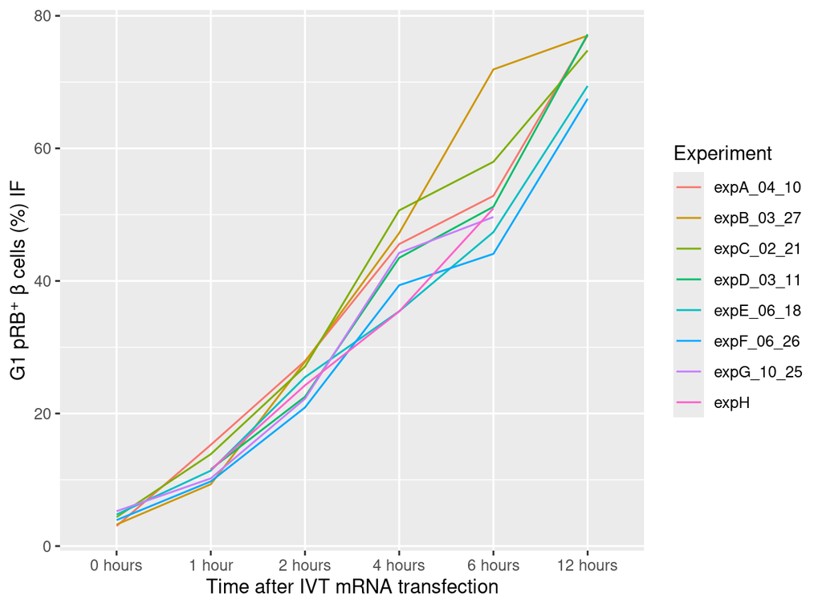

Mean proportion of G1-phase pRB⁺ β cells (% by immunofluorescence) at different time points after IVT mRNA transfection and across individual experiments

```r
data_long %>% filter(grepl('G1_phase_IF', Table)) %>%
  ggplot(
    aes(x = Time, y = Proportion, group = Experiment, color = Experiment)
    ) +
  geom_line() +
  scale_y_continuous(
    name = "G1 pRB⁺ β cells (%) IF"
  ) +
  scale_x_discrete(name = "Time after IVT mRNA transfection")
## Warning: Removed 4 rows containing missing values or values outside the scale range
## (`geom_line()`).
```

$\Rightarrow$ variances seem unstable

## 4.2 Models

### 4.2.1 Choose model

AIC/BIC

**Open code**

```r
model_NR <- glmmTMB::glmmTMB(
  Proportion ~ Time,
  data = data_long %>%
    filter(
      grepl('G1_phase_IF', Table),
      !is.na(Proportion)
    ),
  REML = FALSE
)

model_RI <- glmmTMB::glmmTMB(
  Proportion ~ Time + (1 | Experiment),
  data = data_long %>%
    filter(
      grepl('G1_phase_IF', Table),
      !is.na(Proportion)
    ),
  REML = FALSE
)

model_NR_difvar <- glmmTMB::glmmTMB(
  Proportion ~ Time,
  data = data_long %>%
    filter(
      grepl('G1_phase_IF', Table),
      !is.na(Proportion)
    ),
  REML = FALSE,
  dispformula = ~ 0 + Time
)

model_RI_difvar <- glmmTMB::glmmTMB(
  Proportion ~ Time + (1 | Experiment),
  data = data_long %>%
    filter(
      grepl('G1_phase_IF', Table),
      !is.na(Proportion)
    ),
  REML = FALSE,
  dispformula = ~ 0 + Time
)

kableExtra::kable(AIC(model_NR, model_RI, model_NR_difvar, model_RI_difvar))
```

|  | df | AIC |
| --- | --- | --- |
| model_NR | 7 | 271.7277 |
| model_RI | 8 | 267.9883 |
| model_NR_difvar | 12 | 247.2551 |
| model_RI_difvar | 13 | 249.2551 |

**Open code**

```r
kableExtra::kable(BIC(model_NR, model_RI, model_NR_difvar, model_RI_difvar))
```

|  | df | BIC |
| --- | --- | --- |
| model_NR | 7 | 284.2171 |
| model_RI | 8 | 282.2619 |
| model_NR_difvar | 12 | 268.6654 |
| model_RI_difvar | 13 | 272.4496 |

Diagnostics

**Open code**

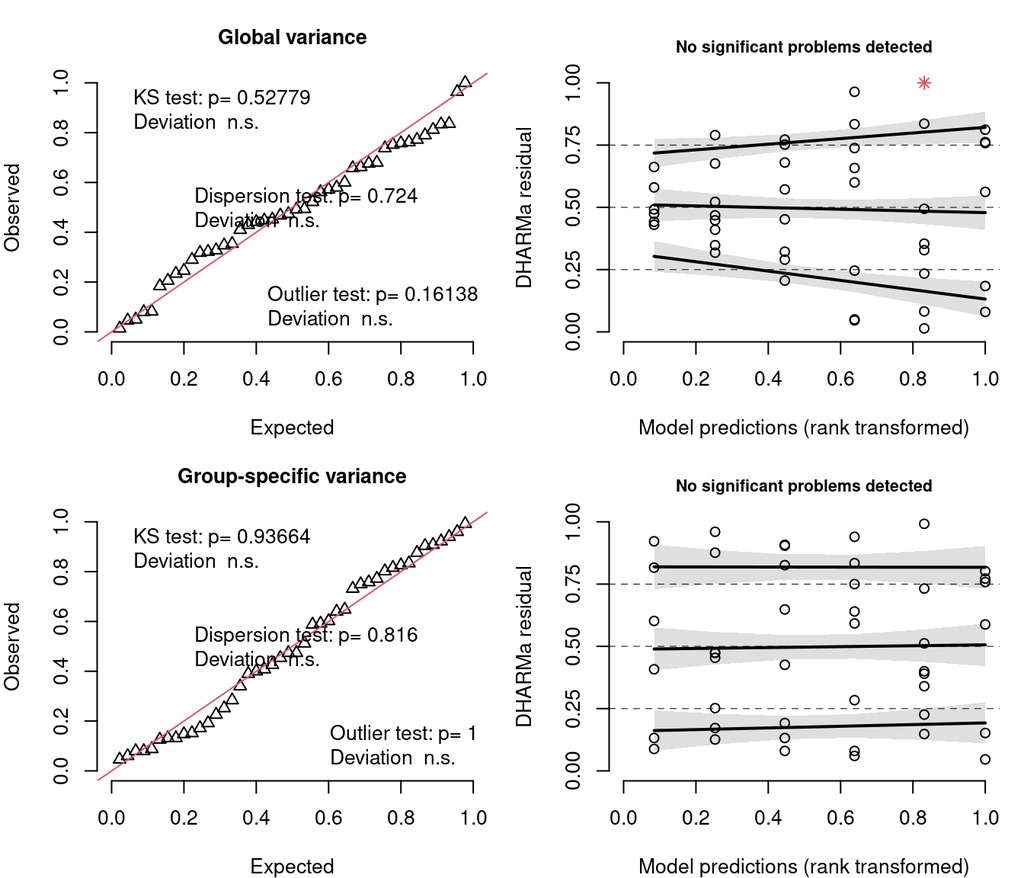

Diagnostic plots from DHARMa simulated residuals for models with and without group-specific residual variance. Top: random-intercept model with a single (global) residual variance. Bottom: random-intercept model allowing group-specific residual variance. Left: quantile–quantile plot comparing simulated residuals to the expected distribution. Right: residuals plotted against predicted values; black lines show the median (0.5) and lower/upper quartiles (0.25, 0.75) with shaded 95% simulation envelopes. Deviations from expected values suggest potential model misspecification

```r
set.seed(709)

res1 <- simulateResiduals(model_RI, n = 500)
res2 <- simulateResiduals(model_RI_difvar, n = 500)

op <- par(mfrow = c(2, 2), mar = c(4, 4, 3, 1))

plotQQunif(res1, main = "Global variance")
plotResiduals(res1, main = "")

plotQQunif(res2, main = "Group-specific variance")
plotResiduals(res2, main = "")
```

**Open code**

```r
par(op)
```

### 4.2.2 Fit final model

**Open code**

```r
model_final <- glmmTMB::glmmTMB(
  Proportion ~ Time + (1 | Experiment),
  data = data_long %>%
    filter(
      grepl('G1_phase_IF', Table),
      !is.na(Proportion)
    ),
  REML = TRUE,
  dispformula = ~ 0 + Time
)
```

### 4.2.3 Results

**Open code**

```r
kableExtra::kable(car::Anova(model_final))
```

|  | Chisq | Df | Pr(>Chisq) |
| --- | --- | --- | --- |
| Time | 2324.436 | 5 | 0 |

**Open code**

```r
summary(model_final)
##  Family: gaussian  ( identity )
## Formula:          Proportion ~ Time + (1 | Experiment)
## Dispersion:                  ~0 + Time
## Data: data_long %>% filter(grepl("G1_phase_IF", Table), !is.na(Proportion))
##
##      AIC      BIC   logLik deviance df.resid
##    236.8    260.0   -105.4    210.8       37
##
## Random effects:
##
## Conditional model:
##  Groups     Name        Variance  Std.Dev.
##  Experiment (Intercept) 7.849e-09 8.859e-05
##  Residual                      NA        NA
## Number of obs: 44, groups:  Experiment, 8
##
## Conditional model:
##              Estimate Std. Error z value Pr(>|z|)
## (Intercept)    4.0967     0.3547   11.55   <2e-16 ***
## Time1 hour     7.5133     0.8044    9.34   <2e-16 ***
## Time2 hours   20.6783     1.0232   20.21   <2e-16 ***
## Time4 hours   38.5721     1.9789   19.49   <2e-16 ***
## Time6 hours   49.1533     3.0446   16.14   <2e-16 ***
## Time12 hours  69.7283     1.7904   38.95   <2e-16 ***
## ---
## Signif. codes:  0 '***' 0.001 '**' 0.01 '*' 0.05 '.' 0.1 ' ' 1
##
## Dispersion model:
##              Estimate Std. Error z value Pr(>|z|)
## Time0 hours   -0.1405     0.3162  -0.444 0.656884
## Time1 hour     0.7139     0.2673   2.671 0.007558 **
## Time2 hours    0.9986     0.2673   3.737 0.000187 ***
## Time4 hours    1.7059     0.2673   6.383 1.74e-10 ***
## Time6 hours    2.1462     0.2673   8.031 9.71e-16 ***
## Time12 hours   1.4583     0.3162   4.611 4.00e-06 ***
## ---
## Signif. codes:  0 '***' 0.001 '**' 0.01 '*' 0.05 '.' 0.1 ' ' 1


contrast <- con_tab(model_final)

kableExtra::kable(
  contrast,
  caption = "Estimated pairwise differences in the proportion of G1-phase pRB⁺ β cells (%; immunofluorescence), obtained from a linear mixed-effects model with experiment as a random intercept, time as a categorical predictor, and allowance for group-specific residual variance. Columns: `contrast` (time points compared), `estimate` (mean difference in %), `CI` (Bonferroni-adjusted 95% confidence interval [lower, upper]), `SE` (standard error), `df` (degrees of freedom), `t.ratio` (test statistic), `p.value` (Bonferroni-adjusted p-value), and `stars` (significance code)."
)
```

Estimated pairwise differences in the proportion of G1-phase pRB⁺ β cells (%; immunofluorescence), obtained from a linear mixed-effects model with experiment as a random intercept, time as a categorical predictor, and allowance for group-specific residual variance. Columns: `contrast` (time points compared), `estimate` (mean difference in %), `CI` (Bonferroni-adjusted 95% confidence interval [lower, upper]), `SE` (standard error), `df` (degrees of freedom), `t.ratio` (test statistic), `p.value` (Bonferroni-adjusted p-value), and `stars` (significance code).

| contrast | estimate | CI | SE | df | t.ratio | p.value | stars |
| --- | --- | --- | --- | --- | --- | --- | --- |
| 0 hours - 1 hour | -7.51 | [-10.04, -4.99] | 0.80 | 37 | -9.34 | 0.0000000 | *** |
| 0 hours - 2 hours | -20.68 | [-23.89, -17.47] | 1.02 | 37 | -20.21 | 0.0000000 | *** |
| 0 hours - 4 hours | -38.57 | [-44.78, -32.36] | 1.98 | 37 | -19.49 | 0.0000000 | *** |
| 0 hours - 6 hours | -49.15 | [-58.71, -39.60] | 3.04 | 37 | -16.14 | 0.0000000 | *** |
| 0 hours - 12 hours | -69.73 | [-75.35, -64.11] | 1.79 | 37 | -38.95 | 0.0000000 | *** |
| 1 hour - 2 hours | -13.16 | [-16.93, -9.40] | 1.20 | 37 | -10.96 | 0.0000000 | *** |
| 1 hour - 4 hours | -31.06 | [-37.57, -24.54] | 2.08 | 37 | -14.96 | 0.0000000 | *** |
| 1 hour - 6 hours | -41.64 | [-51.40, -31.88] | 3.11 | 37 | -13.39 | 0.0000000 | *** |
| 1 hour - 12 hours | -62.22 | [-68.17, -56.26] | 1.90 | 37 | -32.79 | 0.0000000 | *** |
| 2 hours - 4 hours | -17.89 | [-24.70, -11.08] | 2.17 | 37 | -8.24 | 0.0000000 | *** |
| 2 hours - 6 hours | -28.47 | [-38.43, -18.52] | 3.17 | 37 | -8.98 | 0.0000000 | *** |
| 2 hours - 12 hours | -49.05 | [-55.33, -42.77] | 2.00 | 37 | -24.52 | 0.0000000 | *** |
| 4 hours - 6 hours | -10.58 | [-21.87, 0.70] | 3.60 | 37 | -2.94 | 0.0839441 | ns |
| 4 hours - 12 hours | -31.16 | [-39.38, -22.93] | 2.62 | 37 | -11.89 | 0.0000000 | *** |
| 6 hours - 12 hours | -20.58 | [-31.55, -9.60] | 3.50 | 37 | -5.89 | 0.0000135 | *** |

### 4.2.4 Visualisation

**Open code**

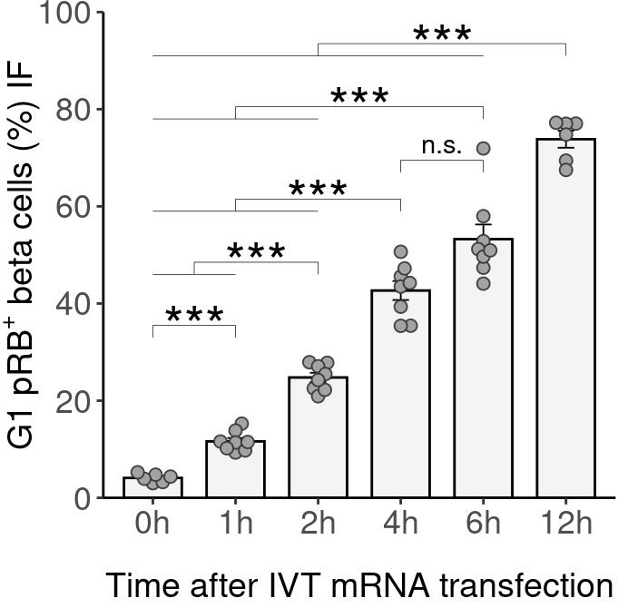

Proportion of G1-phase pRB⁺ beta cells (% by immunofluorescence) at different time points after IVT mRNA transfection. Bars show means ± SEM. ***, P < 0.001; **, P < 0.01; *, P < 0.05(adjusted P-values by Bonferroni correction). Statistical significance was assessed with linear mixed-effects model, including experiment as a random effect, time as a categorical predictor, and allowance for group-specific residual variance

```r
p <- data_long %>%
  filter(
      grepl('G1_phase_IF', Table),
      !is.na(Proportion)
    ) %>%
  mutate(
    Time = factor(Time,
                  levels = unique(Time),
                  labels = gsub(" hour[s]?", "h", gsub("Control", "Ctrl", unique(Time)))
                  )
    ) %>%
  ggplot(
    aes(x = Time, y = Proportion)
  ) +
  stat_summary(
    fun = 'mean',
    geom = 'col',
    fill = 'grey80', color = 'black',
    width = 0.7,
    alpha = 0.2
  ) +
  stat_summary(fun.data = mean_se, geom = "errorbar", width = 0.2, linewidth = 0.324) +
  scale_y_continuous(
    breaks = seq(0, 100, 20),
    name = expression("G1 pRB"^"+"~"beta cells (%) IF"),
    expand = expansion(mult = c(0, 0), add = c(0, 0))
  ) +
  coord_cartesian(ylim = c(0, 100)) +
  scale_x_discrete(name = "Time after IVT mRNA transfection",
    labels = function(x) gsub("Ctrl (.*)", "Ctrl\n\\1", x)) +
  geom_beeswarm(
    cex = 2,
    fill = 'grey64',
    size = 2.13,
    shape = 21,
    color = rgb(0.2, 0.2, 0.2, 0.9),
    stroke = 0.5
  ) +
  theme_classic() +
  theme(
    plot.margin = margin(t = 5, r = 1, b = 1, l = 1),
    axis.text.x = element_text(size = ax_text1),
    axis.text.y = element_text(size = ax_text1),
    axis.title.x = element_text(size = tit_text1, margin = margin(t = mar1 + mar_add)),
    axis.title.y = element_text(size = tit_text1, margin = margin(r = mar1b))
  )

start <- 95
tr <- 0
byp <- 13


p <- add_starm(6, c(1:5), start - tr, '***'); tr <-  tr + byp
p <- add_starm(5, c(1:3), start - tr, '***'); tr <-  tr + byp

tr <-  tr + 6

p <- add_starm(4, c(1:3), start - tr, '***'); tr <-  tr + byp
p <- add_starm(3, c(1:2), start - tr, '***'); tr <-  tr + byp
p <- add_starm(1, 2, start - tr, '***'); tr <-  tr + byp
p <- add_starm(4, 5, 71, '<sup>n.s.</sup>'); tr <-  tr + byp

p
```

**Open code**

```r
if (!file.exists("gitignore/figures/fig_02.pdf")) {
  ggsave("gitignore/figures/fig_02.pdf",
         plot = p, width = figw1, height = figh1, units = "in")
  }
```

### 4.2.5 Summary statistics over timpoints

**Open code**

```r
kableExtra::kable(
  data_long %>%
    dplyr::filter(grepl("G1_phase_IF", Table)) %>%
    tidyr::drop_na(Proportion) %>%
    dplyr::group_by(Time) %>%
    dplyr::summarise(
      mean = mean(Proportion),
      median = quantile(Proportion, probs = 0.5),
      SD = sd(Proportion),
      SEM = sem(Proportion)
    ),
  caption = "Summary statistics for the proportion of G1-phase pRB⁺ beta cells (% by immunofluorescence) at different time points after IVT mRNA transfection. Mean, median, SD, and SEM are shown; SD, standard deviation; SEM, standard error of the mean"
)
```

Summary statistics for the proportion of G1-phase pRB⁺ beta cells (% by immunofluorescence) at different time points after IVT mRNA transfection. Mean, median, SD, and SEM are shown; SD, standard deviation; SEM, standard error of the mean

| Time | mean | median | SD | SEM |
| --- | --- | --- | --- | --- |
| 0 hours | 4.096667 | 4.145 | 0.8689457 | 0.3547456 |
| 1 hour | 11.610000 | 11.440 | 2.0419598 | 0.7219418 |
| 2 hours | 24.775000 | 24.865 | 2.7145797 | 0.9597489 |
| 4 hours | 42.668750 | 43.865 | 5.5065712 | 1.9468669 |
| 6 hours | 53.250000 | 51.075 | 8.5527139 | 3.0238410 |
| 12 hours | 73.825000 | 75.895 | 4.2985335 | 1.7548689 |

# 5 G1 vs G0 Cell cycle occupation by FC

## 5.1 Create relavant datasets

**Open code**

```r
## to get means
data_occup <- data_long %>%
  mutate(
    Time = gsub(" hour[s]?", "h", gsub("Control", "Ctrl", Time))
  ) %>%
  filter(Table == 'G1_phase_FC_X_Cell_cycle_occupation _X_G1 pRB' |
           Table == 'Cell_cycle_occupation _X_NA_X_G0 pRB') %>%
  tidyr::drop_na(Proportion) %>%
  rename(
    Population = `Name.of.population`
  ) %>%
  dplyr::select(Time, Population, Proportion) %>%
  pivot_wider(
    names_from = Population,
    values_from = Proportion,
    values_fn = mean
  ) %>%
  mutate(Other = 100 - `G1 pRB` - `G0 pRB`)

data_occup
## # A tibble: 6 × 4
##   Time  `G1 pRB` `G0 pRB` Other
##   <chr>    <dbl>    <dbl> <dbl>
## 1 0h        2.47     94.5  3.04
## 2 1h       15.8      81.2  3.00
## 3 2h       26.2      70.4  3.42
## 4 4h       40.9      55.2  3.89
## 5 6h       50.2      46.2  3.61
## 6 12h      64.5      30.6  4.84

## to get SEM
sem_df <- data_long %>%
  mutate(
    Time = gsub(" hour[s]?", "h", gsub("Control", "Ctrl", Time))
  ) %>%
  filter(Table %in% c(
    'Cell_cycle_occupation _X_NA_X_G0 pRB',
    'G1_phase_FC_X_Cell_cycle_occupation _X_G1 pRB'
  )) %>%
  tidyr::drop_na(Proportion) %>%
  rename(Population = `Name.of.population`) %>%
  group_by(Time, Population) %>%
  summarise(sem = sd(Proportion)/sqrt(n()), .groups = "drop") %>%
  left_join(data_occup, by = "Time") %>%
  mutate(
    xmid = ifelse(
      Population == "G0 pRB",
      `G0 pRB`,
      `G0 pRB` + `G1 pRB`
    )
  ) %>%
  dplyr::mutate(Time = factor(Time, levels = c('0h', '1h', '2h', '4h', '6h', '12h')))

kableExtra::kable(sem_df %>% select(Time, Population, sem))
```

| Time | Population | sem |
| --- | --- | --- |
| 0h | G0 pRB | 0.6543364 |
| 0h | G1 pRB | 0.3239616 |
| 12h | G0 pRB | 2.5807591 |
| 12h | G1 pRB | 3.2155743 |
| 1h | G0 pRB | 1.6196131 |
| 1h | G1 pRB | 2.0356829 |
| 2h | G0 pRB | 2.6035805 |
| 2h | G1 pRB | 3.0058263 |
| 4h | G0 pRB | 1.8565352 |
| 4h | G1 pRB | 2.1941235 |
| 6h | G0 pRB | 2.3568535 |
| 6h | G1 pRB | 2.8371978 |

## 5.2 Plot

**Open code**

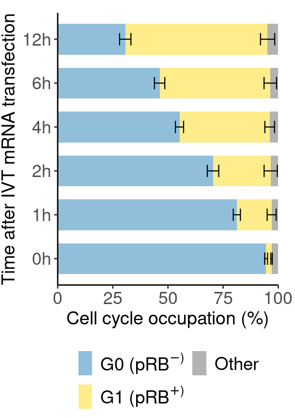

Proportion of G0 (pRB⁻), G1 (pRB⁺), and other beta cells (% by flow cytometry) at different time points after IVT mRNA transfection. Bars show means ± SEM (G0 and G1 only; “Other” plotted as 100% − G0 − G1).

```r
p <- data_occup %>%
  tidyr::pivot_longer(
    cols = c(`G0 pRB`, `G1 pRB`, Other),
    names_to = 'Phase',
    values_to = 'Percent'
  ) %>%
  dplyr::mutate(
    Phase = factor(Phase, levels = c('Other', 'G1 pRB', 'G0 pRB'))
  ) %>%
  ggplot(
    aes(
      y = Time,
      x = Percent,
      fill = Phase
    )
  ) +
  geom_col(width = 0.7) +
  scale_fill_manual(
    values = c(
      'G0 pRB' = '#91bfdb',
      'G1 pRB' = 'lightgoldenrod1',
      'Other' = 'grey70'
    ),
    breaks = c('G0 pRB', 'G1 pRB', 'Other'),
    labels = c(
      'G0 pRB' = expression('G0 (pRB'^-')'),
      'G1 pRB' = expression('G1 (pRB'^+')'),
      'Other'  = 'Other'
    ),
    name = NULL
  ) +
  labs(
    x = 'Cell cycle occupation (%)',
    y = 'Time after IVT mRNA transfection'
  ) +
  scale_x_continuous(
    limits = c(0, 100),
    expand = expansion(mult = c(0, 0), add = c(0, 0))
  ) +
  scale_y_discrete(
  labels = function(x) gsub(
    "(Ctrl|\\+RO|-RO)\\s*", "\\1\n", x
    ),
    breaks = c('0h', '1h', '2h', '4h', '6h', '12h')
  ) +
  theme_classic() +
  theme(
    axis.line.y = element_line(color = 'black'),
    axis.line.x = element_line(color = 'black'),
    legend.position = 'bottom',
    plot.margin = margin(t = 10, r = 13, b = 1, l = 1),
    axis.text.x = element_text(size = ax_text4),
    axis.text.y = element_text(size = ax_text4),
    axis.title.x = element_text(size = tit_text4),
    axis.title.y = element_text(size = tit_text4),
    legend.text = element_text(size = leg_text4),
    legend.key.size = unit(0.85, "lines")
  ) +
  geom_errorbarh(
    data = sem_df,
    aes(
      y = Time,
      xmin = xmid - sem,
      xmax = xmid + sem
    ),
    height = 0.28,
    inherit.aes = FALSE,
    linewidth = 0.4,
    color = 'black'
  ) +
  guides(
    fill = guide_legend(nrow = 2)
  )

p
```

**Open code**

```r
if (!file.exists("gitignore/figures/fig_03.pdf")) {
  ggsave(
    "gitignore/figures/fig_03.pdf",
    plot = p,
    width = figw2,
    height = figh2,
    units = "in"
  )
}
```

# 6 S phase FC

## 6.1 Show Data

**Open code**

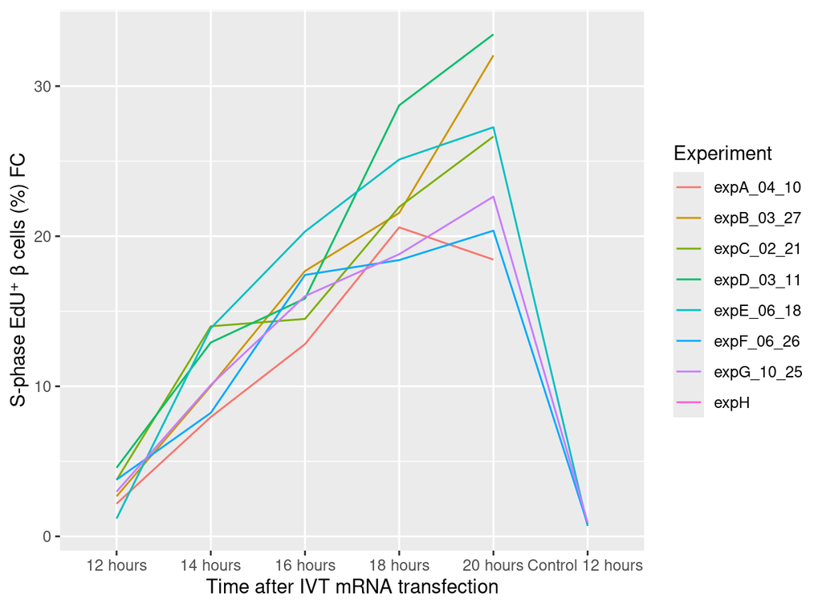

Mean proportion of S-phase EdU⁺ β cells (% by flow cytometry) at different time points after IVT mRNA transfection and across individual experiments

```r
data_long %>% filter(grepl('S_phase_FC', Table)) %>%
  ggplot(
    aes(x = Time, y = Proportion, group = Experiment, color = Experiment)
    ) +
  geom_line() +
  scale_y_continuous(
    name = "S-phase EdU⁺ β cells (%) FC"
  ) +
  scale_x_discrete(name = "Time after IVT mRNA transfection")
## Warning: Removed 10 rows containing missing values or values outside the scale range
## (`geom_line()`).
```

$\Rightarrow$ variances appeared to differ slightly between groups

## 6.2 Models

### 6.2.1 Choose model

AIC/BIC

**Open code**

```r
model_NR <- glmmTMB::glmmTMB(
  Proportion ~ Time,
  data = data_long %>%
    filter(
      grepl('S_phase_FC', Table),
      !is.na(Proportion)
    ) %>%
    mutate(Time = factor(Time)),
  REML = FALSE
)

model_RI <- glmmTMB::glmmTMB(
  Proportion ~ Time + (1 | Experiment),
  data = data_long %>%
    filter(
      grepl('S_phase_FC', Table),
      !is.na(Proportion)
    ) %>%
    mutate(Time = factor(Time)),
  REML = FALSE
)

model_NR_difvar <- glmmTMB::glmmTMB(
  Proportion ~ Time,
  data = data_long %>%
    filter(
      grepl('S_phase_FC', Table),
      !is.na(Proportion)
    ) %>%
    mutate(Time = factor(Time)),
  REML = FALSE,
  dispformula = ~ 0 + Time
)

model_RI_difvar <- glmmTMB::glmmTMB(
  Proportion ~ Time + (1 | Experiment),
  data = data_long %>%
    filter(
      grepl('S_phase_FC', Table),
      !is.na(Proportion)
    ) %>%
    mutate(Time = factor(Time)),
  REML = FALSE,
  dispformula = ~ 0 + Time
)

kableExtra::kable(AIC(model_NR, model_RI, model_NR_difvar, model_RI_difvar))
```

|  | df | AIC |
| --- | --- | --- |
| model_NR | 7 | 206.9023 |
| model_RI | 8 | 202.9117 |
| model_NR_difvar | 12 | 182.0317 |
| model_RI_difvar | 13 | 184.0317 |

**Open code**

```r
kableExtra::kable(BIC(model_NR, model_RI, model_NR_difvar, model_RI_difvar))
```

|  | df | BIC |
| --- | --- | --- |
| model_NR | 7 | 218.3655 |
| model_RI | 8 | 216.0124 |
| model_NR_difvar | 12 | 201.6828 |
| model_RI_difvar | 13 | 205.3203 |

Diagnostics

**Open code**

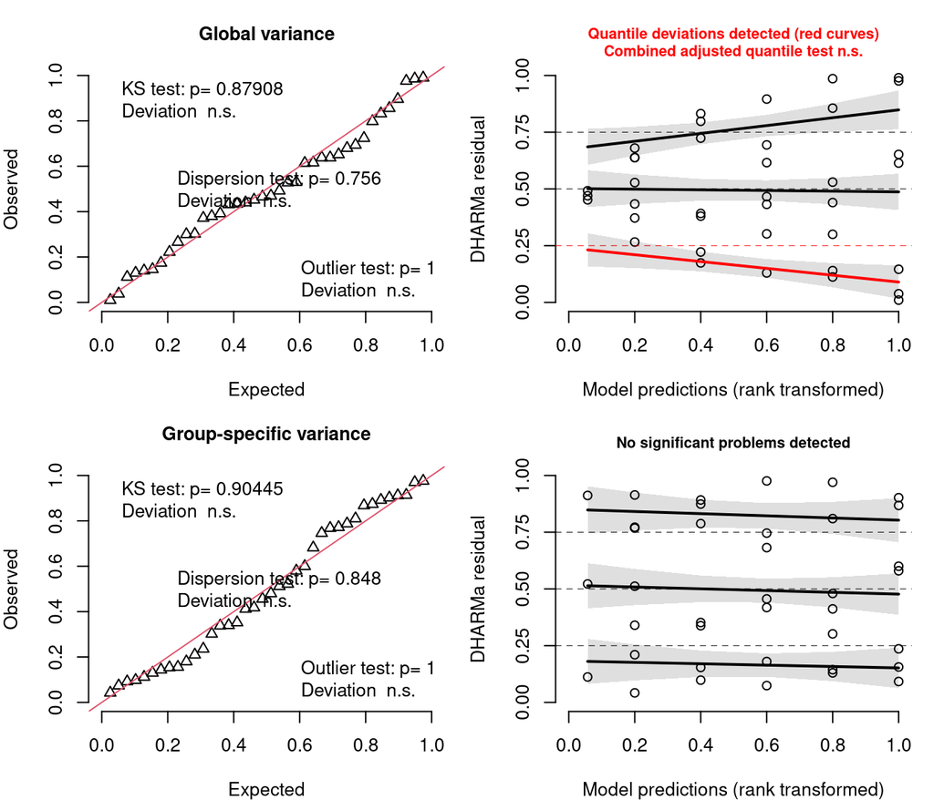

Diagnostic plots from DHARMa simulated residuals for models with and without group-specific residual variance. Top: random-intercept model with a single (global) residual variance. Bottom: random-intercept model allowing group-specific residual variance. Left: quantile–quantile plot comparing simulated residuals to the expected distribution. Right: residuals plotted against predicted values; black lines show the median (0.5) and lower/upper quartiles (0.25, 0.75) with shaded 95% simulation envelopes. Deviations from expected values suggest potential model misspecification

```r
set.seed(709)

res1 <- simulateResiduals(model_RI, n = 500)
res2 <- simulateResiduals(model_RI_difvar, n = 500)

op <- par(mfrow = c(2, 2), mar = c(4, 4, 3, 1))

plotQQunif(res1, main = "Global variance")
plotResiduals(res1, main = "")

plotQQunif(res2, main = "Group-specific variance")
plotResiduals(res2, main = "")
```

**Open code**

```r
par(op)
```

### 6.2.2 Fit final model

**Open code**

```r
model_final <- glmmTMB::glmmTMB(
  Proportion ~ Time + (1 | Experiment),
  data = data_long %>%
    filter(
      grepl('S_phase_FC', Table),
      !is.na(Proportion)
    ),
  REML = TRUE,
  dispformula = ~ 0 + Time
)
```

### 6.2.3 Results

**Open code**

```r
kableExtra::kable(car::Anova(model_final))
```

|  | Chisq | Df | Pr(>Chisq) |
| --- | --- | --- | --- |
| Time | 788.4532 | 5 | 0 |

**Open code**

```r
summary(model_final)
##  Family: gaussian  ( identity )
## Formula:          Proportion ~ Time + (1 | Experiment)
## Dispersion:                  ~0 + Time
## Data: data_long %>% filter(grepl("S_phase_FC", Table), !is.na(Proportion))
##
##      AIC      BIC   logLik deviance df.resid
##    178.8    200.1    -76.4    152.8       31
##
## Random effects:
##
## Conditional model:
##  Groups     Name        Variance  Std.Dev.
##  Experiment (Intercept) 2.993e-09 5.471e-05
##  Residual                      NA        NA
## Number of obs: 38, groups:  Experiment, 7
##
## Conditional model:
##                       Estimate Std. Error z value Pr(>|z|)
## (Intercept)             3.0186     0.4283   7.047 1.83e-12 ***
## Time14 hours            7.9914     1.0625   7.521 5.42e-14 ***
## Time16 hours           13.3486     1.0078  13.245  < 2e-16 ***
## Time18 hours           19.1429     1.4448  13.249  < 2e-16 ***
## Time20 hours           22.8171     2.1918  10.410  < 2e-16 ***
## TimeControl 12 hours   -2.2119     0.4335  -5.103 3.35e-07 ***
## ---
## Signif. codes:  0 '***' 0.001 '**' 0.01 '*' 0.05 '.' 0.1 ' ' 1
##
## Dispersion model:
##                       Estimate Std. Error z value Pr(>|z|)
## Time12 hours            0.1251     0.2887   0.433  0.66466
## Time14 hours            0.9449     0.2887   3.273  0.00106 **
## Time16 hours            0.8811     0.2887   3.052  0.00227 **
## Time18 hours            1.2949     0.2887   4.486 7.26e-06 ***
## Time20 hours            1.7382     0.2887   6.021 1.73e-09 ***
## TimeControl 12 hours   -2.1625     0.5000  -4.325 1.53e-05 ***
## ---
## Signif. codes:  0 '***' 0.001 '**' 0.01 '*' 0.05 '.' 0.1 ' ' 1

contrast <- con_tab(model_final)

kableExtra::kable(
  contrast,
  caption = "Estimated pairwise differences in the proportion of S-phase EdU⁺ β cells (%; flow cytometry), obtained from a linear mixed-effects model with experiment as a random intercept, time as a categorical predictor, and allowance for group-specific residual variance. Columns: `contrast` (time points compared), `estimate` (mean difference in %), `CI` (Bonferroni-adjusted 95% confidence interval [lower, upper]), `SE` (standard error), `df` (degrees of freedom), `t.ratio` (test statistic), `p.value` (Bonferroni-adjusted p-value), and `stars` (significance code)."
)
```

Estimated pairwise differences in the proportion of S-phase EdU⁺ β cells (%; flow cytometry), obtained from a linear mixed-effects model with experiment as a random intercept, time as a categorical predictor, and allowance for group-specific residual variance. Columns: `contrast` (time points compared), `estimate` (mean difference in %), `CI` (Bonferroni-adjusted 95% confidence interval [lower, upper]), `SE` (standard error), `df` (degrees of freedom), `t.ratio` (test statistic), `p.value` (Bonferroni-adjusted p-value), and `stars` (significance code).

| contrast | estimate | CI | SE | df | t.ratio | p.value | stars |
| --- | --- | --- | --- | --- | --- | --- | --- |
| 12 hours - 14 hours | -7.99 | [-11.37, -4.61] | 1.06 | 31 | -7.52 | 0.0000003 | *** |
| 12 hours - 16 hours | -13.35 | [-16.55, -10.14] | 1.01 | 31 | -13.25 | 0.0000000 | *** |
| 12 hours - 18 hours | -19.14 | [-23.74, -14.55] | 1.44 | 31 | -13.25 | 0.0000000 | *** |
| 12 hours - 20 hours | -22.82 | [-29.79, -15.85] | 2.19 | 31 | -10.41 | 0.0000000 | *** |
| 12 hours - Control 12 hours | 2.21 | [0.83, 3.59] | 0.43 | 31 | 5.10 | 0.0002399 | *** |
| 14 hours - 16 hours | -5.36 | [-9.60, -1.12] | 1.33 | 31 | -4.02 | 0.0052101 | ** |
| 14 hours - 18 hours | -11.15 | [-16.52, -5.78] | 1.69 | 31 | -6.61 | 0.0000033 | *** |
| 14 hours - 20 hours | -14.83 | [-22.33, -7.32] | 2.36 | 31 | -6.28 | 0.0000082 | *** |
| 14 hours - Control 12 hours | 10.20 | [7.10, 13.30] | 0.97 | 31 | 10.47 | 0.0000000 | *** |
| 16 hours - 18 hours | -5.79 | [-11.05, -0.53] | 1.65 | 31 | -3.50 | 0.0213291 | * |
| 16 hours - 20 hours | -9.47 | [-16.89, -2.04] | 2.34 | 31 | -4.05 | 0.0047020 | ** |
| 16 hours - Control 12 hours | 15.56 | [12.65, 18.47] | 0.91 | 31 | 17.01 | 0.0000000 | *** |
| 18 hours - 20 hours | -3.67 | [-11.80, 4.45] | 2.55 | 31 | -1.44 | 1.0000000 | ns |
| 18 hours - Control 12 hours | 21.35 | [16.96, 25.75] | 1.38 | 31 | 15.46 | 0.0000000 | *** |
| 20 hours - Control 12 hours | 25.03 | [18.19, 31.87] | 2.15 | 31 | 11.64 | 0.0000000 | *** |

### 6.2.4 Visualisation

**Open code**

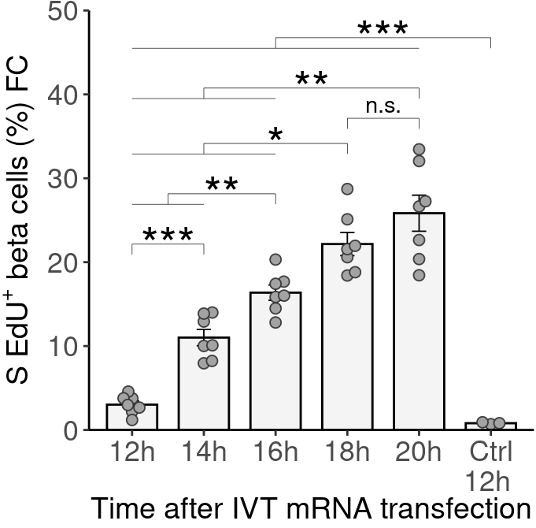

Proportion of S-phase EdU⁺ beta cells (% by flow cytometry) at different time points after IVT mRNA transfection. Bars show means ± SEM. ***, P < 0.001; **, P < 0.01; *, P < 0.05(adjusted P-values by Bonferroni correction). Statistical significance was assessed with linear mixed-effects model, including experiment as a random effect, time as a categorical predictor, and allowance for group-specific residual variance

```r
scale <- 2

p <- data_long %>%
  filter(
      grepl('S_phase_FC', Table),
      !is.na(Proportion)
    ) %>%
  mutate(
    Time = factor(
      Time,
      levels = unique(Time),
      labels = gsub(" hour[s]?", "h", gsub("Control", "Ctrl", unique(Time)))
      )
    ) %>%
  ggplot(
    aes(x = Time, y = Proportion)
  ) +
  stat_summary(
    fun = 'mean',
    geom = 'col',
    fill = 'grey80', color = 'black',
    width = 0.7,
    alpha = 0.2
  ) +
  stat_summary(fun.data = mean_se, geom = "errorbar", width = 0.2, linewidth = 0.324) +
  scale_y_continuous(
    breaks = seq(0, 100/scale, 20/scale),
    name = expression("S EdU"^"+"~"beta cells (%) FC"),
    expand = expansion(mult = c(0, 0), add = c(0, 0))
  ) +
  coord_cartesian(ylim = c(0, 100/scale)) +
  scale_x_discrete(name = "Time after IVT mRNA transfection",
    labels = function(x) gsub("Ctrl (.*)", "Ctrl\n\\1", x)) +
  geom_beeswarm(
    cex = 2,
    fill = 'grey64',
    size = 2.13,
    shape = 21,
    color = rgb(0.2, 0.2, 0.2, 0.9),
    stroke = 0.5
  ) +
  theme_classic() +
  theme(
    plot.margin = margin(t = 5, r = 1, b = 1, l = 1),
    axis.text.x = element_text(size = ax_text1),
    axis.text.y = element_text(size = ax_text1),
    axis.title.x = element_text(size = tit_text1, margin = margin(t = mar1)),
    axis.title.y = element_text(size = tit_text1)
  )

start <- 95/scale
tr <- 0
byp <- 12/scale

p <- add_starm(6, c(1:5), start - tr, '***', scal = scale); tr <-  tr + byp
p <- add_starm(5, c(1:3), start - tr, '**', scal = scale); tr <-  tr + byp*0.6
p <- add_starm(5, 4, start - tr, '<sup>n.s.</sup>', scal = scale); tr <-  tr + byp*0.5
p <- add_starm(4, c(1:3), start - tr, '*', scal = scale); tr <-  tr + byp
p <- add_starm(3, c(1:2), start - tr, '**', scal = scale); tr <-  tr + byp
p <- add_starm(2, 1, start - tr, '***', scal = scale); tr <-  tr + byp

p
```

**Open code**

```r
if (!file.exists("gitignore/figures/fig_04.pdf")) {
  ggsave("gitignore/figures/fig_04.pdf",
         plot = p, width = figw1, height = figh1, units = "in")
  }
```

### 6.2.5 Summary statistics over timpoints

**Open code**

```r
kableExtra::kable(
  data_long %>%
    dplyr::filter(grepl("S_phase_FC", Table)) %>%
    tidyr::drop_na(Proportion) %>%
    dplyr::group_by(Time) %>%
    dplyr::summarise(
      mean = mean(Proportion),
      median = quantile(Proportion, probs = 0.5),
      SD = sd(Proportion),
      SEM = sem(Proportion)
    ),
  caption = "Summary statistics for the proportion of S-phase EdU⁺ beta cells (% by flow cytometry) at different time points after IVT mRNA transfection. Mean, median, SD, and SEM are shown; SD, standard deviation; SEM, standard error of the mean"
)
```

Summary statistics for the proportion of S-phase EdU⁺ beta cells (% by flow cytometry) at different time points after IVT mRNA transfection. Mean, median, SD, and SEM are shown; SD, standard deviation; SEM, standard error of the mean

| Time | mean | median | SD | SEM |
| --- | --- | --- | --- | --- |
| 12 hours | 3.0185714 | 2.98 | 1.1333053 | 0.4283491 |
| 14 hours | 11.0100000 | 10.09 | 2.5724891 | 0.9723095 |
| 16 hours | 16.3671429 | 16.01 | 2.4135086 | 0.9122205 |
| 18 hours | 22.1614286 | 21.55 | 3.6507827 | 1.3798662 |
| 20 hours | 25.8357143 | 26.64 | 5.6870228 | 2.1494926 |
| Control 12 hours | 0.8066667 | 0.81 | 0.1150362 | 0.0664162 |

# 7 S CA2 FC

## 7.1 Show Data

**Open code**

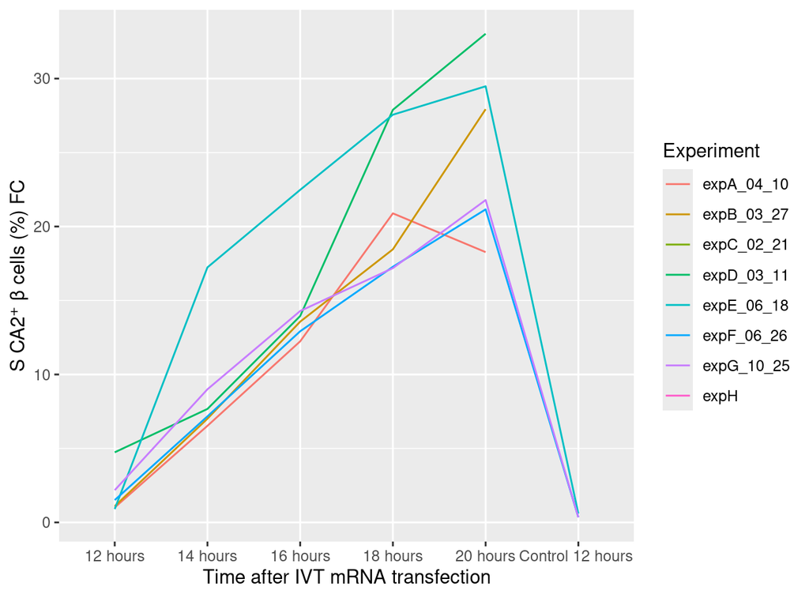

Mean proportion of S-phase CA2⁺ β cells (% by flow cytometry) at different time points after IVT mRNA transfection and across individual experiments

```r
data_long %>% filter(grepl('S_CA2_FC', Table)) %>%
  ggplot(
    aes(x = Time, y = Proportion, group = Experiment, color = Experiment)
    ) +
  geom_line() +
  scale_y_continuous(
    name = "S CA2⁺ β cells (%) FC"
  ) +
  scale_x_discrete(name = "Time after IVT mRNA transfection")
## Warning: Removed 15 rows containing missing values or values outside the scale range
## (`geom_line()`).
```

$\Rightarrow$ Variances seem to differ slightly between time points

## 7.2 Models

### 7.2.1 Choose model

AIC/BIC

**Open code**

```r
model_NR <- glmmTMB::glmmTMB(
  Proportion ~ Time,
  data = data_long %>%
    filter(
      grepl('S_CA2_FC', Table),
      !is.na(Proportion)
    ) %>%
    mutate(Time = factor(Time)),
  REML = FALSE
)

model_RI <- glmmTMB::glmmTMB(
  Proportion ~ Time + (1 | Experiment),
  data = data_long %>%
    filter(
      grepl('S_CA2_FC', Table),
      !is.na(Proportion)
    ) %>%
    mutate(Time = factor(Time)),
  REML = FALSE
)


model_NR_difvar <- glmmTMB::glmmTMB(
  Proportion ~ Time,
  data = data_long %>%
    filter(
      grepl('S_CA2_FC', Table),
      !is.na(Proportion)
    ) %>%
    mutate(Time = factor(Time)),
  REML = FALSE,
  dispformula = ~ 0 + Time
)

model_RI_difvar <- glmmTMB::glmmTMB(
  Proportion ~ Time + (1 | Experiment),
  data = data_long %>%
    filter(
      grepl('S_CA2_FC', Table),
      !is.na(Proportion)
    ) %>%
    mutate(Time = factor(Time)),
  REML = FALSE,
  dispformula = ~ 0 + Time
)

kableExtra::kable(AIC(model_NR, model_RI, model_NR_difvar, model_RI_difvar))
```

|  | df | AIC |
| --- | --- | --- |
| model_NR | 7 | 194.0051 |
| model_RI | 8 | 188.4201 |
| model_NR_difvar | 12 | 177.0210 |
| model_RI_difvar | 13 | 185.1364 |

**Open code**

```r
kableExtra::kable(BIC(model_NR, model_RI, model_NR_difvar, model_RI_difvar))
```

|  | df | BIC |
| --- | --- | --- |
| model_NR | 7 | 204.4806 |
| model_RI | 8 | 200.3921 |
| model_NR_difvar | 12 | 194.9791 |
| model_RI_difvar | 13 | 204.5910 |

Diagnostics

**Open code**

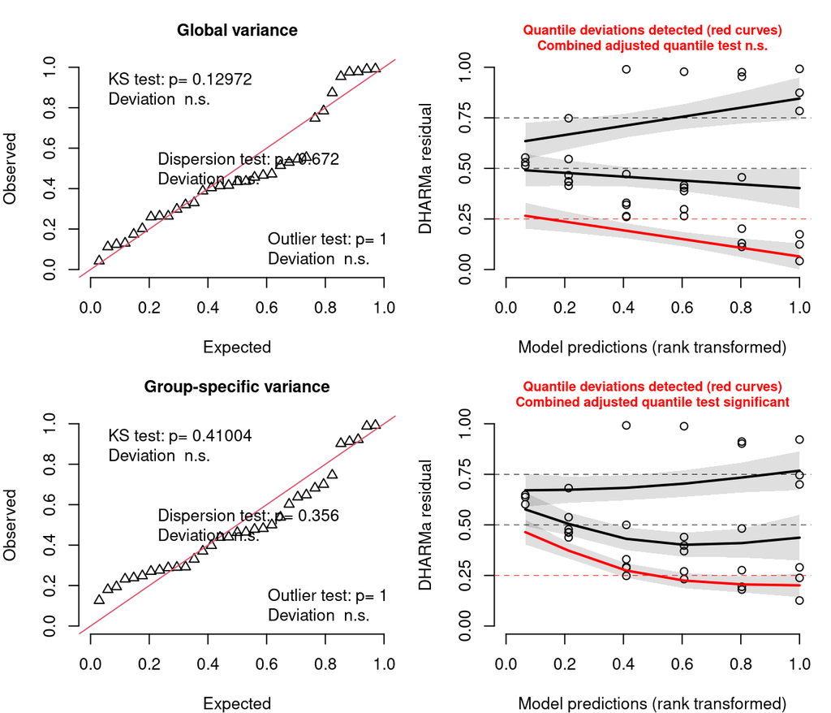

Diagnostic plots from DHARMa simulated residuals for models with and without group-specific residual variance. Top: random-intercept model with a single (global) residual variance. Bottom: random-intercept model allowing group-specific residual variance. Left: quantile–quantile plot comparing simulated residuals to the expected distribution. Right: residuals plotted against predicted values; black lines show the median (0.5) and lower/upper quartiles (0.25, 0.75) with shaded 95% simulation envelopes. Deviations from expected values suggest potential model misspecification

```r
set.seed(709)

res1 <- simulateResiduals(model_RI, n = 500)
res2 <- simulateResiduals(model_RI_difvar, n = 500)

op <- par(mfrow = c(2, 2), mar = c(4, 4, 3, 1))

plotQQunif(res1, main = "Global variance")
plotResiduals(res1, main = "")

plotQQunif(res2, main = "Group-specific variance")
plotResiduals(res2, main = "")
```

**Open code**

```r
par(op)
```

$\Rightarrow$ Allowing group-specific residual variance does not improve AIC/BIC substantially; group-specific variance will not be therefore allowed for the final model. Although there is a slight issue, distributional assumptions seems violated only slightly and alternative models did not solve this.

### 7.2.2 Fit final model

**Open code**

```r
model_final <- glmmTMB::glmmTMB(
  Proportion ~ Time + (1 | Experiment),
  data = data_long %>%
    filter(
      grepl('S_CA2_FC', Table),
      !is.na(Proportion)
    ),
  REML = TRUE
)
```

### 7.2.3 Results

**Open code**

```r
kableExtra::kable(car::Anova(model_final))
```

|  | Chisq | Df | Pr(>Chisq) |
| --- | --- | --- | --- |
| Time | 261.242 | 5 | 0 |

**Open code**

```r
summary(model_final)
##  Family: gaussian  ( identity )
## Formula:          Proportion ~ Time + (1 | Experiment)
## Data: data_long %>% filter(grepl("S_CA2_FC", Table), !is.na(Proportion))
##
##      AIC      BIC   logLik deviance df.resid
##    172.6    184.6    -78.3    156.6       31
##
## Random effects:
##
## Conditional model:
##  Groups     Name        Variance Std.Dev.
##  Experiment (Intercept)  6.436   2.537
##  Residual               10.123   3.182
## Number of obs: 33, groups:  Experiment, 6
##
## Dispersion estimate for gaussian family (sigma^2): 10.1
##
## Conditional model:
##                       Estimate Std. Error z value Pr(>|z|)
## (Intercept)              1.907      1.661   1.148    0.251
## Time14 hours             7.197      1.837   3.918 8.94e-05 ***
## Time16 hours            13.002      1.837   7.078 1.46e-12 ***
## Time18 hours            19.638      1.837  10.691  < 2e-16 ***
## Time20 hours            23.370      1.837  12.722  < 2e-16 ***
## TimeControl 12 hours    -1.676      2.306  -0.727    0.467
## ---
## Signif. codes:  0 '***' 0.001 '**' 0.01 '*' 0.05 '.' 0.1 ' ' 1

contrast <- con_tab(model_final)

kableExtra::kable(
  contrast,
  caption = "Estimated pairwise differences in the proportion of S-phase CA2⁺ β cells (%; flow cytometry), obtained from a linear mixed-effects model with experiment as a random intercept and time as a categorical predictor. Columns: `contrast` (time points compared), `estimate` (mean difference in %), `CI` (Bonferroni-adjusted 95% confidence interval [lower, upper]), `SE` (standard error), `df` (degrees of freedom), `t.ratio` (test statistic), `p.value` (Bonferroni-adjusted p-value), and `stars` (significance code)"
)
```

Estimated pairwise differences in the proportion of S-phase CA2⁺ β cells (%; flow cytometry), obtained from a linear mixed-effects model with experiment as a random intercept and time as a categorical predictor. Columns: `contrast` (time points compared), `estimate` (mean difference in %), `CI` (Bonferroni-adjusted 95% confidence interval [lower, upper]), `SE` (standard error), `df` (degrees of freedom), `t.ratio` (test statistic), `p.value` (Bonferroni-adjusted p-value), and `stars` (significance code)

| contrast | estimate | CI | SE | df | t.ratio | p.value | stars |
| --- | --- | --- | --- | --- | --- | --- | --- |
| 12 hours - 14 hours | -7.20 | [-13.04, -1.36] | 1.84 | 31 | -3.92 | 0.0068824 | ** |
| 12 hours - 16 hours | -13.00 | [-18.84, -7.16] | 1.84 | 31 | -7.08 | 0.0000009 | *** |
| 12 hours - 18 hours | -19.64 | [-25.48, -13.80] | 1.84 | 31 | -10.69 | 0.0000000 | *** |
| 12 hours - 20 hours | -23.37 | [-29.21, -17.53] | 1.84 | 31 | -12.72 | 0.0000000 | *** |
| 12 hours - Control 12 hours | 1.68 | [-5.66, 9.01] | 2.31 | 31 | 0.73 | 1.0000000 | ns |
| 14 hours - 16 hours | -5.81 | [-11.65, 0.04] | 1.84 | 31 | -3.16 | 0.0526342 | ns |
| 14 hours - 18 hours | -12.44 | [-18.28, -6.60] | 1.84 | 31 | -6.77 | 0.0000021 | *** |
| 14 hours - 20 hours | -16.17 | [-22.01, -10.33] | 1.84 | 31 | -8.80 | 0.0000000 | *** |
| 14 hours - Control 12 hours | 8.87 | [1.54, 16.21] | 2.31 | 31 | 3.85 | 0.0083721 | ** |
| 16 hours - 18 hours | -6.64 | [-12.48, -0.80] | 1.84 | 31 | -3.61 | 0.0158571 | * |
| 16 hours - 20 hours | -10.37 | [-16.21, -4.53] | 1.84 | 31 | -5.64 | 0.0000508 | *** |
| 16 hours - Control 12 hours | 14.68 | [7.34, 22.01] | 2.31 | 31 | 6.36 | 0.0000066 | *** |
| 18 hours - 20 hours | -3.73 | [-9.57, 2.11] | 1.84 | 31 | -2.03 | 0.7628041 | ns |
| 18 hours - Control 12 hours | 21.31 | [13.98, 28.65] | 2.31 | 31 | 9.24 | 0.0000000 | *** |
| 20 hours - Control 12 hours | 25.05 | [17.71, 32.38] | 2.31 | 31 | 10.86 | 0.0000000 | *** |

### 7.2.4 Visualisation

**Open code**

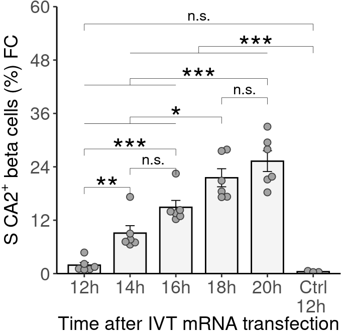

Proportion of S-phase CA2⁺ beta cells (% by flow cytometry) at different time points after IVT mRNA transfection. Bars show means ± SEM. ***, P < 0.001; **, P < 0.01; *, P < 0.05(adjusted P-values by Bonferroni correction). Statistical significance was assessed with linear mixed-effects model, including experiment as a random effect and time as a categorical predictor

```r
scale <- 10/6

p <- data_long %>%
  filter(
      grepl('S_CA2_FC', Table),
      !is.na(Proportion)
    ) %>%
  mutate(
    Time = factor(Time,
                  levels = unique(Time),
                  labels = gsub(" hour[s]?", "h", gsub("Control", "Ctrl", unique(Time)))
                  )
    ) %>%
  ggplot(
    aes(x = Time, y = Proportion)
  ) +
  stat_summary(
    fun = 'mean',
    geom = 'col',
    fill = 'grey80', color = 'black',
    width = 0.7,
    alpha = 0.2
  ) +
  stat_summary(fun.data = mean_se, geom = "errorbar", width = 0.2, linewidth = 0.324) +
  scale_y_continuous(
    breaks = seq(0, 100/scale, 20/scale),
    name = expression("S CA2"^"+"~"beta cells (%) FC"),
    expand = expansion(mult = c(0, 0), add = c(0, 0))
  ) +
  coord_cartesian(ylim = c(0, 100/scale)) +
  scale_x_discrete(name = "Time after IVT mRNA transfection",
    labels = function(x) gsub("Ctrl (.*)", "Ctrl\n\\1", x)) +
  geom_beeswarm(
    cex = 2,
    fill = 'grey64',
    size = 2.13,
    shape = 21,
    color = rgb(0.2, 0.2, 0.2, 0.9),
    stroke = 0.5
  ) +
  theme_classic() +
  theme(
    plot.margin = margin(t = 5, r = 1, b = 1, l = 1),
    axis.text.x = element_text(size = ax_text1),
    axis.text.y = element_text(size = ax_text1),
    axis.title.x = element_text(size = tit_text1, margin = margin(t = mar1)),
    axis.title.y = element_text(size = tit_text1)
  )

start <- 95/scale
tr <- 0
byp <- 12/scale

p <- add_starm(6, 1, start - tr, '<sup>n.s.</sup>', scal = scale); tr <-  tr + byp*0.7
p <- add_starm(6, c(2:5), start - tr, '***', scal = scale); tr <-  tr + byp
p <- add_starm(5, c(1:3), start - tr, '***', scal = scale); tr <-  tr + byp*0.6
p <- add_starm(5, 4, start - tr, '<sup>n.s.</sup>', scal = scale); tr <-  tr + byp*0.6
p <- add_starm(4, c(1:3), start - tr, '*', scal = scale); tr <-  tr + byp
p <- add_starm(3, 1, start - tr, '***', scal = scale); tr <-  tr + byp*0.6
p <- add_starm(3, 2, start - tr, '<sup>n.s.</sup>', scal = scale); tr <-  tr + byp*0.6
p <- add_starm(2, 1, start - tr, '**', scal = scale); tr <-  tr + byp*0.4

p
```

**Open code**

```r
if (!file.exists("gitignore/figures/fig_05.pdf")) {
  ggsave("gitignore/figures/fig_05.pdf", plot = p, width = figw1, height = figh1, units = "in")
  ggsave("gitignore/figures/fig_05.svg", plot = p, width = figw1, height = figh1, units = "in")
  }
```

### 7.2.5 Summary statistics over timpoints

**Open code**

```r
kableExtra::kable(
  data_long %>%
    dplyr::filter(grepl("S_CA2_FC", Table)) %>%
    tidyr::drop_na(Proportion) %>%
    dplyr::group_by(Time) %>%
    dplyr::summarise(
      mean = mean(Proportion),
      median = quantile(Proportion, probs = 0.5),
      SD = sd(Proportion),
      SEM = sem(Proportion)
    ),
  caption = "Summary statistics for the proportion of S-phase CA2⁺ beta cells (% by flow cytometry) at different time points after IVT mRNA transfection. Mean, median, SD, and SEM are shown; SD, standard deviation; SEM, standard error of the mean"
)
```

Summary statistics for the proportion of S-phase CA2⁺ beta cells (% by flow cytometry) at different time points after IVT mRNA transfection. Mean, median, SD, and SEM are shown; SD, standard deviation; SEM, standard error of the mean

| Time | mean | median | SD | SEM |
| --- | --- | --- | --- | --- |
| 12 hours | 1.906667 | 1.305 | 1.4647821 | 0.5979948 |
| 14 hours | 9.103333 | 7.420 | 4.0746125 | 1.6634536 |
| 16 hours | 14.908333 | 13.760 | 3.7814146 | 1.5437561 |
| 18 hours | 21.545000 | 19.675 | 4.9707494 | 2.0293000 |
| 20 hours | 25.276667 | 24.860 | 5.7099831 | 2.3310908 |
| Control 12 hours | 0.430000 | 0.350 | 0.1473092 | 0.0850490 |

# 8 CA2 Cell cycle occupation by FC

## 8.1 Create relavant datasets

**Open code**

```r
## to get means
data_occup <- data_long %>%
  mutate(
    Time = gsub(" hour[s]?", "h", gsub("Control", "Ctrl", Time))
  ) %>%
  filter(
    grepl('Cell_cycle_occupation1', Table)
  ) %>%
  tidyr::drop_na(Proportion) %>%
  rename(
    Population = `Name.of.population`
  ) %>%
  dplyr::select(Time, Population, Proportion) %>%
  pivot_wider(
    names_from = Population,
    values_from = Proportion,
    values_fn = mean
  ) %>%
  mutate(Other = 100 - `S CA2 FC` - `G0G1 CA2` - `Late G1 CA2` - `G2M CA2`)

data_occup
## # A tibble: 6 × 6
##   Time        `S CA2 FC` `G0G1 CA2` `Late G1 CA2` `G2M CA2` Other
##   <chr>            <dbl>      <dbl>         <dbl>     <dbl> <dbl>
## 1 "12h"             1.91       91.8         3.65      0.623  2.02
## 2 "14h"             9.10       78.7         8.56      1.12   2.53
## 3 "16h"            14.9        69.0        10.6       2.34   3.21
## 4 "18h"            21.5        60.2        10.0       5.55   2.69
## 5 "20h"            25.3        52.8         8.76      9.95   3.17
## 6 "Ctrl 12h "       0.43       96.9         0.373     0.703  1.64

## to get SEM
sem_df <- data_long %>%
  mutate(
    Time = gsub(" hour[s]?", "h", gsub("Control", "Ctrl", Time))
  ) %>%
  filter(
    grepl('Cell_cycle_occupation1', Table)
  ) %>%
  tidyr::drop_na(Proportion) %>%
  rename(Population = `Name.of.population`) %>%
  group_by(Time, Population) %>%
  summarise(sem = sd(Proportion)/sqrt(n()), .groups = "drop") %>%
  left_join(data_occup, by = "Time") %>%
  mutate(
    xmid = case_when(
      Population == "G0G1 CA2" ~ `G0G1 CA2`,
      Population == "Late G1 CA2" ~ `G0G1 CA2` + `Late G1 CA2`,
      Population == "S CA2 FC" ~ `G0G1 CA2` + `Late G1 CA2` + `S CA2 FC`,
      Population == "G2M CA2" ~ `G0G1 CA2` + `Late G1 CA2` +
        `S CA2 FC` + `G2M CA2`
  )
)

kableExtra::kable(sem_df %>% select(Time, Population, sem))
```

| Time | Population | sem |
| --- | --- | --- |
| 12h | G0G1 CA2 | 1.2637616 |
| 12h | G2M CA2 | 0.0851926 |
| 12h | Late G1 CA2 | 0.8330323 |
| 12h | S CA2 FC | 0.5979948 |
| 14h | G0G1 CA2 | 2.9171010 |
| 14h | G2M CA2 | 0.1797112 |
| 14h | Late G1 CA2 | 1.2036216 |
| 14h | S CA2 FC | 1.6634536 |
| 16h | G0G1 CA2 | 2.9816029 |
| 16h | G2M CA2 | 0.4958612 |
| 16h | Late G1 CA2 | 0.9046129 |
| 16h | S CA2 FC | 1.5437561 |
| 18h | G0G1 CA2 | 2.9136214 |
| 18h | G2M CA2 | 0.9873387 |
| 18h | Late G1 CA2 | 0.7589144 |
| 18h | S CA2 FC | 2.0293000 |
| 20h | G0G1 CA2 | 2.9560029 |
| 20h | G2M CA2 | 1.4116185 |
| 20h | Late G1 CA2 | 0.4662099 |
| 20h | S CA2 FC | 2.3310908 |
| Ctrl 12h | G0G1 CA2 | 0.4200132 |
| Ctrl 12h | G2M CA2 | 0.0837324 |
| Ctrl 12h | Late G1 CA2 | 0.0883805 |
| Ctrl 12h | S CA2 FC | 0.0850490 |

## 8.2 Plot

**Open code**

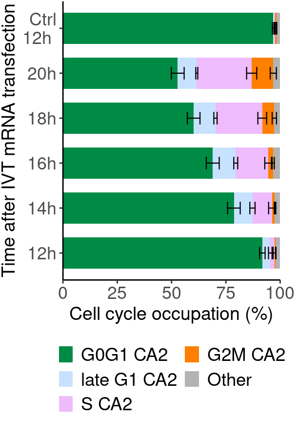

Proportion of beta cells in different cell-cycle phases (% by flow cytometry) at different time points after IVT mRNA transfection: G0G1, Late G1, S, G2M, and Other. Bars show means ± SEM.

```r
p <- data_occup %>%
  tidyr::pivot_longer(
    cols = c(`G0G1 CA2`, `Late G1 CA2`, `S CA2 FC`, `G2M CA2`, Other),
    names_to = 'Phase',
    values_to = 'Percent'
  ) %>%
  dplyr::mutate(
    Phase = factor(
      Phase,
      levels = c('Other', 'G2M CA2', 'S CA2 FC', 'Late G1 CA2', 'G0G1 CA2')
    )
  ) %>%
  ggplot(
    aes(
      y = Time,
      x = Percent,
      fill = Phase
    )
  ) +
  geom_col(width = 0.7) +
  scale_fill_manual(
    values = c(
      'G0G1 CA2'     = 'springgreen4',
      'Late G1 CA2'  = 'slategray1',
      'S CA2 FC'     = '#EEBBFC',
      'G2M CA2'      = 'darkorange1',
      'Other' = 'grey70'
    ),
    breaks = c('G0G1 CA2', 'Late G1 CA2', 'S CA2 FC', 'G2M CA2', 'Other'),
    labels = c(
      'G0G1 CA2'    = 'G0G1 CA2',
      'Late G1 CA2' = 'late G1 CA2',
      'S CA2 FC'    = 'S CA2',
      'G2M CA2'     = 'G2M CA2',
      'Other'  = 'Other'
    ),
    name = NULL
  ) +
  labs(
    x = 'Cell cycle occupation (%)',
    y = 'Time after IVT mRNA transfection'
  ) +
  scale_x_continuous(
    limits = c(0, 100),
    expand = expansion(mult = c(0, 0), add = c(0, 0))
  ) +
  scale_y_discrete(
  labels = function(x) gsub(
    "(Ctrl|\\+RO|-RO)\\s*", "\\1\n", x
    )
  ) +
  theme_classic() +
  theme(
    axis.line.y = element_line(color = 'black'),
    axis.line.x = element_line(color = 'black'),
    legend.position = 'bottom',
    plot.margin = margin(t = 1, r = 13, b = 1, l = 1),
    axis.text.x = element_text(size = ax_text4),
    axis.text.y = element_text(size = ax_text4),
    axis.title.x = element_text(size = tit_text4),
    axis.title.y = element_text(size = tit_text4),
    legend.text = element_text(size = leg_text4),
    legend.key.size = unit(0.85, "lines")
  ) +
  guides(
    fill = guide_legend(nrow = 3)
  ) +
  geom_errorbarh(
    data = sem_df,
    aes(
      y = Time,
      xmin = xmid - sem,
      xmax = xmid + sem
    ),
    height = 0.28,
    inherit.aes = FALSE,
    linewidth = 0.4,
    color = 'black'
  ) +
  scale_color_manual(
    guide = 'none'
  )

p
```

**Open code**

```r
if (!file.exists("gitignore/figures/fig_06.pdf")) {

  ggsave(
    "gitignore/figures/fig_06.pdf",
    plot = p,
    width = figw2,
    height = figh2,
    units = "in"
  )

  ggsave(
    "gitignore/figures/fig_06.svg",
    plot = p,
    width = figw2,
    height = figh2,
    units = "in"
  )
}
```

# 9 S phase IF

## 9.1 Show Data

**Open code**

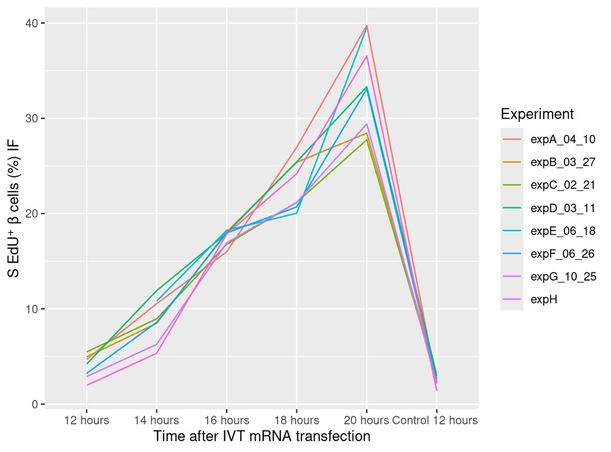

Mean proportion of S-phase EdU⁺ β cells (% by immunofluorescence) at different time points after IVT mRNA transfection and across individual experiments

```r
data_long %>% filter(grepl('S_phase_IF', Table)) %>%
  ggplot(
    aes(x = Time, y = Proportion, group = Experiment, color = Experiment)
    ) +
  geom_line() +
  scale_y_continuous(
    name = "S EdU⁺ β cells (%) IF"
  ) +
  scale_x_discrete(name = "Time after IVT mRNA transfection")
## Warning: Removed 2 rows containing missing values or values outside the scale range
## (`geom_line()`).
```

$\Rightarrow$ Variances does not seem strongly different across time points, or there is at least not clear trend of increasing the variance around 50%.

## 9.2 Models

### 9.2.1 Choose model

AIC/BIC

**Open code**

```r
model_NR <- glmmTMB::glmmTMB(
  Proportion ~ Time,
  data = data_long %>%
    filter(
      grepl('S_phase_IF', Table),
      !is.na(Proportion)
    ) %>%
    mutate(Time = factor(Time)),
  REML = FALSE
)

model_RI <- glmmTMB::glmmTMB(
  Proportion ~ Time + (1 | Experiment),
  data = data_long %>%
    filter(
      grepl('S_phase_IF', Table),
      !is.na(Proportion)
    ) %>%
    mutate(Time = factor(Time)),
  REML = FALSE
)

model_NR_difvar <- glmmTMB::glmmTMB(
  Proportion ~ Time,
  data = data_long %>%
    filter(
      grepl('S_phase_IF', Table),
      !is.na(Proportion)
    ) %>%
    mutate(Time = factor(Time)),
  REML = FALSE,
  dispformula = ~ 0 + Time
)

model_RI_difvar <- glmmTMB::glmmTMB(
  Proportion ~ Time + (1 | Experiment),
  data = data_long %>%
    filter(
      grepl('S_phase_IF', Table),
      !is.na(Proportion)
    ) %>%
    mutate(Time = factor(Time)),
  REML = FALSE,
  dispformula = ~ 0 + Time
)

kableExtra::kable(AIC(model_NR, model_RI, model_NR_difvar, model_RI_difvar))
```

|  | df | AIC |
| --- | --- | --- |
| model_NR | 7 | 224.3927 |
| model_RI | 8 | 225.8025 |
| model_NR_difvar | 12 | 193.1241 |
| model_RI_difvar | 13 | 190.4496 |

**Open code**

```r
kableExtra::kable(BIC(model_NR, model_RI, model_NR_difvar, model_RI_difvar))
```

|  | df | BIC |
| --- | --- | --- |
| model_NR | 7 | 237.1932 |
| model_RI | 8 | 240.4316 |
| model_NR_difvar | 12 | 215.0678 |
| model_RI_difvar | 13 | 214.2219 |

Diagnostics

**Open code**

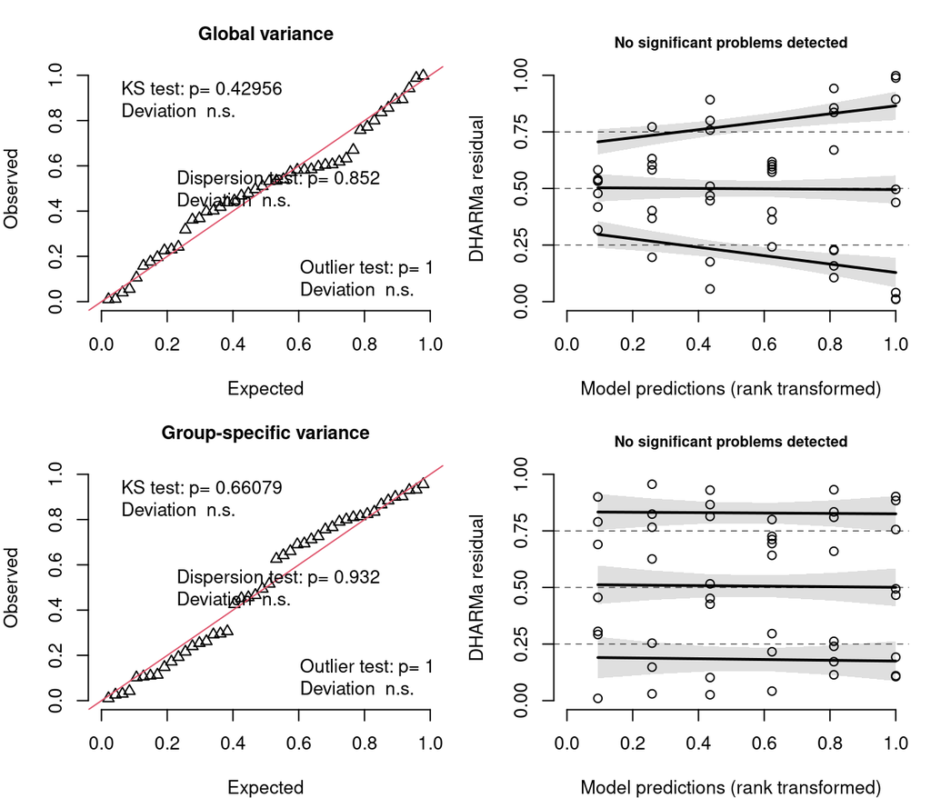

Diagnostic plots from DHARMa simulated residuals for models with and without group-specific residual variance. Top: random-intercept model with a single (global) residual variance. Bottom: random-intercept model allowing group-specific residual variance. Left: quantile–quantile plot comparing simulated residuals to the expected distribution. Right: residuals plotted against predicted values; black lines show the median (0.5) and lower/upper quartiles (0.25, 0.75) with shaded 95% simulation envelopes. Deviations from expected values suggest potential model misspecification

```r
set.seed(709)

res1 <- simulateResiduals(model_RI, n = 500)
res2 <- simulateResiduals(model_RI_difvar, n = 500)

op <- par(mfrow = c(2, 2), mar = c(4, 4, 3, 1))

plotQQunif(res1, main = "Global variance")
plotResiduals(res1, main = "")

plotQQunif(res2, main = "Group-specific variance")
plotResiduals(res2, main = "")
```

**Open code**

```r
par(op)
```

$\Rightarrow$ Allowance for group-specific residual variance decreased AIC and BIC, but diagnostics of the simpler model did not indicate problems, and the group-specific differences did not follow the typical pattern of variance peaking around 50%. We therefore retained the random-intercept model with a global residual variance.

### 9.2.2 Fit final model

**Open code**

```r
model_final <- glmmTMB::glmmTMB(
  Proportion ~ Time + (1 | Experiment),
  data = data_long %>%
    filter(
      grepl('S_phase_IF', Table),
      !is.na(Proportion)
    ),
  REML = TRUE
)
```

### 9.2.3 Results

**Open code**

```r
kableExtra::kable(car::Anova(model_final))
```

|  | Chisq | Df | Pr(>Chisq) |
| --- | --- | --- | --- |
| Time | 917.7914 | 5 | 0 |

**Open code**

```r
summary(model_final)
##  Family: gaussian  ( identity )
## Formula:          Proportion ~ Time + (1 | Experiment)
## Data: data_long %>% filter(grepl("S_phase_IF", Table), !is.na(Proportion))
##
##      AIC      BIC   logLik deviance df.resid
##    216.2    230.9   -100.1    200.2       44
##
## Random effects:
##
## Conditional model:
##  Groups     Name        Variance Std.Dev.
##  Experiment (Intercept) 0.5216   0.7222
##  Residual               6.0043   2.4504
## Number of obs: 46, groups:  Experiment, 8
##
## Dispersion estimate for gaussian family (sigma^2):    6
##
## Conditional model:
##                       Estimate Std. Error z value Pr(>|z|)
## (Intercept)             3.9682     0.9668   4.104 4.05e-05 ***
## Time14 hours            4.8931     1.2728   3.844 0.000121 ***
## Time16 hours           13.5056     1.2728  10.611  < 2e-16 ***
## Time18 hours           19.1668     1.2728  15.059  < 2e-16 ***
## Time20 hours           29.5143     1.2728  23.188  < 2e-16 ***
## TimeControl 12 hours   -1.5571     1.3098  -1.189 0.234496
## ---
## Signif. codes:  0 '***' 0.001 '**' 0.01 '*' 0.05 '.' 0.1 ' ' 1

contrast <- con_tab(model_final)

kableExtra::kable(
  contrast,
  caption = "Estimated pairwise differences in the proportion of S-phase EdU⁺ β cells (%; immunofluorescence), obtained from a linear mixed-effects model with experiment as a random intercept and time as a categorical predictor. Columns: `contrast` (time points compared), `estimate` (mean difference in %), `CI` (Bonferroni-adjusted 95% confidence interval [lower, upper]), `SE` (standard error), `df` (degrees of freedom), `t.ratio` (test statistic), `p.value` (Bonferroni-adjusted p-value), and `stars` (significance code)."
)
```

Estimated pairwise differences in the proportion of S-phase EdU⁺ β cells (%; immunofluorescence), obtained from a linear mixed-effects model with experiment as a random intercept and time as a categorical predictor. Columns: `contrast` (time points compared), `estimate` (mean difference in %), `CI` (Bonferroni-adjusted 95% confidence interval [lower, upper]), `SE` (standard error), `df` (degrees of freedom), `t.ratio` (test statistic), `p.value` (Bonferroni-adjusted p-value), and `stars` (significance code).

| contrast | estimate | CI | SE | df | t.ratio | p.value | stars |
| --- | --- | --- | --- | --- | --- | --- | --- |
| 12 hours - 14 hours | -4.89 | [-8.84, -0.94] | 1.27 | 44 | -3.84 | 0.0057814 | ** |
| 12 hours - 16 hours | -13.51 | [-17.46, -9.55] | 1.27 | 44 | -10.61 | 0.0000000 | *** |
| 12 hours - 18 hours | -19.17 | [-23.12, -15.22] | 1.27 | 44 | -15.06 | 0.0000000 | *** |
| 12 hours - 20 hours | -29.51 | [-33.47, -25.56] | 1.27 | 44 | -23.19 | 0.0000000 | *** |
| 12 hours - Control 12 hours | 1.56 | [-2.51, 5.62] | 1.31 | 44 | 1.19 | 1.0000000 | ns |
| 14 hours - 16 hours | -8.61 | [-12.42, -4.81] | 1.23 | 44 | -7.03 | 0.0000002 | *** |
| 14 hours - 18 hours | -14.27 | [-18.08, -10.47] | 1.23 | 44 | -11.65 | 0.0000000 | *** |
| 14 hours - 20 hours | -24.62 | [-28.42, -20.82] | 1.23 | 44 | -20.10 | 0.0000000 | *** |
| 14 hours - Control 12 hours | 6.45 | [2.50, 10.40] | 1.27 | 44 | 5.07 | 0.0001156 | *** |
| 16 hours - 18 hours | -5.66 | [-9.46, -1.86] | 1.23 | 44 | -4.62 | 0.0005005 | *** |
| 16 hours - 20 hours | -16.01 | [-19.81, -12.21] | 1.23 | 44 | -13.07 | 0.0000000 | *** |
| 16 hours - Control 12 hours | 15.06 | [11.11, 19.01] | 1.27 | 44 | 11.83 | 0.0000000 | *** |
| 18 hours - 20 hours | -10.35 | [-14.15, -6.54] | 1.23 | 44 | -8.45 | 0.0000000 | *** |
| 18 hours - Control 12 hours | 20.72 | [16.77, 24.67] | 1.27 | 44 | 16.28 | 0.0000000 | *** |
| 20 hours - Control 12 hours | 31.07 | [27.12, 35.02] | 1.27 | 44 | 24.41 | 0.0000000 | *** |

### 9.2.4 Visualisation

**Open code**

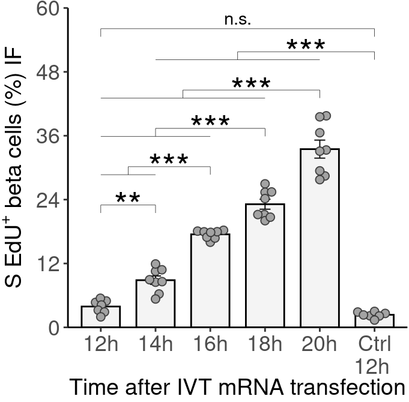

Proportion of S-phase EdU⁺ beta cells (% by immunofluorescence) at different time points after IVT mRNA transfection. Bars show means ± SEM. ***, P < 0.001; **, P < 0.01; *, P < 0.05(adjusted P-values by Bonferroni correction). Statistical significance was assessed with linear mixed-effects model, including experiment as a random effect and time as a categorical predictor

```r
scale <- 10/6

p <- data_long %>%
  filter(
      grepl('S_phase_IF', Table),
      !is.na(Proportion)
    ) %>%
  mutate(
    Time = factor(Time,
                  levels = unique(Time),
                  labels = gsub(" hour[s]?", "h", gsub("Control", "Ctrl", unique(Time)))
                  )
    ) %>%
  ggplot(
    aes(x = Time, y = Proportion)
  ) +
  stat_summary(
    fun = 'mean',
    geom = 'col',
    fill = 'grey80', color = 'black',
    width = 0.7,
    alpha = 0.2
  ) +
  stat_summary(fun.data = mean_se, geom = "errorbar",
               width = 0.2, linewidth = 0.324) +
  scale_y_continuous(
    breaks = seq(0, 100/scale, 20/scale),
    name = expression("S EdU"^"+"~"beta cells (%) IF"),
    expand = expansion(mult = c(0, 0), add = c(0, 0))
  ) +
  coord_cartesian(ylim = c(0, 100/scale)) +
  scale_x_discrete(name = "Time after IVT mRNA transfection",
    labels = function(x) gsub("Ctrl (.*)", "Ctrl\n\\1", x)) +
  geom_beeswarm(
    cex = 2,
    fill = 'grey64',
    size = 2.13,
    shape = 21,
    color = rgb(0.2, 0.2, 0.2, 0.9),
    stroke = 0.5
  ) +
  theme_classic() +
  theme(
    plot.margin = margin(t = 5, r = 1, b = 1, l = 1),
    axis.text.x = element_text(size = ax_text1),
    axis.text.y = element_text(size = ax_text1),
    axis.title.x = element_text(size = tit_text1, margin = margin(t = mar1)),
    axis.title.y = element_text(size = tit_text1)
  )

start <- 95/scale
tr <- 0
byp <- 12/scale

p <- add_starm(6, 1, start - tr, '<sup>n.s.</sup>', scal = scale);
tr <-  tr + byp*0.6
p <- add_starm(6, c(2:5), start - tr, '***', scal = scale); tr <-  tr + byp
p <- add_starm(5, c(1:4), start - tr, '***', scal = scale); tr <-  tr + byp
p <- add_starm(4, c(1:3), start - tr, '***', scal = scale); tr <-  tr + byp
p <- add_starm(3, c(1:2), start - tr, '***', scal = scale); tr <-  tr + byp
p <- add_starm(1, 2, start - tr, '**', scal = scale); tr <-  tr + byp

p
```

**Open code**

```r
if (!file.exists("gitignore/figures/fig_07.pdf")) {
  ggsave("gitignore/figures/fig_07.pdf", plot = p, width = figw1, height = figh1, units = "in")
  ggsave("gitignore/figures/fig_07.svg", plot = p, width = figw1, height = figh1, units = "in")
  }
```

### 9.2.5 Summary statistics over timpoints

**Open code**

```r
kableExtra::kable(
  data_long %>%
    dplyr::filter(grepl("S_phase_IF", Table)) %>%
    tidyr::drop_na(Proportion) %>%
    dplyr::group_by(Time) %>%
    dplyr::summarise(
      mean = mean(Proportion),
      median = quantile(Proportion, probs = 0.5),
      SD = sd(Proportion),
      SEM = sem(Proportion)
    ),
  caption = "Summary statistics for the proportion of S-phase EdU⁺ beta cells (% by immunofluorescence) at different time points after IVT mRNA transfection. Mean, median, SD, and SEM are shown; SD, standard deviation; SEM, standard error of the mean"
)
```

Summary statistics for the proportion of S-phase EdU⁺ beta cells (% by immunofluorescence) at different time points after IVT mRNA transfection. Mean, median, SD, and SEM are shown; SD, standard deviation; SEM, standard error of the mean

| Time | mean | median | SD | SEM |
| --- | --- | --- | --- | --- |
| 12 hours | 3.915714 | 4.20 | 1.2579594 | 0.4754640 |
| 14 hours | 8.861250 | 8.77 | 2.2475665 | 0.7946348 |
| 16 hours | 17.473750 | 17.90 | 0.8063133 | 0.2850748 |
| 18 hours | 23.135000 | 22.69 | 2.6514147 | 0.9374167 |
| 20 hours | 33.482500 | 33.21 | 4.7894191 | 1.6933154 |
| Control 12 hours | 2.358571 | 2.33 | 0.5497099 | 0.2077708 |

# 10 S CA2 IF

## 10.1 Show Data

**Open code**

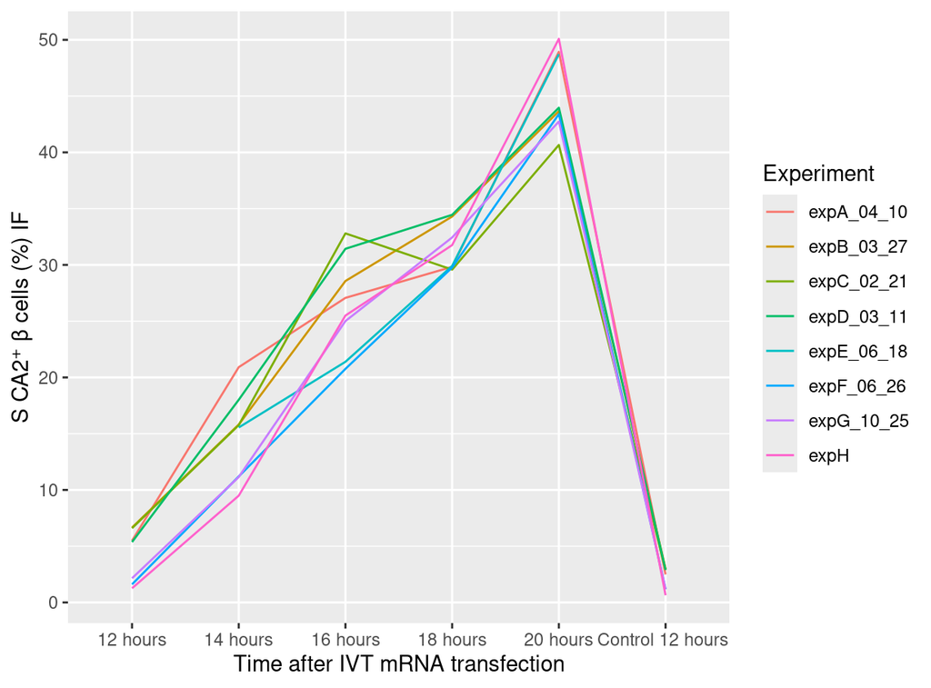

Mean proportion of S-phase CA2⁺ β cells (% by immunofluorescence) at different time points after IVT mRNA transfection and across individual experiments

```r
data_long %>% filter(grepl('S_CA2_IF', Table)) %>%
  ggplot(
    aes(x = Time, y = Proportion, group = Experiment, color = Experiment)
    ) +
  geom_line() +
  scale_y_continuous(
    name = "S CA2⁺ β cells (%) IF"
  ) +
  scale_x_discrete(name = "Time after IVT mRNA transfection")
## Warning: Removed 2 rows containing missing values or values outside the scale range
## (`geom_line()`).
```

$\Rightarrow$ Variances seems similar across time-points, with possile exception of control

## 10.2 Models

### 10.2.1 Choose model

AIC/BIC

**Open code**

```r
model_NR <- glmmTMB::glmmTMB(
  Proportion ~ Time,
  data = data_long %>%
    filter(
      grepl('S_CA2_IF', Table),
      !is.na(Proportion)
    ) %>%
    mutate(Time = factor(Time)),
  REML = FALSE
)

model_RI <- glmmTMB::glmmTMB(
  Proportion ~ Time + (1 | Experiment),
  data = data_long %>%
    filter(
      grepl('S_CA2_IF', Table),
      !is.na(Proportion)
    ) %>%
    mutate(Time = factor(Time)),
  REML = FALSE
)

model_NR_difvar <- glmmTMB::glmmTMB(
  Proportion ~ Time,
  data = data_long %>%
    filter(
      grepl('S_CA2_IF', Table),
      !is.na(Proportion)
    ) %>%
    mutate(Time = factor(Time)),
  REML = FALSE,
  dispformula = ~ 0 + Time
)

model_RI_difvar <- glmmTMB::glmmTMB(
  Proportion ~ Time + (1 | Experiment),
  data = data_long %>%
    filter(
      grepl('S_CA2_IF', Table),
      !is.na(Proportion)
    ) %>%
    mutate(Time = factor(Time)),
  REML = FALSE,
  dispformula = ~ 0 + Time
)

kableExtra::kable(AIC(model_NR, model_RI, model_NR_difvar, model_RI_difvar))
```

|  | df | AIC |
| --- | --- | --- |
| model_NR | 7 | 242.7953 |
| model_RI | 8 | 242.3897 |
| model_NR_difvar | 12 | 236.7489 |
| model_RI_difvar | 13 | 227.8279 |

**Open code**

```r
kableExtra::kable(BIC(model_NR, model_RI, model_NR_difvar, model_RI_difvar))
```

|  | df | BIC |
| --- | --- | --- |
| model_NR | 7 | 255.5958 |
| model_RI | 8 | 257.0189 |
| model_NR_difvar | 12 | 258.6926 |
| model_RI_difvar | 13 | 251.6002 |

Diagnostics

**Open code**

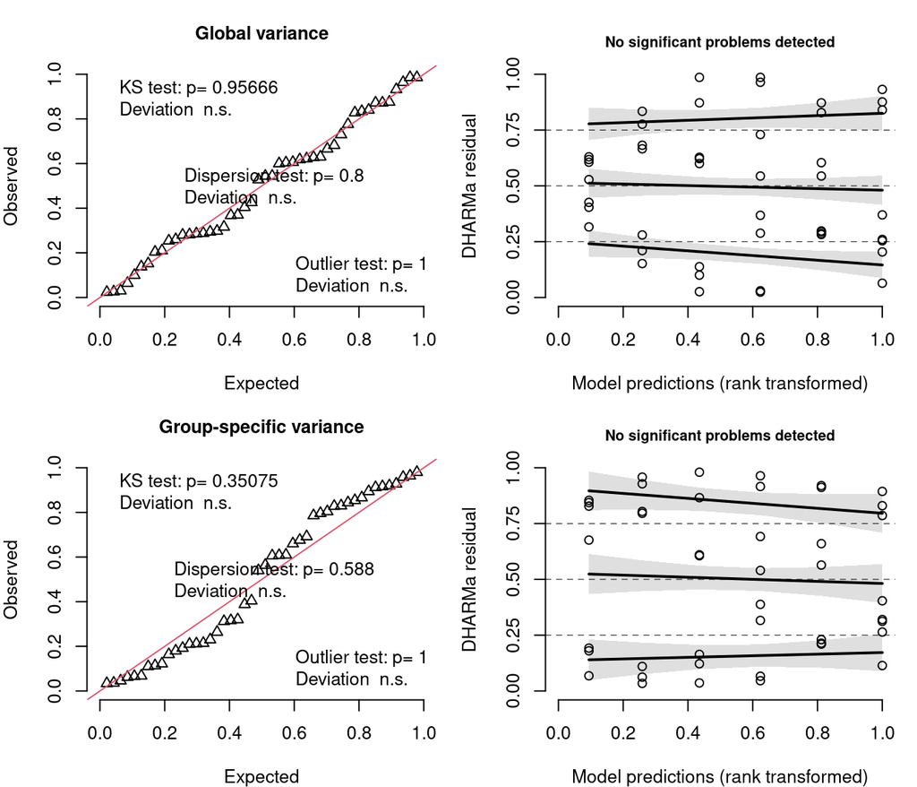

Diagnostic plots from DHARMa simulated residuals for models with and without group-specific residual variance. Top: random-intercept model with a single (global) residual variance. Bottom: random-intercept model allowing group-specific residual variance. Left: quantile–quantile plot comparing simulated residuals to the expected distribution. Right: residuals plotted against predicted values; black lines show the median (0.5) and lower/upper quartiles (0.25, 0.75) with shaded 95% simulation envelopes. Deviations from expected values suggest potential model misspecification

```r
set.seed(709)

res1 <- simulateResiduals(model_RI, n = 500)
res2 <- simulateResiduals(model_RI_difvar, n = 500)

op <- par(mfrow = c(2, 2), mar = c(4, 4, 3, 1))

plotQQunif(res1, main = "Global variance")
plotResiduals(res1, main = "")

plotQQunif(res2, main = "Group-specific variance")
plotResiduals(res2, main = "")
```

**Open code**

```r
par(op)
```

### 10.2.2 Fit final model

**Open code**

```r
model_final <- glmmTMB::glmmTMB(
  Proportion ~ Time + (1 | Experiment),
  data = data_long %>%
    filter(
      grepl('S_CA2_IF', Table),
      !is.na(Proportion)
    ),
  REML = TRUE
)
```

### 10.2.3 Results

**Open code**

```r
kableExtra::kable(car::Anova(model_final))
```

|  | Chisq | Df | Pr(>Chisq) |
| --- | --- | --- | --- |
| Time | 1301.748 | 5 | 0 |

**Open code**

```r
summary(model_final)
##  Family: gaussian  ( identity )
## Formula:          Proportion ~ Time + (1 | Experiment)
## Data: data_long %>% filter(grepl("S_CA2_IF", Table), !is.na(Proportion))
##
##      AIC      BIC   logLik deviance df.resid
##    230.7    245.3   -107.3    214.7       44
##
## Random effects:
##
## Conditional model:
##  Groups     Name        Variance Std.Dev.
##  Experiment (Intercept) 1.608    1.268
##  Residual               8.095    2.845
## Number of obs: 46, groups:  Experiment, 8
##
## Dispersion estimate for gaussian family (sigma^2): 8.09
##
## Conditional model:
##                       Estimate Std. Error z value Pr(>|z|)
## (Intercept)              4.123      1.172   3.518 0.000435 ***
## Time14 hours            10.612      1.478   7.179 7.02e-13 ***
## Time16 hours            22.443      1.478  15.183  < 2e-16 ***
## Time18 hours            27.382      1.478  18.525  < 2e-16 ***
## Time20 hours            41.150      1.478  27.839  < 2e-16 ***
## TimeControl 12 hours    -2.130      1.521  -1.401 0.161342
## ---
## Signif. codes:  0 '***' 0.001 '**' 0.01 '*' 0.05 '.' 0.1 ' ' 1

contrast <- con_tab(model_final)

kableExtra::kable(
  contrast,
  caption = "Estimated pairwise differences in the proportion of S-phase CA2⁺ β cells (%; immunofluorescence), obtained from a linear mixed-effects model with experiment as a random intercept and time as a categorical predictor. Columns: `contrast` (time points compared), `estimate` (mean difference in %), `CI` (Bonferroni-adjusted 95% confidence interval [lower, upper]), `SE` (standard error), `df` (degrees of freedom), `t.ratio` (test statistic), `p.value` (Bonferroni-adjusted p-value), and `stars` (significance code)."
)
```

Estimated pairwise differences in the proportion of S-phase CA2⁺ β cells (%; immunofluorescence), obtained from a linear mixed-effects model with experiment as a random intercept and time as a categorical predictor. Columns: `contrast` (time points compared), `estimate` (mean difference in %), `CI` (Bonferroni-adjusted 95% confidence interval [lower, upper]), `SE` (standard error), `df` (degrees of freedom), `t.ratio` (test statistic), `p.value` (Bonferroni-adjusted p-value), and `stars` (significance code).

| contrast | estimate | CI | SE | df | t.ratio | p.value | stars |
| --- | --- | --- | --- | --- | --- | --- | --- |
| 12 hours - 14 hours | -10.61 | [-15.20, -6.02] | 1.48 | 44 | -7.18 | 0.0000001 | *** |
| 12 hours - 16 hours | -22.44 | [-27.03, -17.85] | 1.48 | 44 | -15.18 | 0.0000000 | *** |
| 12 hours - 18 hours | -27.38 | [-31.97, -22.79] | 1.48 | 44 | -18.52 | 0.0000000 | *** |
| 12 hours - 20 hours | -41.15 | [-45.74, -36.56] | 1.48 | 44 | -27.84 | 0.0000000 | *** |
| 12 hours - Control 12 hours | 2.13 | [-2.59, 6.85] | 1.52 | 44 | 1.40 | 1.0000000 | ns |
| 14 hours - 16 hours | -11.83 | [-16.25, -7.42] | 1.42 | 44 | -8.32 | 0.0000000 | *** |
| 14 hours - 18 hours | -16.77 | [-21.19, -12.35] | 1.42 | 44 | -11.79 | 0.0000000 | *** |
| 14 hours - 20 hours | -30.54 | [-34.95, -26.12] | 1.42 | 44 | -21.47 | 0.0000000 | *** |
| 14 hours - Control 12 hours | 12.74 | [8.15, 17.33] | 1.48 | 44 | 8.62 | 0.0000000 | *** |
| 16 hours - 18 hours | -4.94 | [-9.35, -0.52] | 1.42 | 44 | -3.47 | 0.0175754 | * |
| 16 hours - 20 hours | -18.71 | [-23.12, -14.29] | 1.42 | 44 | -13.15 | 0.0000000 | *** |
| 16 hours - Control 12 hours | 24.57 | [19.98, 29.16] | 1.48 | 44 | 16.62 | 0.0000000 | *** |
| 18 hours - 20 hours | -13.77 | [-18.18, -9.35] | 1.42 | 44 | -9.68 | 0.0000000 | *** |
| 18 hours - Control 12 hours | 29.51 | [24.92, 34.10] | 1.48 | 44 | 19.97 | 0.0000000 | *** |
| 20 hours - Control 12 hours | 43.28 | [38.69, 47.87] | 1.48 | 44 | 29.28 | 0.0000000 | *** |

#### 10.2.3.1 Look at alternative results, when group-specific sigma was allowed

(click on ‘Open Code’ to see results)

**Open code**

```r
con_tab(model_RI_difvar)
## # A tibble: 15 × 8
##    contrast                    estimate CI       SE    df t.ratio  p.value stars
##    <chr>                          <dbl> <chr> <dbl> <dbl>   <dbl>    <dbl> <chr>
##  1 "12 hours - 14 hours"         -10.6  [-14…  1.16    33   -9.12 2.31e- 9 ***
##  2 "12 hours - 16 hours"         -22.4  [-26…  1.32    33  -17.0  1.05e-16 ***
##  3 "12 hours - 18 hours"         -27.4  [-30…  0.84    33  -32.4  1.93e-25 ***
##  4 "12 hours - 20 hours"         -41.2  [-45…  1.4     33  -29.4  4.62e-24 ***
##  5 "12 hours - Control 12 hou…     2.13 [0.5…  0.5     33    4.25 2.44e- 3 **
##  6 "14 hours - 16 hours"         -11.8  [-16…  1.61    33   -7.37 2.74e- 7 ***
##  7 "14 hours - 18 hours"         -16.8  [-20…  1.24    33  -13.5  8.16e-14 ***
##  8 "14 hours - 20 hours"         -30.5  [-35…  1.67    33  -18.3  1.19e-17 ***
##  9 "14 hours - Control 12 hou…    12.8  [9.4…  1.05    33   12.1  1.56e-12 ***
## 10 "16 hours - 18 hours"          -4.94 [-9.…  1.39    33   -3.55 1.77e- 2 *
## 11 "16 hours - 20 hours"         -18.7  [-24…  1.78    33  -10.5  7.34e-11 ***
## 12 "16 hours - Control 12 hou…    24.6  [20.…  1.22    33   20.1  6.56e-19 ***
## 13 "18 hours - 20 hours"         -13.8  [-18…  1.47    33   -9.39 1.15e- 9 ***
## 14 "18 hours - Control 12 hou…    29.5  [27.…  0.68    33   43.4  1.58e-29 ***
## 15 "20 hours - Control 12 hou…    43.3  [39.…  1.31    33   33.1  1.04e-25 ***
```

### 10.2.4 Visualisation

**Open code**

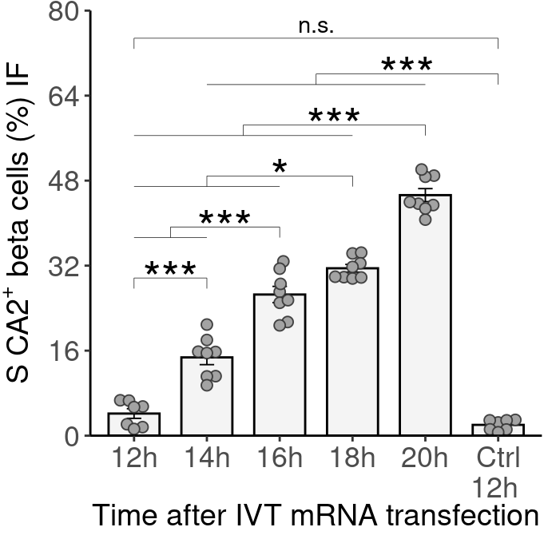

Proportion of S-phase CA2⁺ beta cells (% by immunofluorescence) at different time points after IVT mRNA transfection. Bars show means ± SEM. ***, P < 0.001; **, P < 0.01; *, P < 0.05(adjusted P-values by Bonferroni correction). Statistical significance was assessed with linear mixed-effects model, including experiment as a random effect and time as a categorical predictor

```r
scale <- 10/8

p <- data_long %>%
  filter(
      grepl('S_CA2_IF', Table),
      !is.na(Proportion)
    ) %>%
  mutate(
    Time = factor(Time,
                  levels = unique(Time),
                  labels = gsub(" hour[s]?", "h", gsub("Control", "Ctrl", unique(Time)))
                  )
    ) %>%
  ggplot(
    aes(x = Time, y = Proportion)
  ) +
  stat_summary(
    fun = 'mean',
    geom = 'col',
    fill = 'grey80', color = 'black',
    width = 0.7,
    alpha = 0.2
  ) +
  stat_summary(fun.data = mean_se, geom = "errorbar", width = 0.2, linewidth = 0.324) +
  scale_y_continuous(
    breaks = seq(0, 100/scale, 20/scale),
    name = expression("S CA2"^"+"~"beta cells (%) IF"),
    expand = expansion(mult = c(0, 0), add = c(0, 0))
  ) +
  coord_cartesian(ylim = c(0, 100/scale)) +
  scale_x_discrete(name = "Time after IVT mRNA transfection",
    labels = function(x) gsub("Ctrl (.*)", "Ctrl\n\\1", x)) +
  geom_beeswarm(
    cex = 2,
    fill = 'grey64',
    size = 2.13,
    shape = 21,
    color = rgb(0.2, 0.2, 0.2, 0.9),
    stroke = 0.5
  ) +
  theme_classic() +
  theme(
    plot.margin = margin(t = 5, r = 1, b = 1, l = 1),
    axis.text.x = element_text(size = ax_text1),
    axis.text.y = element_text(size = ax_text1),
    axis.title.x = element_text(size = tit_text1, margin = margin(t = mar1)),
    axis.title.y = element_text(size = tit_text1)
  )

start <- 95/scale
tr <- 0
byp <- 12/scale


p <- add_starm(1, 6, start - tr, '<sup>n.s.</sup>', scal = scale); tr <-  tr + byp*0.7
p <- add_starm(6, c(2:5), start - tr, '***', scal = scale); tr <-  tr + byp
p <- add_starm(5, c(1:4), start - tr, '***', scal = scale); tr <-  tr + byp
p <- add_starm(4, c(1:3), start - tr, '*', scal = scale); tr <-  tr + byp
p <- add_starm(3, c(1:2), start - tr, '***', scal = scale); tr <-  tr + byp
p <- add_starm(2, 1, start - tr, '***', scal = scale); tr <-  tr + byp

p
```

**Open code**

```r
if (!file.exists("gitignore/figures/fig_08.pdf")) {
  ggsave("gitignore/figures/fig_08.pdf", plot = p, width = figw1, height = figh1, units = "in")
  ggsave("gitignore/figures/fig_08.svg", plot = p, width = figw1, height = figh1, units = "in")
  }
```

### 10.2.5 Summary statistics over timpoints

**Open code**

```r
kableExtra::kable(
  data_long %>%
    dplyr::filter(grepl("S_CA2_IF", Table)) %>%
    tidyr::drop_na(Proportion) %>%
    dplyr::group_by(Time) %>%
    dplyr::summarise(
      mean = mean(Proportion),
      median = quantile(Proportion, probs = 0.5),
      SD = sd(Proportion),
      SEM = sem(Proportion)
    ),
  caption = "Summary statistics for the proportion of S-phase CA2⁺ beta cells (% by immunofluorescence) at different time points after IVT mRNA transfection. Mean, median, SD, and SEM are shown; SD, standard deviation; SEM, standard error of the mean"
)
```

Summary statistics for the proportion of S-phase CA2⁺ beta cells (% by immunofluorescence) at different time points after IVT mRNA transfection. Mean, median, SD, and SEM are shown; SD, standard deviation; SEM, standard error of the mean

| Time | mean | median | SD | SEM |
| --- | --- | --- | --- | --- |
| 12 hours | 4.162857 | 5.370 | 2.3940601 | 0.9048697 |
| 14 hours | 14.735000 | 15.655 | 3.8653257 | 1.3665990 |
| 16 hours | 26.566250 | 26.285 | 4.3235136 | 1.5285929 |
| 18 hours | 31.505000 | 30.835 | 2.0525176 | 0.7256746 |
| 20 hours | 45.273750 | 43.815 | 3.4662616 | 1.2255085 |
| Control 12 hours | 2.032857 | 2.490 | 0.9974085 | 0.3769850 |

# 11 G2M phase FC

## 11.1 Show Data

**Open code**

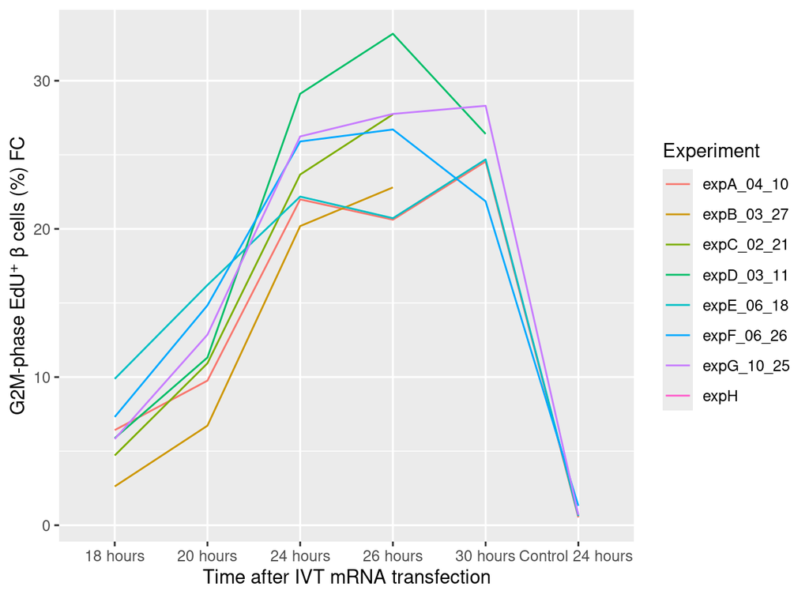

Mean proportion of G2M-phase EdU⁺ β cells (% by flow cytometry) at different time points after IVT mRNA transfection and across individual experiments

```r
data_long %>% filter(grepl('G2M_phase_FC', Table)) %>%
  ggplot(
    aes(x = Time, y = Proportion, group = Experiment, color = Experiment)
    ) +
  geom_line() +
  scale_y_continuous(
    name = "G2M-phase EdU⁺ β cells (%) FC"
  ) +
  scale_x_discrete(name = "Time after IVT mRNA transfection")
## Warning: Removed 7 rows containing missing values or values outside the scale range
## (`geom_line()`).
```

$\Rightarrow$ Variances do not seem to markedly differ acros groups

## 11.2 Models

### 11.2.1 Choose model

AIC/BIC

**Open code**

```r
model_NR <- glmmTMB::glmmTMB(
  Proportion ~ Time,
  data = data_long %>%
    filter(
      grepl('G2M_phase_FC', Table),
      !is.na(Proportion)
    ) %>%
    mutate(Time = factor(Time)),
  REML = FALSE
)

model_RI <- glmmTMB::glmmTMB(
  Proportion ~ Time + (1 | Experiment),
  data = data_long %>%
    filter(
      grepl('G2M_phase_FC', Table),
      !is.na(Proportion)
    ) %>%
    mutate(Time = factor(Time)),
  REML = FALSE
)

model_NR_difvar <- glmmTMB::glmmTMB(
  Proportion ~ Time,
  data = data_long %>%
    filter(
      grepl('G2M_phase_FC', Table),
      !is.na(Proportion)
    ) %>%
    mutate(Time = factor(Time)),
  REML = FALSE,
  dispformula = ~ 0 + Time
)

model_RI_difvar <- glmmTMB::glmmTMB(
  Proportion ~ Time + (1 | Experiment),
  data = data_long %>%
    filter(
      grepl('G2M_phase_FC', Table),
      !is.na(Proportion)
    ) %>%
    mutate(Time = factor(Time)),
  REML = FALSE,
  dispformula = ~ 0 + Time
)

kableExtra::kable(AIC(model_NR, model_RI, model_NR_difvar, model_RI_difvar))
```

|  | df | AIC |
| --- | --- | --- |
| model_NR | 7 | 203.5783 |
| model_RI | 8 | 202.0658 |
| model_NR_difvar | 12 | 185.9266 |
| model_RI_difvar | 13 | 187.9266 |

**Open code**

```r
kableExtra::kable(BIC(model_NR, model_RI, model_NR_difvar, model_RI_difvar))
```

|  | df | BIC |
| --- | --- | --- |
| model_NR | 7 | 215.2232 |
| model_RI | 8 | 215.3743 |
| model_NR_difvar | 12 | 205.8893 |
| model_RI_difvar | 13 | 209.5529 |

Diagnostics

**Open code**

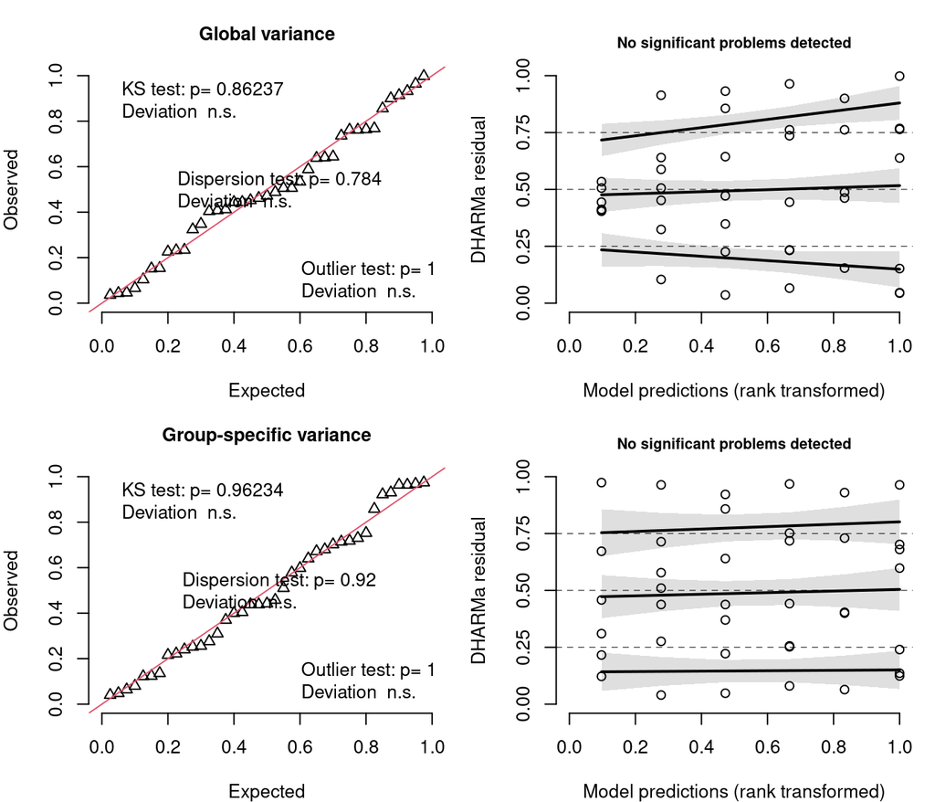

Diagnostic plots from DHARMa simulated residuals for models with and without group-specific residual variance. Top: random-intercept model with a single (global) residual variance. Bottom: random-intercept model allowing group-specific residual variance. Left: quantile–quantile plot comparing simulated residuals to the expected distribution. Right: residuals plotted against predicted values; black lines show the median (0.5) and lower/upper quartiles (0.25, 0.75) with shaded 95% simulation envelopes. Deviations from expected values suggest potential model misspecification

```r
set.seed(709)

res1 <- simulateResiduals(model_RI, n = 500)
res2 <- simulateResiduals(model_RI_difvar, n = 500)

op <- par(mfrow = c(2, 2), mar = c(4, 4, 3, 1))

plotQQunif(res1, main = "Global variance")
plotResiduals(res1, main = "")

plotQQunif(res2, main = "Group-specific variance")
plotResiduals(res2, main = "")
```

**Open code**

```r
par(op)
```

$\Rightarrow$ Only the random-intercept model and the simplest model without random effects converged without issues. Both had comparable AIC and BIC. Will use our default – random intercept model.

### 11.2.2 Fit final model

**Open code**

```r
model_final <- glmmTMB::glmmTMB(
  Proportion ~ Time + (1 | Experiment),
  data = data_long %>%
    filter(
      grepl('G2M_phase_FC', Table),
      !is.na(Proportion)
    ),
  REML = TRUE
)
```

### 11.2.3 Results

**Open code**

```r
kableExtra::kable(car::Anova(model_final))
```

|  | Chisq | Df | Pr(>Chisq) |
| --- | --- | --- | --- |
| Time | 526.0511 | 5 | 0 |

**Open code**

```r
summary(model_final)
##  Family: gaussian  ( identity )
## Formula:          Proportion ~ Time + (1 | Experiment)
## Data: data_long %>% filter(grepl("G2M_phase_FC", Table), !is.na(Proportion))
##
##      AIC      BIC   logLik deviance df.resid
##    190.2    203.5    -87.1    174.2       37
##
## Random effects:
##
## Conditional model:
##  Groups     Name        Variance Std.Dev.
##  Experiment (Intercept) 2.302    1.517
##  Residual               6.748    2.598
## Number of obs: 39, groups:  Experiment, 7
##
## Dispersion estimate for gaussian family (sigma^2): 6.75
##
## Conditional model:
##                       Estimate Std. Error z value Pr(>|z|)
## (Intercept)              6.091      1.137   5.357 8.45e-08 ***
## Time20 hours             5.714      1.389   4.115 3.87e-05 ***
## Time24 hours            18.093      1.389  13.030  < 2e-16 ***
## Time26 hours            19.553      1.389  14.082  < 2e-16 ***
## Time30 hours            18.655      1.546  12.070  < 2e-16 ***
## TimeControl 24 hours    -4.996      1.456  -3.430 0.000603 ***
## ---
## Signif. codes:  0 '***' 0.001 '**' 0.01 '*' 0.05 '.' 0.1 ' ' 1

contrast <- con_tab(model_final)

kableExtra::kable(
  contrast,
  caption = "Estimated pairwise differences in the proportion of G2M-phase EdU⁺ β cells (%; flow cytometry), obtained from a linear mixed-effects model with experiment as a random intercept and time as a categorical predictor. Columns: `contrast` (time points compared), `estimate` (mean difference in %), `CI` (Bonferroni-adjusted 95% confidence interval [lower, upper]), `SE` (standard error), `df` (degrees of freedom), `t.ratio` (test statistic), `p.value` (Bonferroni-adjusted p-value), and `stars` (significance code)."
)
```

Estimated pairwise differences in the proportion of G2M-phase EdU⁺ β cells (%; flow cytometry), obtained from a linear mixed-effects model with experiment as a random intercept and time as a categorical predictor. Columns: `contrast` (time points compared), `estimate` (mean difference in %), `CI` (Bonferroni-adjusted 95% confidence interval [lower, upper]), `SE` (standard error), `df` (degrees of freedom), `t.ratio` (test statistic), `p.value` (Bonferroni-adjusted p-value), and `stars` (significance code).

| contrast | estimate | CI | SE | df | t.ratio | p.value | stars |
| --- | --- | --- | --- | --- | --- | --- | --- |
| 18 hours - 20 hours | -5.71 | [-10.07, -1.36] | 1.39 | 37 | -4.12 | 0.0031102 | ** |
| 18 hours - 24 hours | -18.09 | [-22.45, -13.74] | 1.39 | 37 | -13.03 | 0.0000000 | *** |
| 18 hours - 26 hours | -19.55 | [-23.91, -15.20] | 1.39 | 37 | -14.08 | 0.0000000 | *** |
| 18 hours - 30 hours | -18.66 | [-23.51, -13.81] | 1.55 | 37 | -12.07 | 0.0000000 | *** |
| 18 hours - Control 24 hours | 5.00 | [0.43, 9.57] | 1.46 | 37 | 3.43 | 0.0224436 | * |
| 20 hours - 24 hours | -12.38 | [-16.74, -8.02] | 1.39 | 37 | -8.91 | 0.0000000 | *** |
| 20 hours - 26 hours | -13.84 | [-18.20, -9.48] | 1.39 | 37 | -9.97 | 0.0000000 | *** |
| 20 hours - 30 hours | -12.94 | [-17.79, -8.09] | 1.55 | 37 | -8.37 | 0.0000000 | *** |
| 20 hours - Control 24 hours | 10.71 | [6.14, 15.28] | 1.46 | 37 | 7.35 | 0.0000001 | *** |
| 24 hours - 26 hours | -1.46 | [-5.82, 2.90] | 1.39 | 37 | -1.05 | 1.0000000 | ns |
| 24 hours - 30 hours | -0.56 | [-5.41, 4.29] | 1.55 | 37 | -0.36 | 1.0000000 | ns |
| 24 hours - Control 24 hours | 23.09 | [18.52, 27.66] | 1.46 | 37 | 15.85 | 0.0000000 | *** |
| 26 hours - 30 hours | 0.90 | [-3.95, 5.75] | 1.55 | 37 | 0.58 | 1.0000000 | ns |
| 26 hours - Control 24 hours | 24.55 | [19.98, 29.12] | 1.46 | 37 | 16.86 | 0.0000000 | *** |
| 30 hours - Control 24 hours | 23.65 | [18.56, 28.75] | 1.62 | 37 | 14.57 | 0.0000000 | *** |

### 11.2.4 Visualisation

**Open code**

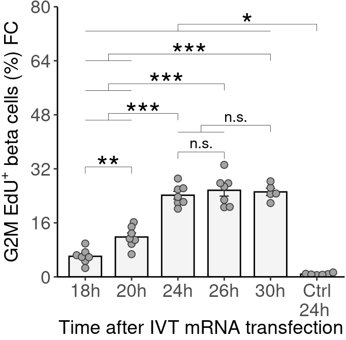

Proportion of G2M-phase EdU⁺ beta cells (% by flow cytometry) at different time points after IVT mRNA transfection. Bars show means ± SEM. ***, P < 0.001; **, P < 0.01; *, P < 0.05(adjusted P-values by Bonferroni correction). Statistical significance was assessed with linear mixed-effects model, including experiment as a random effect and time as a categorical predictor

```r
scale <- 10/8

p <- data_long %>%
  filter(
      grepl('G2M_phase_FC', Table),
      !is.na(Proportion)
    ) %>%
  mutate(
    Time = factor(Time,
                  levels = unique(Time),
                  labels = gsub(" hour[s]?", "h", gsub("Control", "Ctrl", unique(Time)))
                  )
    ) %>%
  ggplot(
    aes(x = Time, y = Proportion)
  ) +
  stat_summary(
    fun = 'mean',
    geom = 'col',
    fill = 'grey80', color = 'black',
    width = 0.7,
    alpha = 0.2
  ) +
  stat_summary(fun.data = mean_se, geom = "errorbar", width = 0.2, linewidth = 0.324) +
  scale_y_continuous(
    breaks = seq(0, 100/scale, 20/scale),
    name = expression("G2M EdU"^"+"~"beta cells (%) FC"),
    expand = expansion(mult = c(0, 0), add = c(0, 0))
  ) +
  coord_cartesian(ylim = c(0, 100/scale)) +
  scale_x_discrete(name = "Time after IVT mRNA transfection",
    labels = function(x) gsub("Ctrl (.*)", "Ctrl\n\\1", x)) +
  geom_beeswarm(
    cex = 2,
    fill = 'grey64',
    size = 2.13,
    shape = 21,
    color = rgb(0.2, 0.2, 0.2, 0.9),
    stroke = 0.5
  ) +
  theme_classic() +
  theme(
    plot.margin = margin(t = 5, r = 1, b = 1, l = 1),
    axis.text.x = element_text(size = ax_text1),
    axis.text.y = element_text(size = ax_text1),
    axis.title.x = element_text(size = tit_text1, margin = margin(t = mar1)),
    axis.title.y = element_text(size = tit_text1)
  )

start <- 95/scale
tr <- 0
byp <- 11/scale

p <- add_starm(6, c(1:5), start - tr, '*', scal = scale); tr <-  tr + byp
p <- add_starm(5, c(1:2), start - tr, '***', scal = scale); tr <-  tr + byp
p <- add_starm(4, c(1:2), start - tr, '***', scal = scale); tr <-  tr + byp
p <- add_starm(3, c(1:2), start - tr, '***', scal = scale); tr <-  tr + byp*0.4
p <- add_starm(5, c(3:4), start - tr, '<sup>n.s.</sup>', scal = scale); tr <-  tr + byp*0.9
p <- add_starm(4, 3, start - tr, '<sup>n.s.</sup>', scal = scale); tr <-  tr + byp*0.5
p <- add_starm(1, 2, start - tr, '**', scal = scale)

p
```

**Open code**

```r
if (!file.exists("gitignore/figures/fig_09.pdf")) {
  ggsave("gitignore/figures/fig_09.pdf", plot = p, width = figw1, height = figh1, units = "in")
  ggsave("gitignore/figures/fig_09.svg", plot = p, width = figw1, height = figh1, units = "in")
  }
```

### 11.2.5 Summary statistics over timpoints

**Open code**

```r
kableExtra::kable(
  data_long %>%
    dplyr::filter(grepl("G2M_phase_FC", Table)) %>%
    tidyr::drop_na(Proportion) %>%
    dplyr::group_by(Time) %>%
    dplyr::summarise(
      mean = mean(Proportion),
      median = quantile(Proportion, probs = 0.5),
      SD = sd(Proportion),
      SEM = sem(Proportion)
    ),
  caption = "Summary statistics for the proportion of G2M-phase EdU⁺ beta cells (% by flow cytometry) at different time points after IVT mRNA transfection. Mean, median, SD, and SEM are shown; SD, standard deviation; SEM, standard error of the mean"
)
```

Summary statistics for the proportion of G2M-phase EdU⁺ beta cells (% by flow cytometry) at different time points after IVT mRNA transfection. Mean, median, SD, and SEM are shown; SD, standard deviation; SEM, standard error of the mean

| Time | mean | median | SD | SEM |
| --- | --- | --- | --- | --- |
| 18 hours | 6.0914286 | 5.880 | 2.2369505 | 0.8454878 |
| 20 hours | 11.8057143 | 11.320 | 3.1824616 | 1.2028574 |
| 24 hours | 24.1842857 | 23.670 | 3.0708786 | 1.1606830 |
| 26 hours | 25.6442857 | 26.710 | 4.5493694 | 1.7195000 |
| 30 hours | 25.1640000 | 24.690 | 2.3962429 | 1.0716324 |
| Control 24 hours | 0.8133333 | 0.755 | 0.2780408 | 0.1135097 |

# 12 EdU⁺ Cell cycle occupation by FC (G2M)

## 12.1 Create relavant datasets

**Open code**

```r
## to get means
data_occup <- data_long %>%
  mutate(
    Time = gsub(" hour[s]?", "h", gsub("Control", "Ctrl", Time))
  ) %>%
  filter(
    grepl('Cell_cycle_occupation2', Table)
  ) %>%
  tidyr::drop_na(Proportion) %>%
  rename(
    Population = `Name.of.population`
  ) %>%
  dplyr::select(Time, Population, Proportion) %>%
  pivot_wider(
    names_from = Population,
    values_from = Proportion,
    values_fn = mean
  ) %>%
  mutate(Other = 100 - `S EdU+` - `G0G1 EdU-` -  `G2M EdU+` - `Divided`)

data_occup
## # A tibble: 6 × 6
##   Time        `G2M EdU+` `G0G1 EdU-` `S EdU+` Divided  Other
##   <chr>            <dbl>       <dbl>    <dbl>   <dbl>  <dbl>
## 1 "18h"            6.09         69.6    22.2     1.63 0.489
## 2 "20h"           11.8          59.3    25.8     2.41 0.647
## 3 "24h"           24.2          43.4    24.3     6.80 1.29
## 4 "26h"           25.6          42.9    18.8    11.5  1.20
## 5 "30h"           25.2          36.0    11.4    25.2  2.23
## 6 "Ctrl 24h "      0.813        96.1     1.17    1.89 0.0200

## to get SEM
sem_df <- data_long %>%
  mutate(
    Time = gsub(" hour[s]?", "h", gsub("Control", "Ctrl", Time))
  ) %>%
  filter(
    grepl('Cell_cycle_occupation2', Table)
  ) %>%
  tidyr::drop_na(Proportion) %>%
  rename(Population = `Name.of.population`) %>%
  group_by(Time, Population) %>%
  summarise(sem = sd(Proportion)/sqrt(n()), .groups = "drop") %>%
  left_join(data_occup, by = "Time") %>%
  mutate(
    xmid = case_when(
      Population == "G0G1 EdU-" ~ `G0G1 EdU-`,
      Population == "S EdU+" ~ `G0G1 EdU-` + `S EdU+`,
      Population == "G2M EdU+" ~ `G0G1 EdU-` + `S EdU+` + `G2M EdU+`,
      Population == "Divided" ~ `G0G1 EdU-` + `S EdU+` + `G2M EdU+` + `Divided`,
  )
)

kableExtra::kable(sem_df %>% select(Time, Population, sem))
```

| Time | Population | sem |
| --- | --- | --- |
| 18h | Divided | 0.3145043 |
| 18h | G0G1 EdU- | 1.7419965 |
| 18h | G2M EdU+ | 0.8454878 |
| 18h | S EdU+ | 1.3798662 |
| 20h | Divided | 0.3651921 |
| 20h | G0G1 EdU- | 2.0188102 |
| 20h | G2M EdU+ | 1.2028574 |
| 20h | S EdU+ | 2.1494926 |
| 24h | Divided | 0.8931470 |
| 24h | G0G1 EdU- | 2.8467699 |
| 24h | G2M EdU+ | 1.1606830 |
| 24h | S EdU+ | 2.8504347 |
| 26h | Divided | 1.3776229 |
| 26h | G0G1 EdU- | 3.1362481 |
| 26h | G2M EdU+ | 1.7195000 |
| 26h | S EdU+ | 2.5725406 |
| 30h | Divided | 1.7993849 |
| 30h | G0G1 EdU- | 2.9418311 |
| 30h | G2M EdU+ | 1.0716324 |
| 30h | S EdU+ | 0.9174770 |
| Ctrl 24h | Divided | 0.2493547 |
| Ctrl 24h | G0G1 EdU- | 0.4183459 |
| Ctrl 24h | G2M EdU+ | 0.1135097 |
| Ctrl 24h | S EdU+ | 0.2757414 |

## 12.2 Plot

**Open code**

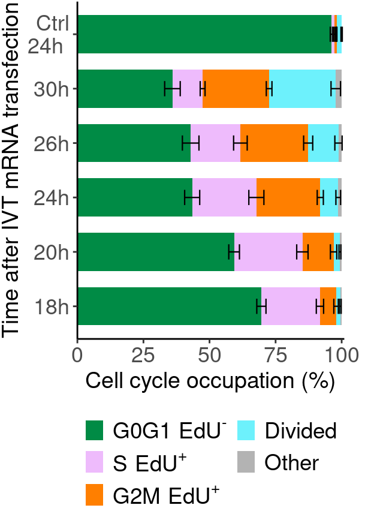

Proportion of beta cells in G0G1 EdU⁻, S EdU⁺, G2M EdU⁺, and Divided phases (% by flow cytometry) at different time points after IVT mRNA transfection. Bars show means ± SEM (for individual phases; “Other” calculated as 100% − G0G1 EdU⁻ − S EdU⁺ − G2M EdU⁺ − Divided)

```r
p <- data_occup %>%
  tidyr::pivot_longer(
    cols = c(`G0G1 EdU-`, `S EdU+`, `G2M EdU+`, `Divided`, Other),
    names_to = 'Phase',
    values_to = 'Percent'
  ) %>%
  dplyr::mutate(
    Phase = factor(
      Phase,
      levels = c('Other', 'Divided', 'G2M EdU+', 'S EdU+', 'G0G1 EdU-')
    )
  ) %>%
  ggplot(
    aes(
      y = Time,
      x = Percent,
      fill = Phase
    )
  ) +
  geom_col(width = 0.7) +
  scale_fill_manual(
    values = c(
      'G0G1 EdU-' = 'springgreen4',
      'S EdU+' = '#EEBBFC',
      'G2M EdU+' = 'darkorange1',
      'Divided' = '#6DF1FC',
      'Other' = 'grey70'
    ),
    breaks = c('G0G1 EdU-', 'S EdU+', 'G2M EdU+', 'Divided', 'Other'),
    labels = c(
  'G0G1 EdU-' = expression(G0G1~EdU^"-"),
  'S EdU+'    = expression(S~EdU^"+"),
  'G2M EdU+'  = expression(G2M~EdU^"+"),
  'Divided'   = "Divided",
  'Other'     = "Other"
),
    name = NULL
  ) +
  labs(
    x = 'Cell cycle occupation (%)',
    y = 'Time after IVT mRNA transfection'
  ) +
  scale_x_continuous(
    limits = c(0, 101),
    expand = expansion(mult = c(0, 0), add = c(0, 0))
  ) +
  scale_y_discrete(
  labels = function(x) gsub(
    "(Ctrl|\\+RO|-RO)\\s*", "\\1\n", x
    )
  ) +
  theme_classic() +
  theme(
    axis.line.y = element_line(color = 'black'),
    axis.line.x = element_line(color = 'black'),
    legend.position = 'bottom',
    plot.margin = margin(t = 1, r = 13, b = 1, l = 1),
    axis.text.x = element_text(size = ax_text4),
    axis.text.y = element_text(size = ax_text4),
    axis.title.x = element_text(size = tit_text4),
    axis.title.y = element_text(size = tit_text4),
    legend.text = element_text(size = leg_text4),
    legend.key.size = unit(0.85, "lines")
  ) +
  guides(
    fill = guide_legend(nrow = 3)
  ) +
  geom_errorbarh(
    data = sem_df,
    aes(
      y = Time,
      xmin = xmid - sem,
      xmax = xmid + sem
    ),
    height = 0.28,
    inherit.aes = FALSE,
    linewidth = 0.4,
    color = 'black'
  ) +
  scale_color_manual(
    guide = 'none'
  )

p
```

**Open code**

```r
if (!file.exists("gitignore/figures/fig_10.pdf")) {
  ggsave("gitignore/figures/fig_10.pdf", plot = p, width = figw2, height = figh2, units = "in")
  ggsave("gitignore/figures/fig_10.svg", plot = p, width = figw2, height = figh2, units = "in")
  }
```

# 13 pHH3⁺ FC

## 13.1 Show Data

**Open code**

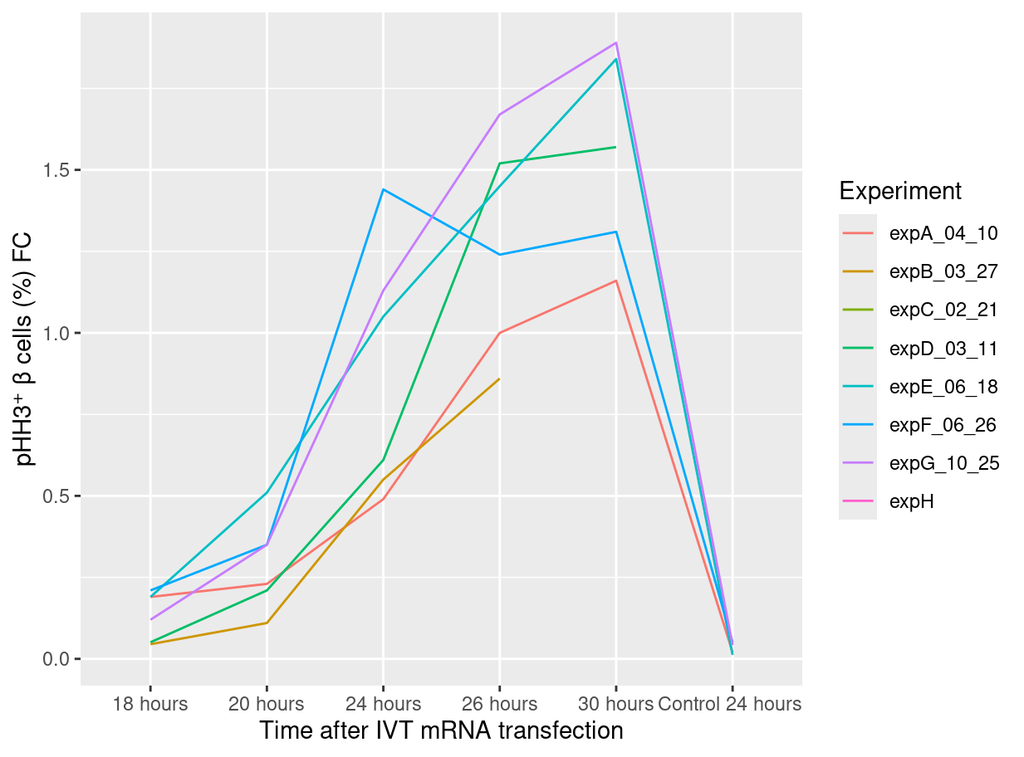

Mean proportion of pHH3⁺ β cells (% by flow cytometry) at different time points after IVT mRNA transfection and across individual experiments

```r
data_long %>% filter(grepl('pHH3_FC', Table)) %>%
  ggplot(
    aes(x = Time, y = Proportion, group = Experiment, color = Experiment)
    ) +
  geom_line() +
  scale_y_continuous(
    name = "pHH3⁺ β cells (%) FC"
  ) +
  scale_x_discrete(name = "Time after IVT mRNA transfection")
## Warning: Removed 13 rows containing missing values or values outside the scale range
## (`geom_line()`).
```

$\Rightarrow$ Variances appeared to differ substantially between groups, with a clear trend of increasing variance with the group mean, suggesting heteroscedasticity.

## 13.2 Models

### 13.2.1 Choose model

AIC/BIC

**Open code**

```r
model_NR <- glmmTMB::glmmTMB(
  Proportion ~ Time,
  data = data_long %>%
    filter(
      grepl('pHH3_FC', Table),
      !is.na(Proportion)
    ) %>%
    mutate(Time = factor(Time)),
  REML = FALSE
)

model_RI <- glmmTMB::glmmTMB(
  Proportion ~ Time + (1 | Experiment),
  data = data_long %>%
    filter(
      grepl('pHH3_FC', Table),
      !is.na(Proportion)
    ) %>%
    mutate(Time = factor(Time)),
  REML = FALSE
)

model_NR_difvar <- glmmTMB::glmmTMB(
  Proportion ~ Time,
  data = data_long %>%
    filter(
      grepl('pHH3_FC', Table),
      !is.na(Proportion)
    ) %>%
    mutate(Time = factor(Time)),
  REML = FALSE,
  dispformula = ~ Time,
)

model_RI_difvar <- glmmTMB::glmmTMB(
  Proportion ~ Time + (1 | Experiment),
  data = data_long %>%
    filter(
      grepl('pHH3_FC', Table),
      !is.na(Proportion)
    ) %>%
    mutate(Time = factor(Time)),
  REML = FALSE,
  dispformula = ~ 0 + Time
)

kableExtra::kable(AIC(model_NR, model_RI, model_NR_difvar, model_RI_difvar))
```

|  | df | AIC |
| --- | --- | --- |
| model_NR | 7 | 9.986014 |
| model_RI | 8 | 7.242268 |
| model_NR_difvar | 12 | -19.109637 |
| model_RI_difvar | 13 | -17.109637 |

**Open code**

```r
kableExtra::kable(BIC(model_NR, model_RI, model_NR_difvar, model_RI_difvar))
```

|  | df | BIC |
| --- | --- | --- |
| model_NR | 7 | 20.6705375 |
| model_RI | 8 | 19.4531521 |
| model_NR_difvar | 12 | -0.7933111 |
| model_RI_difvar | 13 | 2.7330495 |

Diagnostics

**Open code**

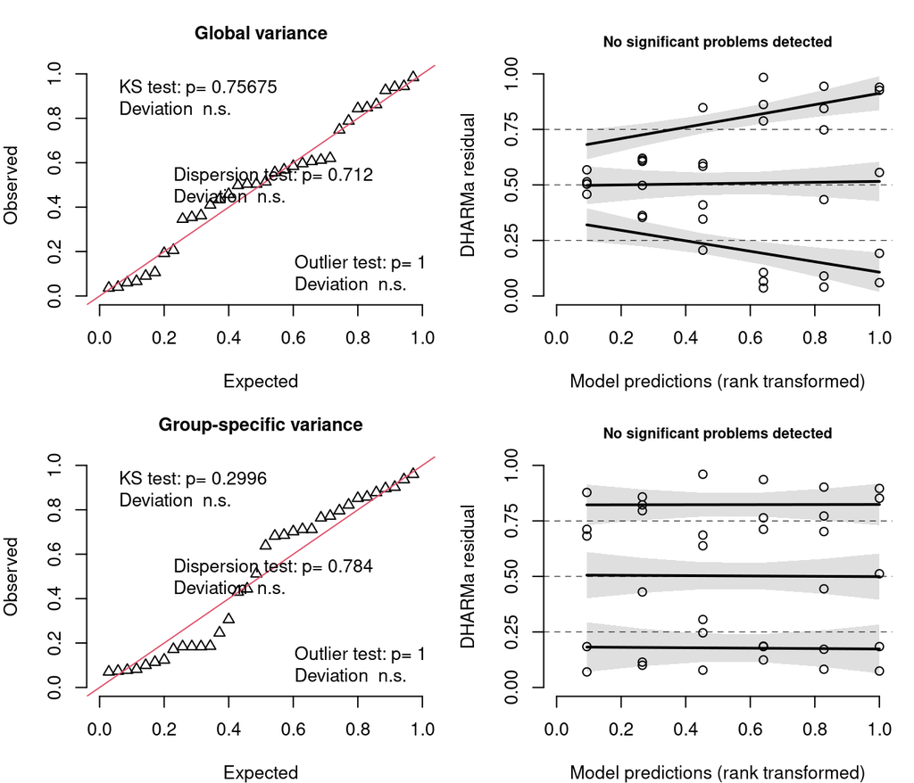

Diagnostic plots from DHARMa simulated residuals for models with and without group-specific residual variance. Top: random-intercept model with a single (global) residual variance. Bottom: random-intercept model allowing group-specific residual variance. Left: quantile–quantile plot comparing simulated residuals to the expected distribution. Right: residuals plotted against predicted values; black lines show the median (0.5) and lower/upper quartiles (0.25, 0.75) with shaded 95% simulation envelopes. Deviations from expected values suggest potential model misspecification

```r
set.seed(709)

res1 <- simulateResiduals(model_RI, n = 500)
res2 <- simulateResiduals(model_RI_difvar, n = 500)

op <- par(mfrow = c(2, 2), mar = c(4, 4, 3, 1))

plotQQunif(res1, main = "Global variance")
plotResiduals(res1, main = "")

plotQQunif(res2, main = "Group-specific variance")
plotResiduals(res2, main = "")
```

**Open code**

```r
par(op)
```

$\Rightarrow$ AIC and BIC indicated that allowing for group-specific residual variance improved model fit. Although diagnostic plots did not reveal major violations of distributional assumptions under a common variance, the data showed a clear trend of increasing variance with the group mean. Therefore, the random-intercept model with group-specific residual variance was used.

Because this is a borderline situation, results of alternative model (with a constant residual variance) is shown bewlo as well

### 13.2.2 Fit final model

**Open code**

```r
model_final <- glmmTMB::glmmTMB(
  Proportion ~ Time + (1 | Experiment),
  data = data_long %>%
    filter(
      grepl('pHH3_FC', Table),
      !is.na(Proportion)
    ) %>%
    mutate(Time = factor(Time)),
  REML = TRUE,
  dispformula = ~ 0 + Time
)
```

### 13.2.3 Results

**Open code**

```r
kableExtra::kable(car::Anova(model_final))
```

|  | Chisq | Df | Pr(>Chisq) |
| --- | --- | --- | --- |
| Time | 263.341 | 5 | 0 |

**Open code**

```r
summary(model_final)
##  Family: gaussian  ( identity )
## Formula:          Proportion ~ Time + (1 | Experiment)
## Dispersion:                  ~0 + Time
## Data: data_long %>% filter(grepl("pHH3_FC", Table), !is.na(Proportion)) %>%
##     mutate(Time = factor(Time))
##
##      AIC      BIC   logLik deviance df.resid
##      6.8     26.6      9.6    -19.2       27
##
## Random effects:
##
## Conditional model:
##  Groups     Name        Variance  Std.Dev.
##  Experiment (Intercept) 1.188e-12 1.09e-06
##  Residual                      NA       NA
## Number of obs: 34, groups:  Experiment, 6
##
## Conditional model:
##                       Estimate Std. Error z value Pr(>|z|)
## (Intercept)            0.13433    0.03003   4.473 7.70e-06 ***
## Time20 hours           0.15900    0.06455   2.463  0.01376 *
## Time24 hours           0.74400    0.15978   4.656 3.22e-06 ***
## Time26 hours           1.15567    0.13184   8.766  < 2e-16 ***
## Time30 hours           1.41967    0.14625   9.707  < 2e-16 ***
## TimeControl 24 hours  -0.10153    0.03087  -3.289  0.00101 **
## ---
## Signif. codes:  0 '***' 0.001 '**' 0.01 '*' 0.05 '.' 0.1 ' ' 1
##
## Dispersion model:
##                       Estimate Std. Error z value Pr(>|z|)
## Time18 hours           -2.6097     0.3162  -8.253  < 2e-16 ***
## Time20 hours           -1.9665     0.3162  -6.218 5.02e-10 ***
## Time24 hours           -0.9560     0.3162  -3.023 0.002501 **
## Time26 hours           -1.1569     0.3162  -3.659 0.000254 ***
## Time30 hours           -1.1393     0.3536  -3.222 0.001271 **
## TimeControl 24 hours   -4.1328     0.3536 -11.689  < 2e-16 ***
## ---
## Signif. codes:  0 '***' 0.001 '**' 0.01 '*' 0.05 '.' 0.1 ' ' 1

contrast <- con_tab(model_final)

kableExtra::kable(
  contrast,
  caption = "Estimated pairwise differences in the proportion of pHH3⁺ β cells (%; flow cytometry), obtained from a linear mixed-effects model with experiment as a random intercept, time as a categorical predictor, and allowance for group-specific residual variance. Columns: `contrast` (time points compared), `estimate` (mean difference in %), `CI` (Bonferroni-adjusted 95% confidence interval [lower, upper]), `SE` (standard error), `df` (degrees of freedom), `t.ratio` (test statistic), `p.value` (Bonferroni-adjusted p-value), and `stars` (significance code)."
)
```

Estimated pairwise differences in the proportion of pHH3⁺ β cells (%; flow cytometry), obtained from a linear mixed-effects model with experiment as a random intercept, time as a categorical predictor, and allowance for group-specific residual variance. Columns: `contrast` (time points compared), `estimate` (mean difference in %), `CI` (Bonferroni-adjusted 95% confidence interval [lower, upper]), `SE` (standard error), `df` (degrees of freedom), `t.ratio` (test statistic), `p.value` (Bonferroni-adjusted p-value), and `stars` (significance code).

| contrast | estimate | CI | SE | df | t.ratio | p.value | stars |
| --- | --- | --- | --- | --- | --- | --- | --- |
| 18 hours - 20 hours | -0.16 | [-0.37, 0.05] | 0.06 | 27 | -2.46 | 0.3063998 | ns |
| 18 hours - 24 hours | -0.74 | [-1.26, -0.23] | 0.16 | 27 | -4.66 | 0.0011508 | ** |
| 18 hours - 26 hours | -1.16 | [-1.58, -0.73] | 0.13 | 27 | -8.77 | 0.0000000 | *** |
| 18 hours - 30 hours | -1.42 | [-1.89, -0.95] | 0.15 | 27 | -9.71 | 0.0000000 | *** |
| 18 hours - Control 24 hours | 0.10 | [0.00, 0.20] | 0.03 | 27 | 3.29 | 0.0420025 | * |
| 20 hours - 24 hours | -0.58 | [-1.12, -0.05] | 0.17 | 27 | -3.50 | 0.0243336 | * |
| 20 hours - 26 hours | -1.00 | [-1.45, -0.54] | 0.14 | 27 | -7.09 | 0.0000019 | *** |
| 20 hours - 30 hours | -1.26 | [-1.76, -0.76] | 0.15 | 27 | -8.18 | 0.0000001 | *** |
| 20 hours - Control 24 hours | 0.26 | [0.08, 0.45] | 0.06 | 27 | 4.52 | 0.0016394 | ** |
| 24 hours - 26 hours | -0.41 | [-1.06, 0.24] | 0.20 | 27 | -2.03 | 0.7841383 | ns |
| 24 hours - 30 hours | -0.68 | [-1.36, 0.01] | 0.21 | 27 | -3.18 | 0.0550436 | ns |
| 24 hours - Control 24 hours | 0.85 | [0.34, 1.35] | 0.16 | 27 | 5.38 | 0.0001639 | *** |
| 26 hours - 30 hours | -0.26 | [-0.88, 0.35] | 0.19 | 27 | -1.37 | 1.0000000 | ns |
| 26 hours - Control 24 hours | 1.26 | [0.84, 1.67] | 0.13 | 27 | 9.78 | 0.0000000 | *** |
| 30 hours - Control 24 hours | 1.52 | [1.06, 1.98] | 0.14 | 27 | 10.61 | 0.0000000 | *** |

#### 13.2.3.1 Alternative model - constant residual variance

(click on ‘Open Code’ to see results)

**Open code**

```r
con_tab(model_RI)
## # A tibble: 15 × 8
##    contrast                    estimate CI       SE    df t.ratio  p.value stars
##    <chr>                          <dbl> <chr> <dbl> <dbl>   <dbl>    <dbl> <chr>
##  1 "18 hours - 20 hours"          -0.16 [-0.…  0.11    26   -1.44 1   e+ 0 ns
##  2 "18 hours - 24 hours"          -0.74 [-1.…  0.11    26   -6.76 5.42e- 6 ***
##  3 "18 hours - 26 hours"          -1.16 [-1.…  0.11    26  -10.5  1.16e- 9 ***
##  4 "18 hours - 30 hours"          -1.39 [-1.…  0.12    26  -12.0  6.93e-11 ***
##  5 "18 hours - Control 24 hou…     0.11 [-0.…  0.12    26    0.91 1   e+ 0 ns
##  6 "20 hours - 24 hours"          -0.59 [-0.…  0.11    26   -5.31 2.22e- 4 ***
##  7 "20 hours - 26 hours"          -1    [-1.…  0.11    26   -9.05 2.44e- 8 ***
##  8 "20 hours - 30 hours"          -1.23 [-1.…  0.12    26  -10.6  9.66e-10 ***
##  9 "20 hours - Control 24 hou…     0.26 [-0.…  0.12    26    2.28 4.66e- 1 ns
## 10 "24 hours - 26 hours"          -0.41 [-0.…  0.11    26   -3.74 1.38e- 2 *
## 11 "24 hours - 30 hours"          -0.65 [-1.…  0.12    26   -5.56 1.16e- 4 ***
## 12 "24 hours - Control 24 hou…     0.85 [0.4…  0.12    26    7.31 1.37e- 6 ***
## 13 "26 hours - 30 hours"          -0.24 [-0.…  0.12    26   -2.03 7.96e- 1 ns
## 14 "26 hours - Control 24 hou…     1.26 [0.8…  0.12    26   10.8  5.62e-10 ***
## 15 "30 hours - Control 24 hou…     1.5  [1.1…  0.12    26   12.2  4.17e-11 ***
```

### 13.2.4 Visualisation

**Open code**

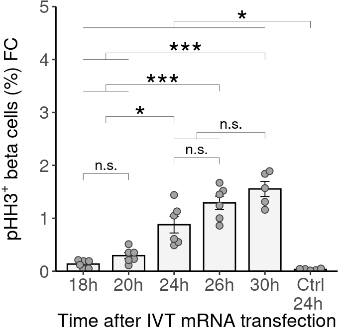

```r
scale <- 20

p <- data_long %>%
  filter(
      grepl('pHH3_FC', Table),
      !is.na(Proportion)
    ) %>%
  mutate(
    Time = factor(Time,
                  levels = unique(Time),
                  labels = gsub(" hour[s]?", "h", gsub("Control", "Ctrl", unique(Time)))
                  )
    ) %>%
  ggplot(
    aes(x = Time, y = Proportion)
  ) +
  stat_summary(
    fun = 'mean',
    geom = 'col',
    fill = 'grey80', color = 'black',
    width = 0.7,
    alpha = 0.2
  ) +
  stat_summary(fun.data = mean_se, geom = "errorbar", width = 0.2, linewidth = 0.324) +
  scale_y_continuous(
    breaks = seq(0, 100/scale, 20/scale),
    name = expression("pHH3"^"+"~"beta cells (%) FC"),
    expand = expansion(mult = c(0, 0), add = c(0, 0))
  ) +
  coord_cartesian(ylim = c(0, 100/scale)) +
  scale_x_discrete(name = "Time after IVT mRNA transfection",
    labels = function(x) gsub("Ctrl (.*)", "Ctrl\n\\1", x)) +
  geom_beeswarm(
    cex = 2,
    fill = 'grey64',
    size = 2.13,
    shape = 21,
    color = rgb(0.2, 0.2, 0.2, 0.9),
    stroke = 0.5
  ) +
  theme_classic() +
  theme(
    plot.margin = margin(t = 5, r = 1, b = 1, l = 1),
    axis.text.x = element_text(size = ax_text1),
    axis.text.y = element_text(size = ax_text1),
    axis.title.x = element_text(size = tit_text1, margin = margin(t = mar1)),
    axis.title.y = element_text(size = tit_text1, margin = margin(r = mar1c))
  )

start <- 96/scale
tr <- 0
byp <- 12/scale

p <- add_starm(6, c(1:5), start - tr, '*', scal = scale); tr <-  tr + byp
p <- add_starm(5, c(1:2), start - tr, '***', scal = scale); tr <-  tr + byp
p <- add_starm(4, c(1:2), start - tr, '***', scal = scale); tr <-  tr + byp
p <- add_starm(3, c(1:2), start - tr, '*', scal = scale); tr <-  tr + byp*0.5
p <- add_starm(5, c(3:4), start - tr, '<sup>n.s.</sup>', scal = scale); tr <-  tr + byp*0.8
p <- add_starm(4, 3, start - tr, '<sup>n.s.</sup>', scal = scale); tr <-  tr + byp*0.5
p <- add_starm(1, 2, start - tr, '<sup>n.s.</sup>', scal = scale)

p
```

**Open code**

```r
if (!file.exists("gitignore/figures/fig_11.pdf")) {
  ggsave("gitignore/figures/fig_11.pdf", plot = p, width = figw1, height = figh1, units = "in")
  ggsave("gitignore/figures/fig_11.svg", plot = p, width = figw1, height = figh1, units = "in")
  }
```

### 13.2.5 Summary statistics over timpoints

**Open code**

```r
kableExtra::kable(
  data_long %>%
    dplyr::filter(grepl("pHH3_FC", Table)) %>%
    tidyr::drop_na(Proportion) %>%
    dplyr::group_by(Time) %>%
    dplyr::summarise(
      mean = mean(Proportion),
      median = quantile(Proportion, probs = 0.5),
      SD = sd(Proportion),
      SEM = sem(Proportion)
    ),
  caption = "Summary statistics for the proportion of pHH3⁺ beta cells (% by flow cytometry) at different time points after IVT mRNA transfection. Mean, median, SD, and SEM are shown; SD, standard deviation; SEM, standard error of the mean"
)
```

Summary statistics for the proportion of pHH3⁺ beta cells (% by flow cytometry) at different time points after IVT mRNA transfection. Mean, median, SD, and SEM are shown; SD, standard deviation; SEM, standard error of the mean

| Time | mean | median | SD | SEM |
| --- | --- | --- | --- | --- |
| 18 hours | 0.1343333 | 0.155 | 0.0735572 | 0.0300296 |
| 20 hours | 0.2933333 | 0.290 | 0.1399524 | 0.0571353 |
| 24 hours | 0.8783333 | 0.830 | 0.3844173 | 0.1569377 |
| 26 hours | 1.2900000 | 1.345 | 0.3144519 | 0.1283745 |
| 30 hours | 1.5540000 | 1.570 | 0.3200469 | 0.1431293 |
| Control 24 hours | 0.0328000 | 0.040 | 0.0160375 | 0.0071722 |

# 14 Divided FC

## 14.1 Show Data

**Open code**

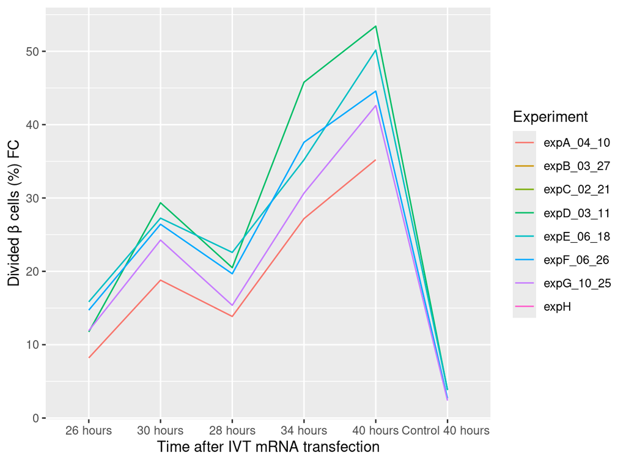

Mean proportion of divided β cells (% by flow cytometry) at different time points after IVT mRNA transfection and across individual experiments

```r
data_long %>% filter(grepl('divided_cells_FC', Table)) %>%
  ggplot(
    aes(x = Time, y = Proportion, group = Experiment, color = Experiment)
    ) +
  geom_line() +
  scale_y_continuous(
    name = "Divided β cells (%) FC"
  ) +
  scale_x_discrete(name = "Time after IVT mRNA transfection")
## Warning: Removed 17 rows containing missing values or values outside the scale range
## (`geom_line()`).
```

$\Rightarrow$ Variances may slightly increase for later times

## 14.2 Models

### 14.2.1 Choose model

AIC/BIC

**Open code**

```r
model_NR <- glmmTMB::glmmTMB(
  Proportion ~ Time,
  data = data_long %>%
    filter(
      grepl('divided_cells_FC', Table),
      !is.na(Proportion)
    ) %>%
    mutate(Time = factor(Time)),
  REML = FALSE
)

model_RI <- glmmTMB::glmmTMB(
  Proportion ~ Time + (1 | Experiment),
  data = data_long %>%
    filter(
      grepl('divided_cells_FC', Table),
      !is.na(Proportion)
    ) %>%
    mutate(Time = factor(Time)),
  REML = FALSE
)

model_NR_difvar <- glmmTMB::glmmTMB(
  Proportion ~ Time,
  data = data_long %>%
    filter(
      grepl('divided_cells_FC', Table),
      !is.na(Proportion)
    ) %>%
    mutate(Time = factor(Time)),
  REML = FALSE,
  dispformula = ~ Time,
)

model_RI_difvar <- glmmTMB::glmmTMB(
  Proportion ~ Time + (1 | Experiment),
  data = data_long %>%
    filter(
      grepl('divided_cells_FC', Table),
      !is.na(Proportion)
    ) %>%
    mutate(Time = factor(Time)),
  REML = FALSE,
  dispformula = ~ 0 + Time
)

kableExtra::kable(AIC(model_NR, model_RI, model_NR_difvar, model_RI_difvar))
```

|  | df | AIC |
| --- | --- | --- |
| model_NR | 7 | 193.8975 |
| model_RI | 8 | 176.9452 |
| model_NR_difvar | 12 | 187.2113 |
| model_RI_difvar | 13 | 173.7673 |

**Open code**

```r
kableExtra::kable(BIC(model_NR, model_RI, model_NR_difvar, model_RI_difvar))
```

|  | df | BIC |
| --- | --- | --- |
| model_NR | 7 | 203.9354 |
| model_RI | 8 | 188.4171 |
| model_NR_difvar | 12 | 204.4191 |
| model_RI_difvar | 13 | 192.4091 |

Diagnostics

**Open code**

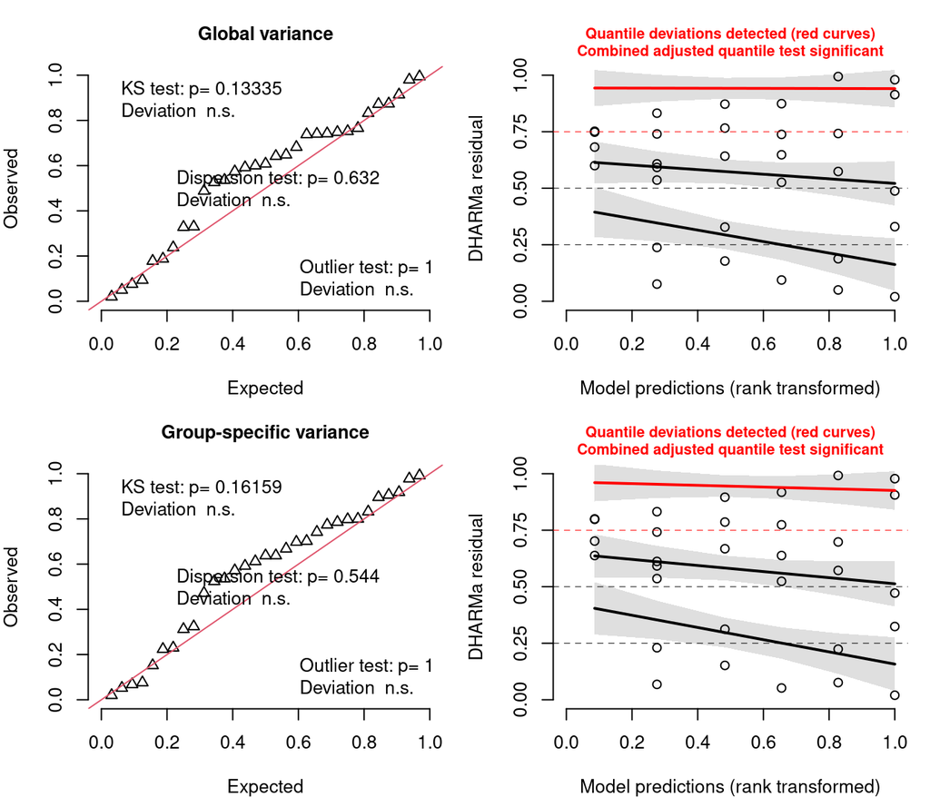

Diagnostic plots from DHARMa simulated residuals for models with and without group-specific residual variance. Top: random-intercept model with a single (global) residual variance. Bottom: random-intercept model allowing group-specific residual variance. Left: quantile–quantile plot comparing simulated residuals to the expected distribution. Right: residuals plotted against predicted values; black lines show the median (0.5) and lower/upper quartiles (0.25, 0.75) with shaded 95% simulation envelopes. Deviations from expected values suggest potential model misspecification

```r
set.seed(709)

res1 <- simulateResiduals(model_RI, n = 500)
res2 <- simulateResiduals(model_RI_difvar, n = 500)

op <- par(mfrow = c(2, 2), mar = c(4, 4, 3, 1))

plotQQunif(res1, main = "Global variance")
plotResiduals(res1, main = "")

plotQQunif(res2, main = "Group-specific variance")
plotResiduals(res2, main = "")
```

**Open code**

```r
par(op)
```

$\Rightarrow$ Group-specific residual variance will not markedly improve AIC/BIC or model diagnostics – default (random-intercept) model will be used. Both the QQ-plot and the residuals vs. fitted plot indicate some heteroscedasticity, but it does not seem serious.

### 14.2.2 Fit final model

**Open code**

```r
model_final <- glmmTMB::glmmTMB(
  Proportion ~ Time + (1 | Experiment),
  data = data_long %>%
    filter(
      grepl('divided_cells_FC', Table),
      !is.na(Proportion)
    ) %>%
    mutate(Time = factor(Time)),
  REML = TRUE
)
```

### 14.2.3 Results

**Open code**

```r
kableExtra::kable(car::Anova(model_final))
```

|  | Chisq | Df | Pr(>Chisq) |
| --- | --- | --- | --- |
| Time | 716.6349 | 5 | 0 |

**Open code**

```r
summary(model_final)
##  Family: gaussian  ( identity )
## Formula:          Proportion ~ Time + (1 | Experiment)
## Data:
## data_long %>% filter(grepl("divided_cells_FC", Table), !is.na(Proportion)) %>%
##     mutate(Time = factor(Time))
##
##      AIC      BIC   logLik deviance df.resid
##    161.3    172.7    -72.6    145.3       29
##
## Random effects:
##
## Conditional model:
##  Groups     Name        Variance Std.Dev.
##  Experiment (Intercept) 16.788   4.097
##  Residual                8.015   2.831
## Number of obs: 31, groups:  Experiment, 7
##
## Dispersion estimate for gaussian family (sigma^2): 8.01
##
## Conditional model:
##                       Estimate Std. Error z value Pr(>|z|)
## (Intercept)             11.469      1.882   6.093 1.11e-09 ***
## Time30 hours            13.063      1.757   7.434 1.05e-13 ***
## Time28 hours             6.241      1.757   3.552 0.000383 ***
## Time34 hours            23.137      1.757  13.168  < 2e-16 ***
## Time40 hours            33.045      1.757  18.807  < 2e-16 ***
## TimeControl 40 hours   -10.496      1.899  -5.527 3.26e-08 ***
## ---
## Signif. codes:  0 '***' 0.001 '**' 0.01 '*' 0.05 '.' 0.1 ' ' 1

contrast <- con_tab(model_final)

kableExtra::kable(
  contrast,
  caption = "Estimated pairwise differences in the proportion of divided β cells (%; flow cytometry), obtained from a linear mixed-effects model with experiment as a random intercept and time as a categorical predictor. Columns: `contrast` (time points compared), `estimate` (mean difference in %), `CI` (Bonferroni-adjusted 95% confidence interval [lower, upper]), `SE` (standard error), `df` (degrees of freedom), `t.ratio` (test statistic), `p.value` (Bonferroni-adjusted p-value), and `stars` (significance code)."
)
```

Estimated pairwise differences in the proportion of divided β cells (%; flow cytometry), obtained from a linear mixed-effects model with experiment as a random intercept and time as a categorical predictor. Columns: `contrast` (time points compared), `estimate` (mean difference in %), `CI` (Bonferroni-adjusted 95% confidence interval [lower, upper]), `SE` (standard error), `df` (degrees of freedom), `t.ratio` (test statistic), `p.value` (Bonferroni-adjusted p-value), and `stars` (significance code).

| contrast | estimate | CI | SE | df | t.ratio | p.value | stars |
| --- | --- | --- | --- | --- | --- | --- | --- |
| 26 hours - 30 hours | -13.06 | [-18.68, -7.44] | 1.76 | 29 | -7.43 | 0.0000005 | *** |
| 26 hours - 28 hours | -6.24 | [-11.86, -0.62] | 1.76 | 29 | -3.55 | 0.0199479 | * |
| 26 hours - 34 hours | -23.14 | [-28.76, -17.52] | 1.76 | 29 | -13.17 | 0.0000000 | *** |
| 26 hours - 40 hours | -33.04 | [-38.66, -27.43] | 1.76 | 29 | -18.81 | 0.0000000 | *** |
| 26 hours - Control 40 hours | 10.50 | [4.42, 16.57] | 1.90 | 29 | 5.53 | 0.0000881 | *** |
| 30 hours - 28 hours | 6.82 | [1.10, 12.55] | 1.79 | 29 | 3.81 | 0.0100239 | * |
| 30 hours - 34 hours | -10.07 | [-15.80, -4.35] | 1.79 | 29 | -5.63 | 0.0000669 | *** |
| 30 hours - 40 hours | -19.98 | [-25.71, -14.26] | 1.79 | 29 | -11.16 | 0.0000000 | *** |
| 30 hours - Control 40 hours | 23.56 | [17.42, 29.70] | 1.92 | 29 | 12.26 | 0.0000000 | *** |
| 28 hours - 34 hours | -16.90 | [-22.62, -11.17] | 1.79 | 29 | -9.44 | 0.0000000 | *** |
| 28 hours - 40 hours | -26.80 | [-32.53, -21.08] | 1.79 | 29 | -14.97 | 0.0000000 | *** |
| 28 hours - Control 40 hours | 16.74 | [10.59, 22.88] | 1.92 | 29 | 8.71 | 0.0000000 | *** |
| 34 hours - 40 hours | -9.91 | [-15.63, -4.18] | 1.79 | 29 | -5.53 | 0.0000865 | *** |
| 34 hours - Control 40 hours | 33.63 | [27.49, 39.78] | 1.92 | 29 | 17.51 | 0.0000000 | *** |
| 40 hours - Control 40 hours | 43.54 | [37.40, 49.69] | 1.92 | 29 | 22.67 | 0.0000000 | *** |

### 14.2.4 Visualisation

**Open code**

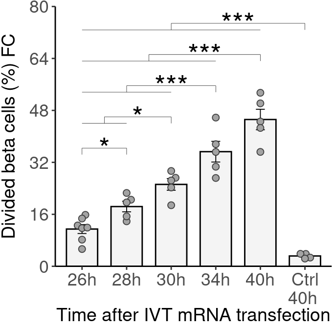

Proportion of divided beta cells (% by flow cytometry) at different time points after IVT mRNA transfection. Bars show means ± SEM. Statistical significance was assessed using a linear mixed-effects model with experiment as a random effect and time as a categorical predictor

```r
scale <- 1.25

p <- data_long %>%
  filter(
    grepl('divided_cells_FC', Table),
    !is.na(Proportion)
  ) %>%
  mutate(
    Time = gsub(" hour[s]?", "h", gsub("Control", "Ctrl", Time))
  ) %>%
  mutate(
    Time = factor(
      Time,
      levels = c(sort(unique(Time[Time != "Ctrl 40h"])), "Ctrl 40h")
    )
  ) %>%
  ggplot(
    aes(x = Time, y = Proportion)
  ) +
  stat_summary(
    fun = 'mean',
    geom = 'col',
    fill = 'grey80', color = 'black',
    width = 0.7,
    alpha = 0.2
  ) +
  stat_summary(fun.data = mean_se, geom = "errorbar", width = 0.2, linewidth = 0.324) +
  scale_y_continuous(
    breaks = seq(0, 100/scale, 20/scale),
    name = "Divided beta cells (%) FC",
    expand = expansion(mult = c(0, 0), add = c(0, 0))
  ) +
  coord_cartesian(ylim = c(0, 100/scale)) +
  scale_x_discrete(name = "Time after IVT mRNA transfection",
    labels = function(x) gsub("Ctrl (.*)", "Ctrl\n\\1", x)) +
  geom_beeswarm(
    cex = 2,
    fill = 'grey64',
    size = 2.13,
    shape = 21,
    color = rgb(0.2, 0.2, 0.2, 0.9),
    stroke = 0.5
  ) +
  theme_classic() +
  theme(
    plot.margin = margin(t = 5, r = 1, b = 1, l = 1),
    axis.text.x = element_text(size = ax_text1),
    axis.text.y = element_text(size = ax_text1),
    axis.title.x = element_text(size = tit_text1, margin = margin(t = mar1)),
    axis.title.y = element_text(size = tit_text1, margin = margin(r = 8))
  )

tr <- 0
byp <- 12/scale
start <- 95/scale

p <- add_starm(6, c(1:5), start - tr, '***', scal = scale); tr <-  tr + byp
p <- add_starm(5, c(1:4), start - tr, '***', scal = scale); tr <-  tr + byp
p <- add_starm(4, c(1:3), start - tr, '***', scal = scale); tr <-  tr + byp
p <- add_starm(3, c(1:2), start - tr, '*', scal = scale); tr <-  tr + byp
p <- add_starm(1, 2, start - tr, '*', scal = scale); tr <-  tr + byp

p
```

**Open code**

```r
if (!file.exists("gitignore/figures/fig_12.pdf")) {
  ggsave("gitignore/figures/fig_12.pdf", plot = p, width = figw1, height = figh1, units = "in")
  ggsave("gitignore/figures/fig_12.svg", plot = p, width = figw1, height = figh1, units = "in")
  }
```

### 14.2.5 Summary statistics over timpoints

**Open code**

```r
kableExtra::kable(
  data_long %>%
    dplyr::filter(grepl("divided_cells_FC", Table)) %>%
    tidyr::drop_na(Proportion) %>%
    dplyr::group_by(Time) %>%
    dplyr::summarise(
      mean = mean(Proportion),
      median = quantile(Proportion, probs = 0.5),
      SD = sd(Proportion),
      SEM = sem(Proportion)
    ),
  caption = "Summary statistics for the proportion of divided beta cells (% by flow cytometry) at different time points after IVT mRNA transfection. Mean, median, SD, and SEM are shown; SD, standard deviation; SEM, standard error of the mean"
)
```

Summary statistics for the proportion of divided beta cells (% by flow cytometry) at different time points after IVT mRNA transfection. Mean, median, SD, and SEM are shown; SD, standard deviation; SEM, standard error of the mean

| Time | mean | median | SD | SEM |
| --- | --- | --- | --- | --- |
| 26 hours | 11.46857 | 11.910 | 3.6448476 | 1.3776229 |
| 30 hours | 25.21600 | 26.420 | 4.0235469 | 1.7993849 |
| 28 hours | 18.39400 | 19.670 | 3.6530302 | 1.6336848 |
| 34 hours | 35.29000 | 35.210 | 7.1175733 | 3.1830756 |
| 40 hours | 45.19800 | 44.570 | 7.0567535 | 3.1558761 |
| Control 40 hours | 3.17750 | 3.245 | 0.7577324 | 0.3788662 |

# 15 EdU⁺ Cell cycle occupation by FC (divided)

## 15.1 Create relavant datasets

**Open code**

```r
## to get means
data_occup <- data_long %>%
  mutate(
    Time = gsub(" hour[s]?", "h", gsub("Control", "Ctrl", Time))
  ) %>%
  mutate(
    Time = gsub(" hour[s]?", "h", gsub("Control", "Ctrl", Time))
  ) %>%
  filter(
    grepl('Cell_cycle_occupation3', Table)
  ) %>%
  tidyr::drop_na(Proportion) %>%
  rename(
    Population = `Name.of.population`
  ) %>%
  dplyr::select(Time, Population, Proportion) %>%
  pivot_wider(
    names_from = Population,
    values_from = Proportion,
    values_fn = mean
  ) %>%
  mutate(Other = 100 - `S EdU+` - `G0G1 EdU-` -  `G2M EdU+` - `Divided`)

data_occup
## # A tibble: 6 × 6
##   Time        Divided `G0G1 EdU-` `S EdU+` `G2M EdU+`  Other
##   <chr>         <dbl>       <dbl>    <dbl>      <dbl>  <dbl>
## 1 "26h"         11.5         42.9    18.8      25.6   1.20
## 2 "28h"         18.4         39.9    13.9      26.2   1.67
## 3 "30h"         25.2         36.0    11.4      25.2   2.23
## 4 "34h"         35.3         33.9     5.88     20.9   3.98
## 5 "40h"         45.2         27.6     4.71     17.1   5.38
## 6 "Ctrl 40h "    3.18        95.6     0.6       0.605 0.0225

## to get SEM
sem_df <- data_long %>%
  mutate(
    Time = gsub(" hour[s]?", "h", gsub("Control", "Ctrl", Time))
  ) %>%
  mutate(
    Time = gsub(" hour[s]?", "h", gsub("Control", "Ctrl", Time))
  ) %>%
  filter(
    grepl('Cell_cycle_occupation3', Table)
  ) %>%
  tidyr::drop_na(Proportion) %>%
  rename(Population = `Name.of.population`) %>%
  group_by(Time, Population) %>%
  summarise(sem = sd(Proportion)/sqrt(n()), .groups = "drop") %>%
  left_join(data_occup, by = "Time") %>%
  dplyr::mutate(
    xmid = case_when(
      Population == "G0G1 EdU-" ~ `G0G1 EdU-`,
      Population == "S EdU+" ~ `G0G1 EdU-` + `S EdU+`,
      Population == "G2M EdU+" ~ `G0G1 EdU-` + `S EdU+` + `G2M EdU+`,
      Population == "Divided" ~ `G0G1 EdU-` + `S EdU+` + `G2M EdU+` + `Divided`,
  )
)

kableExtra::kable(sem_df %>% select(Time, Population, sem))
```

| Time | Population | sem |
| --- | --- | --- |
| 26h | Divided | 1.3776229 |
| 26h | G0G1 EdU- | 3.1362481 |
| 26h | G2M EdU+ | 1.7195000 |
| 26h | S EdU+ | 2.5725406 |
| 28h | Divided | 1.6336848 |
| 28h | G0G1 EdU- | 2.7407262 |
| 28h | G2M EdU+ | 1.3392483 |
| 28h | S EdU+ | 0.8765124 |
| 30h | Divided | 1.7993849 |
| 30h | G0G1 EdU- | 2.9418311 |
| 30h | G2M EdU+ | 1.0716324 |
| 30h | S EdU+ | 0.9174770 |
| 34h | Divided | 3.1830756 |
| 34h | G0G1 EdU- | 5.0796874 |
| 34h | G2M EdU+ | 2.2352083 |
| 34h | S EdU+ | 0.9338715 |
| 40h | Divided | 3.1558761 |
| 40h | G0G1 EdU- | 5.2822505 |
| 40h | G2M EdU+ | 2.7653293 |
| 40h | S EdU+ | 0.6614333 |
| Ctrl 40h | Divided | 0.3788662 |
| Ctrl 40h | G0G1 EdU- | 0.2419539 |
| Ctrl 40h | G2M EdU+ | 0.1005402 |
| Ctrl 40h | S EdU+ | 0.2395134 |

## 15.2 Plot

**Open code**

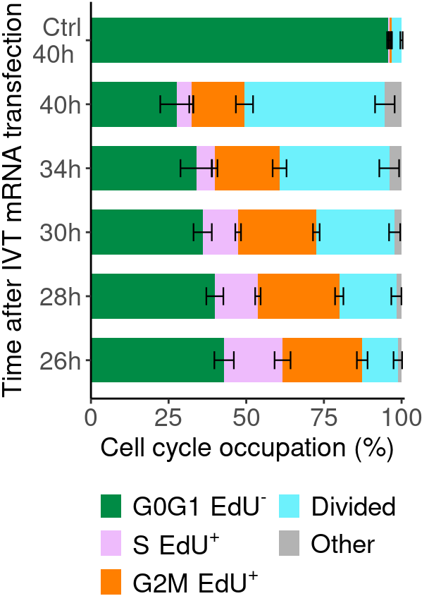

Proportion of beta cells in G0G1 EdU⁻, S EdU⁺, G2M EdU⁺, and Divided phases (% by flow cytometry) at different time points after IVT mRNA transfection. Bars show means ± SEM (for individual phases; “Other” calculated as 100% − G0G1 EdU⁻ − S EdU⁺ − G2M EdU⁺ − Divided)

```r
p <- data_occup %>%
  tidyr::pivot_longer(
    cols = c(`G0G1 EdU-`, `S EdU+`, `G2M EdU+`, `Divided`, Other),
    names_to = 'Phase',
    values_to = 'Percent'
  ) %>%
  dplyr::mutate(
    Phase = factor(
      Phase,
      levels = c('Other', 'Divided', 'G2M EdU+', 'S EdU+', 'G0G1 EdU-')
    )
  ) %>%
  ggplot(
    aes(
      y = Time,
      x = Percent,
      fill = Phase
    )
  ) +
  geom_col(width = 0.7) +
  scale_fill_manual(
    values = c(
      'G0G1 EdU-' = 'springgreen4',
      'S EdU+' = '#EEBBFC',
      'G2M EdU+' = 'darkorange1',
      'Divided' = '#6DF1FC',
      'Other' = 'grey70'
    ),
    breaks = c('G0G1 EdU-', 'S EdU+', 'G2M EdU+', 'Divided', 'Other'),
    labels = c(
    expression(G0G1~EdU^"-"),
    expression(S~EdU^"+"),
    expression(G2M~EdU^"+"),
    "Divided",
    "Other"
  ), name = NULL
  ) +
  labs(
    x = 'Cell cycle occupation (%)',
    y = 'Time after IVT mRNA transfection'
  ) +
  scale_x_continuous(
    limits = c(0, 101),
    expand = expansion(mult = c(0, 0), add = c(0, 0))
  ) +
  scale_y_discrete(
  labels = function(x) gsub(
    "(Ctrl|\\+RO|-RO)\\s*", "\\1\n", x
    )
  ) +
  theme_classic() +
  theme(
    axis.line.y = element_line(color = 'black'),
    axis.line.x = element_line(color = 'black'),
    legend.position = 'bottom',
    plot.margin = margin(t = 1, r = 13, b = 1, l = 1),
    axis.text.x = element_text(size = ax_text4),
    axis.text.y = element_text(size = ax_text4),
    axis.title.x = element_text(size = tit_text4),
    axis.title.y = element_text(size = tit_text4),
    legend.text = element_text(size = leg_text4),
    legend.key.size = unit(0.85, "lines")
  ) +
  guides(
    fill = guide_legend(nrow = 3)
  ) +
  geom_errorbarh(
    data = sem_df,
    aes(
      y = Time,
      xmin = xmid - sem,
      xmax = xmid + sem
    ),
    height = 0.28,
    inherit.aes = FALSE,
    linewidth = 0.4,
    color = 'black'
  ) +
  scale_color_manual(
    guide = 'none'
  )

p
```

**Open code**

```r
if (!file.exists("gitignore/figures/fig_13.pdf")) {
  ggsave("gitignore/figures/fig_13.pdf", plot = p, width = figw2, height = figh2, units = "in")
  ggsave("gitignore/figures/fig_13.svg", plot = p, width = figw2, height = figh2, units = "in")
  }
```

# 16 G0G1 phase FC

## 16.1 Show Data

**Open code**

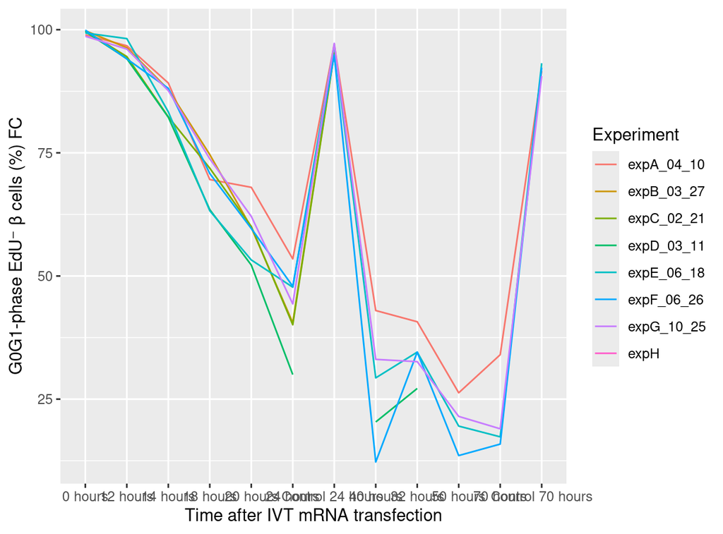

Mean proportion of G0G1-phase EdU⁻ β cells (% by flow cytometry) at different time points after IVT mRNA transfection and across individual experiments

```r
data_long %>% filter(grepl('G0G1_CYCLE_FC', Table)) %>%
  ggplot(
    aes(x = Time, y = Proportion, group = Experiment, color = Experiment)
    ) +
  geom_line() +
  scale_y_continuous(
    name = "G0G1-phase EdU⁻ β cells (%) FC"
  ) +
  scale_x_discrete(name = "Time after IVT mRNA transfection")
## Warning: Removed 25 rows containing missing values or values outside the scale range
## (`geom_line()`).
```

$\Rightarrow$ Variances sharply increases around 50% proportion. Clear Heteroscedasticity